# Pandas

## 目录

### 1. **Pandas 101**

### 2. **数据创建**

1. 序列 `Series`
2. 数据帧 `DataFrame`

### 3. **数据存载**

1. 文本 excel 格式
2. 文本 csv 格式

### 4. **数据获取**

1. 元素获取
2. 列状获取
3. 行状获取
4. 块状获取
5. 高级获取
6. 层级获取

### 5. **数据结合**

1. 按「键」合并
2. 按「轴」连接

### 6. **数据重塑**

1. 行列互转
2. 长宽互转

### 7. **数据分析**

1. 单维整体分析
2. 单维分组分析
3. 多维透视分析
4. 多维交叉分析

### 8. **数据可视**

1. 线状图
2. 散点图
3. 柱状图
4. 箱形图
5. 直方图
6. 饼状图

### 9. **数据处理**

1. 数据清洗
2. 数据转换

# 1. Pandas 101

回到目录

**Pandas** 是 **Pan**el **d**ata **a**nalysi**s** 的缩写，顾名思义它是 Python 里处理数据分析 (data analysis) 的工具包，其官网是 https://pandas.pydata.org/

在使用 pandas 之前，需要引进它，语法如下：

```python
import pandas
pandas.__version__
```

```
'1.0.4'
```

这样就可以用 Pandas 里面所有的内置方法 (build-in methods) 了，比如创建序列和数据帧 `pandas.Series()` 与均值 `pandas.DataFrame()`。

但这样每次写 Pandas 字数有点多，通常给 Pandas 起个别名 pd，语法如下：

```python
import pandas as pd
```

这样所有出现 Pandas 的地方都可以用 pd 替代，上面的序列和数据帧可写成 `pd.Series()` 和 `pd.DataFrame()`。

Pandas 里面的数据结构是「数据表」，学习它可以类比这 NumPy 里的「数组」：

[figure not shown]

对比 NumPy 和 Pandas 每个维度下的数据结构，不难看出

```
数据表 = 数组 + 描述
```

其中

```
一维数据表 = 一维数组 + 行索引
二维数据表 = 二维数组 + 行索引 + 列索引
三维数据表 = 三维数组 + 行索引 + 列索引 + 项索引
```

一维、二维和三维的「数据表」分别叫做系列 (Series)、数据帧 (DataFrame) 和面板 (Panel)，上面关系可写成

```
序列 = 一维数组 + 行索引
数据帧 = 二维数组 + 行索引 + 列索引
面板 = 三维数组 + 行索引 + 列索引 + 项索引
```

如果觉得中文直译太绕口，可保留原英文术语

```
Series = 1darray + index
DataFrame = 2darray + index + columns
Panel = 3darray + index + columns + item
```

面板在 Pandas 1.0 已经被废除了，因为它可以被多层索引的数据帧来表示，因此不研究面板了。

### 对比数据帧和 numpy 数组

下图左边的「二维数组」 仅仅储存了一组数值 (具体代表什么意思却不知道)，而右边的「数据帧」一看就知道这是平安银行和茅台从 2018-1-3 到 2019-1-3 的价格。

[figure not shown]

Pandas 的数据结构在每个维度上都有可读性强的**标签**，比起 NumPy 的数据结构涵盖了更多信息。

此外 Pandas 主要是为**异质** (heterogeneous) 的**表格** (tabular) 数据而设计的，而 NumPy 主要是为**同质** (homogeneous) 的**数值** (numerical) 数据而设计的，但结构性数组 (structured array) 除外。

大多情况 Pandas 通常是跟 NumPy 一起使用的，引入 `numpy` 起名为 `np`。

```python
import numpy as np
```

# 2. 数据创建

回到目录

数据表有两大类型，根据维度划分有一维的序列 (Series) 和二维的数据帧 (DataFrame)。**三维的面板 (Panel) 已经在 Pandas 1.0 被废除。**

- **Series**: 一维数据，类似于 python 中的基本数据的 list 或 NumPy 中的 1D array。Pandas 里最基本的数据结构。
- **DataFrame**: 二维数据，类似于 Excel 中的 sheet，R 中的 data.frame 或 Matlab 中的 Tables。DataFrame 是 Series 的容器。

### 2.1 序列 `Series`

回到章首

创建**序列**只需用下面一行代码

```
pd.Series( x, index=idx )
```

其中 x 可以是

- 列表 (`list`)
- numpy 数组 (`ndarray`)
- 字典 (`dict`)

函数 `Series()` 中有两个参数：

- `x` 是位置参数，称为数据值
- `index` 是默认参数，称为行标签
  - 如果不设定，行标签为 `idx = range(0, len(x))`
  - 如果设定，可以用整数 (integer)、字符串 (string) 和时间对象 (datetime)

### 用列表创建序列

```python
s = pd.Series([27.2, 27.65, 27.70, 28])
s
```

```
0    27.20
1    27.65
2    27.70
3    28.00
dtype: float64
```

打印出来并不仅仅是列表里面的浮点数，每个浮点数前面还有一个索引，在本例中是 0, 1, 2, 3。

因此在创建**序列**时，如果不显性设定 `index`，那么 Python 给定一个默认从 0 到 N-1 的值，其中 N 是 x 的长度。

**序列**`s` 也是一个对象，用 `dir(s)` 可看出关于**序列**所有的属性和内置函数，其中最重要的是

- 用 `s.values` 打印 `s` 中的元素
- 用 `s.index` 打印 `s` 中的元素对应的行标签

```python
s.values
```

```
array([27.2 , 27.65, 27.7 , 28.  ])
```

```python
s.index
```

```
RangeIndex(start=0, stop=4, step=1)
```

不难发现，以上创建的**序列** 比 `ndarray` 多了**行标签**，但这种 0,1,2,3 的行标签可读性不强。实际上定义的 s 是海底捞在 2019 年 4 月 1 日到 2019 年 4 月 4 日的股价，那么用日期来当行标签更好些。

```python
dates = pd.date_range('20190401',periods=4)
s2 = pd.Series( [27.2, 27.65, 27.70, 28], index=dates )
s2
```

```
2019-04-01    27.20
2019-04-02    27.65
2019-04-03    27.70
2019-04-04    28.00
Freq: D, dtype: float64
```

显然，`s2` 比 `s` 包含的信息更多，这是 `s2` 的行标签是一组日期对象，数据类型是 `datetime64`，频率是 D，即每日。

```python
s2.index
```

```
DatetimeIndex(['2019-04-01', '2019-04-02', '2019-04-03', '2019-04-04'], dtype='datetime64[ns]', freq='D')
```

此外还可以给 `s2` 命名，比如**海底捞股价**。

```python
s2.name = '海底捞股价'
s2
```

```
2019-04-01    27.20
2019-04-02    27.65
2019-04-03    27.70
2019-04-04    28.00
Freq: D, Name: 海底捞股价, dtype: float64
```

除了像 numpy 数组一样用位置索引来获取元素 (前闭后开)，**序列**还可以用行标签来获取元素 (前闭后闭)。

```python
# 单值索引
print( s2[0] )
print( s2['2019-04-01'] )
```

```
27.2
27.2
```

```python
# 单值切片
print( s2[0:1] )
print( s2['2019-04-01':'2019-04-01'] )
```

```
2019-04-01    27.2
Freq: D, Name: 海底捞股价, dtype: float64
2019-04-01    27.2
Freq: D, Name: 海底捞股价, dtype: float64
```

```python
# 多值切片
print( s2[0:3] )
print( s2['2019-04-01':'2019-04-03'] )
```

```
2019-04-01    27.20
2019-04-02    27.65
2019-04-03    27.70
Freq: D, Name: 海底捞股价, dtype: float64
2019-04-01    27.20
2019-04-02    27.65
2019-04-03    27.70
Freq: D, Name: 海底捞股价, dtype: float64
```

**序列**可以

- 用布尔数组来筛选 (filter)
- 和标量做常见的算术运算
- 在元素层面 (element-wise) 上做转换

以上操作都没有改变**序列**的行标签。

```python
# filtering with a Boolean array
s2[s2 > 27.5]
```

```
2019-04-02    27.65
2019-04-03    27.70
2019-04-04    28.00
Freq: D, Name: 海底捞股价, dtype: float64
```

```python
# scalar operation
s2 * 2 + 3
```

```
2019-04-01    57.4
2019-04-02    58.3
2019-04-03    58.4
2019-04-04    59.0
Freq: D, Name: 海底捞股价, dtype: float64
```

```python
# element-wise operation
np.log(s2)
```

```
2019-04-01    3.303217
2019-04-02    3.319626
2019-04-03    3.321432
2019-04-04    3.332205
Freq: D, Name: 海底捞股价, dtype: float64
```

### 用 `ndarray` 创建序列

除了用列表，还可以用 numpy 数组来生成序列。在下例中，我们加入缺失值 `np.nan`，并分析一下 `Series` 中另外 5 个属性或内置函数的用法：

- `len`: `s` 里的元素个数
- `shape`: `s` 的形状 (用元组表示)
- `count`: `s` 里不含 `nan` 的元素个数
- `unique`: 返回 `s` 里不重复的元素
- `value_counts`: 统计 `s` 里非 `nan` 元素的出现次数

```python
s = pd.Series( np.array([27.2, 27.65, 27.70, 28, 28, np.nan]) )
print( 'The length is', len(s) )
print( 'The shape is', s.shape )
print( 'The count is', s.count() )
```

```
The length is 6
The shape is (6,)
The count is 5
```

```python
print( s.unique() )
```

```
[27.2  27.65 27.7  28.     nan]
```

```python
s.value_counts()
```

```
28.00    2
27.70    1
27.65    1
27.20    1
dtype: int64
```

### 用字典创建序列

从上面可以看出**序列**和字典很相似，行标签就像是字典的键，值就像是字典的值。

那么很自然的，用字典创建序列再合适不过了。字典的「键值对」的「键」自动变成了**序列**的行标签 (index)，而「值」自动变成了**序列**的值 (values)。

```python
data = { 'BABA': 187.07, 'PDD': 21.83, 'JD': 30.79, 'BIDU': 184.77 }
s3 = pd.Series( data, name='中概股' )
s3.index.name = '股票代号'
s3
```

```
股票代号
BABA    187.07
PDD      21.83
JD       30.79
BIDU    184.77
Name: 中概股, dtype: float64
```

给 `s3` 起名中概股是因为阿里巴巴 (BABA)、拼多多 (PDD)、京东 (JD) 和百度 (BIDU) 都是中国公司但在美国上市的。此外还可给行标签起名为 '股票代号'。

现在假设我们的股票代号为 `['FB', 'BABA', 'PDD', 'JD']`

```python
stock = ['FB', 'BABA', 'PDD', 'JD']
s4 = pd.Series( data, index=stock )
s4
```

```
FB         NaN
BABA    187.07
PDD      21.83
JD       30.79
dtype: float64
```

股票代号里多加了脸书 (FB)，但原字典 `data` 中没有 FB 这个键，因此生成的 s4 在 FB 行标签下对应的值为 NaN。再者，股票代号里没有百度 (BIDU)，因此 `s4` 里面没有 BIDU 对应的值，即便 data 里面有。

当两个**序列**进行某种操作时，以加法为例，它们的行标签会自动对齐，如下面代码所示：

```python
s3 + s4
```

```
BABA    374.14
BIDU       NaN
FB         NaN
JD       61.58
PDD      43.66
dtype: float64
```

### 2.2 数据帧 `DataFrame`

回到章首

**序列**是 Pandas 里面最基本的数据结构，但是对应每个行标签只对应着一个元素 (比如一个日期对应一个股价)，因此**序列**处理不了每个行标签对应多个元素 (比如一个日期对应一个开盘价、收盘价、交易量等等)。而数据帧 (DataFrame) 可以解决这个问题。

创建 DataFrame 只需用下面一行代码

```
pd.DataFrame( x, index=idx, columns=col )
```

其中 x 可以是

- 二维列表 (`2d list`)
- 二维 numpy 数组 (`ndarray`)
- 字典 (`dict`)，其值是一维列表、numpy 数组或序列
- 另外一个数据帧 (`DataFrame`)

函数 `DataFrame()` 中有三个参数：

- `x` 是位置参数，称为数据值
- `index` 是默认参数，称为行标签
  - 如果不设定，行标签为 `idx = range(0, x.shape[0])`
  - 如果设定，可以用整数 (integer)、字符串 (string) 和时间对象 (datetime)
- `columns` 是默认参数，称为列标签
  - 如果不设定，列标签为 `col = range(0, x.shape[1])`
  - 如果设定，只能用字符串 (string)

### 用列表或 `ndarray` 创建数据帧

```python
df1 = pd.DataFrame( [[1, 2, 3], [4, 5, 6]] )
df1
```

|  | 0 | 1 | 2 |
| --- | --- | --- | --- |
| 0 | 1 | 2 | 3 |
| 1 | 4 | 5 | 6 |

```python
df1 = pd.DataFrame( np.array([[1, 2, 3], [4, 5, 6]]) )
df1
```

|  | 0 | 1 | 2 |
| --- | --- | --- | --- |
| 0 | 1 | 2 | 3 |
| 1 | 4 | 5 | 6 |

在创建**数据帧**时，如果不显性设定 `index` 和 `columns` 时，那么被设定成默认值，其中

- index = 0 到 r-1，r 是 x 的行数
- colmns = 0 到 c-1，c 是 x 的列数

### 用字典创建数据帧

字典的「键值对」的「键」自动变成了**数据帧**的列标签，而「值」自动变成了**数据帧**的值，而行标签需要另外定义。

```python
symbol = ['BABA', 'JD', 'AAPL', 'MS', 'GS', 'WMT']
data = {'行业': ['电商', '电商', '科技', '金融', '金融', '零售'],
        '价格': [176.92, 25.95, 172.97, 41.79, 196.00, 99.55],
        '交易量': [16175610, 27113291, 18913154, 10132145, 2626634, 8086946],
        '雇员': [101550, 175336, 100000, 60348, 36600, 2200000]}
df2 = pd.DataFrame( data, index=symbol )
df2.name = '美股'
df2.index.name = '代号'
df2.columns.name = '特征'
df2
```

| 特征 代号 | 行业 | 价格 | 交易量 | 雇员 |
| --- | --- | --- | --- | --- |
| BABA | 电商 | 176.92 | 16175610 | 101550 |
| JD | 电商 | 25.95 | 27113291 | 175336 |
| AAPL | 科技 | 172.97 | 18913154 | 100000 |
| MS | 金融 | 41.79 | 10132145 | 60348 |
| GS | 金融 | 196.00 | 2626634 | 36600 |
| WMT | 零售 | 99.55 | 8086946 | 2200000 |

用 `values`, `columns` 和 `index` 来看 `df2` 的值、列标签和行标签。

```python
df2.values
```

```
array([['电商', 176.92, 16175610, 101550],
       ['电商', 25.95, 27113291, 175336],
       ['科技', 172.97, 18913154, 100000],
       ['金融', 41.79, 10132145, 60348],
       ['金融', 196.0, 2626634, 36600],
       ['零售', 99.55, 8086946, 2200000]], dtype=object)
```

```python
df2.columns
```

```
Index(['行业', '价格', '交易量', '雇员'], dtype='object', name='特征')
```

```python
df2.index
```

```
Index(['BABA', 'JD', 'AAPL', 'MS', 'GS', 'WMT'], dtype='object', name='代号')
```

### 查看数据帧

要查看数据帧的前后 n 行，分别用 `head(n)` 和 `tail(n)`，如果没有设定 n，默认值为 5。

```python
df2.head()
```

| 特征 代号 | 行业 | 价格 | 交易量 | 雇员 |
| --- | --- | --- | --- | --- |
| BABA | 电商 | 176.92 | 16175610 | 101550 |
| JD | 电商 | 25.95 | 27113291 | 175336 |
| AAPL | 科技 | 172.97 | 18913154 | 100000 |
| MS | 金融 | 41.79 | 10132145 | 60348 |
| GS | 金融 | 196.00 | 2626634 | 36600 |

```python
df2.tail(3)
```

| 特征 代号 | 行业 | 价格 | 交易量 | 雇员 |
| --- | --- | --- | --- | --- |
| MS | 金融 | 41.79 | 10132145 | 60348 |
| GS | 金融 | 196.00 | 2626634 | 36600 |
| WMT | 零售 | 99.55 | 8086946 | 2200000 |

### 数据帧的统计值

用 `describe()` 还可以看数据帧含有数值型的每列 (不包括分类型) 的统计数据。

```python
df2.describe()
```

| 特征 | 价格 | 交易量 | 雇员 |
| --- | --- | --- | --- |
| count | 6.000000 | 6.000000e+00 | 6.000000e+00 |
| mean | 118.863333 | 1.384130e+07 | 4.456390e+05 |
| std | 73.748714 | 8.717312e+06 | 8.607522e+05 |
| min | 25.950000 | 2.626634e+06 | 3.660000e+04 |
| 25% | 56.230000 | 8.598246e+06 | 7.026100e+04 |
| 50% | 136.260000 | 1.315388e+07 | 1.007750e+05 |
| 75% | 175.932500 | 1.822877e+07 | 1.568895e+05 |
| max | 196.000000 | 2.711329e+07 | 2.200000e+06 |

`行业`一列的结果没有出现在上表。统计量分别包括个数、均值、标准差、最小值，25-50-75 百分数值，最大值。一般数据分析第一步会用这个表来检查

- 数据是否有缺失值 (每个栏下的 `count` 是否相等)
- 数据是否有异常值 (最小值 `min` 和最大值 `max` 是否太极端)

### 数据帧的信息

用 `info()` 可查看更加详尽的信息。

```python
df2.info()
```

```
<class 'pandas.core.frame.DataFrame'>
Index: 6 entries, BABA to WMT
Data columns (total 4 columns):
 #   Column  Non-Null Count  Dtype
---  ------  --------------  -----
 0   行业      6 non-null      object
 1   价格      6 non-null      float64
 2   交易量     6 non-null      int64
 3   雇员      6 non-null      int64
dtypes: float64(1), int64(2), object(1)
memory usage: 240.0+ bytes
```

### 数据帧升维

用 `MultiIndex.from_tuples()` 可赋予数据帧多层**标签**，实际上给数据帧增加了维度。该函数中的参数是一个「含有元组的列表」，每个元组，比如 `('中国公司', 'BABA')`

- 第一个元素`中国公司`是第一层行标签
- 第二个元素 `BABA` 是第二层行标签

```python
df2.index = pd.MultiIndex.from_tuples( [('中国公司','BABA'), ('中国公司','JD'),
                                        ('美国公司','AAPL'), ('美国公司','MS'),
                                        ('美国公司','GS'), ('美国公司','WMT')] )
df2
```

|  | 特征 | 行业 | 价格 | 交易量 | 雇员 |
| --- | --- | --- | --- | --- | --- |
| 中国公司 | BABA | 电商 | 176.92 | 16175610 | 101550 |
|  | JD | 电商 | 25.95 | 27113291 | 175336 |
| 美国公司 | AAPL | 科技 | 172.97 | 18913154 | 100000 |
|  | MS | 金融 | 41.79 | 10132145 | 60348 |
|  | GS | 金融 | 196.00 | 2626634 | 36600 |
|  | WMT | 零售 | 99.55 | 8086946 | 2200000 |

# 3. 数据存载

回到目录

存载包括**保存** (save) 和**加载** (load) 数据表：

- 为下一次加载而储存
- 从上一次存储来加载

以数据帧 `df` 为例，它可以被保存为 Excel, csv, SQL 和 HDF5 格式，其语句一看就懂，用 **`df.to_format()`**，具体如下：

```
df.to_excel()
df.to_csv()
df.to_sql()
df.to_hdf()
```

如果要加载某种格式的数据到数据帧里，用 **`pd.read_format()`**，具体如下：

```
pd.read_excel()
pd.read_csv()
pd.read_sql()
pd.read_hdf()
```

下面只用 excel 和 csv 格式举例。

### 3.1 文本 excel 格式

回到章首

用 `df.to_excel()` 函数将数据帧保存为 .xlsx 格式，并保存到 Sheet1 中，具体写法如下：

```
df.to_excel( file_name，sheet_name )
```

### 从单张 Sheet 中读写

```python
df = pd.DataFrame(np.array([[1, 2, 3], [4, 5, 6]]))
df.to_excel('pd_excel.xlsx', sheet_name='Sheet1')
```

用 `pd.read_excel( file_name，sheet_name )` 即可加载该文件并存成数据帧形式

```python
df1 = pd.read_excel('pd_excel.xlsx', sheet_name='Sheet1')
df1
```

|  | Unnamed: 0 | 0 | 1 | 2 |
| --- | --- | --- | --- | --- |
| 0 | 0 | 1 | 2 | 3 |
| 1 | 1 | 4 | 5 | 6 |

我们发现结果有 Unnamed: 0，这是因为存储 df 去 excel 的时候，默认的行标签被误当成第一个列标签，因此在存储时要 `index=False`。

```python
df.to_excel('pd_excel.xlsx', sheet_name='Sheet2', index=False)
df1 = pd.read_excel('pd_excel.xlsx', sheet_name='Sheet2')
df1
```

|  | 0 | 1 | 2 |
| --- | --- | --- | --- |
| 0 | 1 | 2 | 3 |
| 1 | 4 | 5 | 6 |

### 从多张 Sheet 中读写

从一个工作表多张 sheet 中读数据，只需设置 `sheet_name =`**`None`** 即可。

```python
path = 'Stock (multiple sheets).xlsx'
all_dfs = pd.read_excel( path, sheet_name=None )
```

```python
print(type(all_dfs))
all_dfs.keys()
```

```
<class 'dict'>
```

```
dict_keys(['Sheet1', 'Sheet2', 'Sheet3', 'Sheet4'])
```

```python
all_dfs['Sheet1'].head()
```

|  | Date | Symbol | Open | High | Low | Close | Adj Close | Volume |
| --- | --- | --- | --- | --- | --- | --- | --- | --- |
| 0 | 2019-02-21 | AAPL | 171.800003 | 172.369995 | 170.300003 | 171.059998 | 171.059998 | 17249700 |
| 1 | 2019-02-21 | JD | 24.820000 | 24.879999 | 24.010000 | 24.270000 | 24.270000 | 13542600 |
| 2 | 2019-02-21 | BABA | 171.000000 | 171.779999 | 169.800003 | 171.660004 | 171.660004 | 8434800 |
| 3 | 2019-02-21 | GS | 198.970001 | 199.449997 | 195.050003 | 196.360001 | 196.360001 | 2785900 |
| 4 | 2019-02-21 | FB | 161.929993 | 162.240005 | 159.589996 | 160.039993 | 160.039993 | 15607800 |

用 `concat()` 函数将所有数据帧连接起来，设置 `ignore_index =`**`True`** 因为 Sheet1, Sheet2 这些索引没有具体的意义。

```python
df = pd.concat( all_dfs, ignore_index=True )
df.head(3).append(df.tail(3))
```

|  | Date | Symbol | Open | High | Low | Close | Adj Close | Volume |
| --- | --- | --- | --- | --- | --- | --- | --- | --- |
| 0 | 2019-02-21 | AAPL | 171.800003 | 172.369995 | 170.300003 | 171.059998 | 171.059998 | 17249700 |
| 1 | 2019-02-21 | JD | 24.820000 | 24.879999 | 24.010000 | 24.270000 | 24.270000 | 13542600 |
| 2 | 2019-02-21 | BABA | 171.000000 | 171.779999 | 169.800003 | 171.660004 | 171.660004 | 8434800 |
| 17 | 2019-02-26 | BABA | 179.789993 | 184.350006 | 179.369995 | 183.539993 | 183.539993 | 13857900 |
| 18 | 2019-02-26 | GS | 198.470001 | 200.559998 | 196.550003 | 198.899994 | 198.899994 | 2498000 |
| 19 | 2019-02-26 | FB | 164.339996 | 166.240005 | 163.800003 | 164.130005 | 164.130005 | 13645200 |

```python
df = pd.concat(pd.read_excel(path, sheet_name=None), ignore_index=True)
df.head(3).append(df.tail(3))
```

|  | Date | Symbol | Open | High | Low | Close | Adj Close | Volume |
| --- | --- | --- | --- | --- | --- | --- | --- | --- |
| 0 | 2019-02-21 | AAPL | 171.800003 | 172.369995 | 170.300003 | 171.059998 | 171.059998 | 17249700 |
| 1 | 2019-02-21 | JD | 24.820000 | 24.879999 | 24.010000 | 24.270000 | 24.270000 | 13542600 |
| 2 | 2019-02-21 | BABA | 171.000000 | 171.779999 | 169.800003 | 171.660004 | 171.660004 | 8434800 |
| 17 | 2019-02-26 | BABA | 179.789993 | 184.350006 | 179.369995 | 183.539993 | 183.539993 | 13857900 |
| 18 | 2019-02-26 | GS | 198.470001 | 200.559998 | 196.550003 | 198.899994 | 198.899994 | 2498000 |
| 19 | 2019-02-26 | FB | 164.339996 | 166.240005 | 163.800003 | 164.130005 | 164.130005 | 13645200 |

将数据写入一张工作表不同 sheet 中也很简单，首先用 `ExcelWrite` 创建对象 `write`，再用

```
nth_df.to_excel( writer, sheet_name=nth_sheet )
```

```python
writer = pd.ExcelWriter('Stock (multiple sheets) for write.xlsx', engine='xlsxwriter')

for sheet_name, df in all_dfs.items():
    df.to_excel( writer, sheet_name=sheet_name, index=False )

writer.save()
```

### 3.2 文本 csv 格式

回到章首

数据帧也可以存储成 csv 格式，设定 `index=False`，并且设定 `encoding='utf_8_sig'`，要不然在 csv 显示中文成乱码。

### 从单个 csv 中读写

```python
data = {'代码': ['00700.HK', '600519.SH'],
        '名称': ['腾讯', '茅台'],
        '市场': ['HK', 'SH'],
        '价格': [380.2, 900.2],
        '货币': ['HKD', 'CNY']}
df = pd.DataFrame(data)
df
```

|  | 代码 | 名称 | 市场 | 价格 | 货币 |
| --- | --- | --- | --- | --- | --- |
| 0 | 00700.HK | 腾讯 | HK | 380.2 | HKD |
| 1 | 600519.SH | 茅台 | SH | 900.2 | CNY |

```python
df.to_csv('pd_csv.csv', index=False, encoding='utf_8_sig')
```

```python
df2 = pd.read_csv('pd_csv.csv')
df2
```

|  | 代码 | 名称 | 市场 | 价格 | 货币 |
| --- | --- | --- | --- | --- | --- |
| 0 | 00700.HK | 腾讯 | HK | 380.2 | HKD |
| 1 | 600519.SH | 茅台 | SH | 900.2 | CNY |

### 从多个 csv 中读写

五只股票分别存在不同的 csv 文件中，从五个 csv 中读数据。

```python
N = 5
files = [ x + ' ' + str(y) + '.csv' for x, y in zip(['Stock']*N, np.arange(1,N+1)) ]
files
```

```
['Stock 1.csv', 'Stock 2.csv', 'Stock 3.csv', 'Stock 4.csv', 'Stock 5.csv']
```

用列表解析式将读进的数据帧存成一个大列表，再用 `concat()` 函数把每个小数据帧连接起来。

```python
all_dfs = [ pd.read_csv(f) for f in files]
```

```python
df = pd.concat(all_dfs).reset_index().drop(columns='index')
df.head(3).append(df.tail(3))
```

|  | Date | Symbol | Open | High | Low | Close | Adj Close | Volume |
| --- | --- | --- | --- | --- | --- | --- | --- | --- |
| 0 | 21/02/2019 | AAPL | 171.800003 | 172.369995 | 170.300003 | 171.059998 | 171.059998 | 17249700 |
| 1 | 22/02/2019 | AAPL | 171.580002 | 173.000000 | 171.380005 | 172.970001 | 172.970001 | 18913200 |
| 2 | 25/02/2019 | AAPL | 174.160004 | 175.869995 | 173.949997 | 174.229996 | 174.229996 | 21873400 |
| 17 | 22/02/2019 | FB | 160.580002 | 162.410004 | 160.309998 | 161.889999 | 161.889999 | 15858500 |
| 18 | 25/02/2019 | FB | 163.070007 | 166.070007 | 162.899994 | 164.619995 | 164.619995 | 18737100 |
| 19 | 26/02/2019 | FB | 164.339996 | 166.240005 | 163.800003 | 164.130005 | 164.130005 | 13645200 |

# 4. 数据获取

回到目录

从数据帧中获取数据可用索引操作 (indexing) 和切片操作 (slicing)，和 numpy 数组基于位置 (position-based) 的获取方式不同的是，数据帧的获取方式即可以基于标签 (label-based) ，也可以基于位置 (position-based)，总体有四大类：

- **元素获取**：
  - 基于标签的 `at`
  - 基于位置的 `iat`
- **列获取**：
  - 用 `.` 来切片单列
  - 用 `[]` 来切片单列或多列
  - 基于标签的 `loc`
  - 基于位置的 `iloc`
- **行获取**：：
  - 用 `[]` 来切片单行或多行
  - 基于标签的 `loc`
  - 基于位置的 `iloc`
- **块获取**：
  - 基于标签的 `loc`
  - 基于位置的 `iloc`

总结规律，基于标签就用 `at` 和 `loc`，基于位置就用 `iat` 和 `iloc`。下面我们用股票信息的数据来分析以上的各种获取操作。

```python
symbol = ['BABA', 'JD', 'AAPL', 'MS', 'GS', 'WMT']
data = {'行业': ['电商', '电商', '科技', '金融', '金融', '零售'],
        '价格': [176.92, 25.95, 172.97, 41.79, 196.00, 99.55],
        '交易量': [16175610, 27113291, 18913154, 10132145, 2626634, 8086946],
        '雇员': [101550, 175336, 100000, 60348, 36600, 2200000]}
df = pd.DataFrame( data, index=symbol )
df.name = '美股'
df.index.name = '代号'
df
```

| 代号 | 行业 | 价格 | 交易量 | 雇员 |
| --- | --- | --- | --- | --- |
| BABA | 电商 | 176.92 | 16175610 | 101550 |
| JD | 电商 | 25.95 | 27113291 | 175336 |
| AAPL | 科技 | 172.97 | 18913154 | 100000 |
| MS | 金融 | 41.79 | 10132145 | 60348 |
| GS | 金融 | 196.00 | 2626634 | 36600 |
| WMT | 零售 | 99.55 | 8086946 | 2200000 |

用不同颜色标注了 `df` 的 `index`, `columns` 和 `values`，可视图如下：

[figure not shown]

### 4.1 元素获取

回到章首

两种方法来获取单元素，情况 1 基于标签 `at`，情况 2 基于位置 `iat`。

- **情况 1** - `df.at[ 'index_i', 'attribute_j' ]`
- **情况 2** - `df.iat[ i, j ]`

Python 里的中括号 `[]` 会代表很多意思，比如单元素索引，多元素切片，布尔索引等等，这样用 `[]` 会很低效。如果你想索引单元素，明明白白的用 `at` 和 `iat` 效率最高。

```python
# 情况 1 - 基于标签
df.at['AAPL','价格']
```

```
172.97
```

```python
# 情况 2 - 基于位置
df.iat[2,1]
```

```
172.97
```

两种**元素获取**方式的总结图如下：

[figure not shown]

### 4.2 列获取

回到章首

### 单列获取

单列获取会返回一个**序列 (Series)**，有以下四种情况。情况 1 用点 `.`；情况 2 用中括号 `[]`；情况 3 基于标签 `loc`，情况 4 基于位置 `iloc`。

- **情况 1** - `df.attribute_i`
- **情况 2** - `df['attribute_i']`
- **情况 3** - `df.loc[ :, 'attribute_i' ]`
- **情况 4** - `df.iloc[ :, i ]`

情况 1 记住就可以了，但要列标签的字符串不能带空格，比如 `df.stock price` 会报错。

情况 3 和 4 的 `loc` 和 `iloc` 可类比于元素获取的 `at` 和 `iat`。带 i 的基于位置 (位置用整数表示，i 也泛指整数)，不带 i 的基于标签。里面的冒号 : 代表所有的行数 (和 numpy 数组里的冒号意思相同)。

**个人建议，如果追求简洁和方便，用 `.` 和 `[]`；如果追求一致和清晰，用 `loc` 和 `iloc`。**

```python
# 情况 1 - 基于标签
df.价格
```

```
代号
BABA    176.92
JD       25.95
AAPL    172.97
MS       41.79
GS      196.00
WMT      99.55
Name: 价格, dtype: float64
```

```python
# 情况 2 - 基于标签
df['价格']
```

```
代号
BABA    176.92
JD       25.95
AAPL    172.97
MS       41.79
GS      196.00
WMT      99.55
Name: 价格, dtype: float64
```

```python
# 情况 3 - 基于标签
df.loc[:, '交易量']
```

```
代号
BABA    16175610
JD      27113291
AAPL    18913154
MS      10132145
GS       2626634
WMT      8086946
Name: 交易量, dtype: int64
```

```python
# 情况 4 - 基于位置
df.iloc[:, 0]
```

```
代号
BABA    电商
JD      电商
AAPL    科技
MS      金融
GS      金融
WMT     零售
Name: 行业, dtype: object
```

四种**单列获取**方式的总结图如下：

[figure not shown]

### 多列获取

多列获取会返回一个**子数据帧 (sub-DataFrame)**，有以下三种情况。情况 1 用中括号 `[]`；情况 2 基于标签 `loc`，情况 3 基于位置 `iloc`。

- **情况 1** - `df[ ['attribute_i', 'attribute_j'] ]`
- **情况 2** - `df.loc[ :, 'attribute_i':'attribute_j' ]`
- **情况 3** - `df.iloc[ :, i:j ]`

和单列获取相比：

- 情况 1 用一个列表来储存一组列标签 `'attribute_i', 'attribute_j'`，然后在放进中括号 `[]` 里获取它们
- 情况 2 用 `'attribute_i':'attribute_j'` 来获取从列标签 i 到 j 的子数据帧，里面的冒号 : 代表所有的行数。
- 情况 3 用 `i:j` 来获取从第 i+1 到 j 列的子数据帧，里面的冒号 : 代表所有的行数。

**个人建议，如果追求简洁和方便，用 `[]`；如果追求一致和清晰，用 `loc` 和 `iloc`。**

```python
# 情况 1 - 基于标签
df[ ['雇员','价格'] ]
```

| 代号 | 雇员 | 价格 |
| --- | --- | --- |
| BABA | 101550 | 176.92 |
| JD | 175336 | 25.95 |
| AAPL | 100000 | 172.97 |
| MS | 60348 | 41.79 |
| GS | 36600 | 196.00 |
| WMT | 2200000 | 99.55 |

```python
# 情况 2 - 基于标签
df.loc[:, '行业':'交易量']
```

| 代号 | 行业 | 价格 | 交易量 |
| --- | --- | --- | --- |
| BABA | 电商 | 176.92 | 16175610 |
| JD | 电商 | 25.95 | 27113291 |
| AAPL | 科技 | 172.97 | 18913154 |
| MS | 金融 | 41.79 | 10132145 |
| GS | 金融 | 196.00 | 2626634 |
| WMT | 零售 | 99.55 | 8086946 |

```python
# 情况 3 - 基于位置
df.iloc[:, 0:2]
```

| 代号 | 行业 | 价格 |
| --- | --- | --- |
| BABA | 电商 | 176.92 |
| JD | 电商 | 25.95 |
| AAPL | 科技 | 172.97 |
| MS | 金融 | 41.79 |
| GS | 金融 | 196.00 |
| WMT | 零售 | 99.55 |

三种**多列获取**方式的总结图如下：

[figure not shown]

### 4.3 行获取

回到章首

### 单行获取

单行获取有时会返回**序列**，有以下两种情况。情况 1 基于标签 `loc`，情况 2 基于位置 `iloc`。

- **情况 1** - `df.loc[ 'index_i', : ]`
- **情况 2** - `df.iloc[ i, : ]`

单行获取有时会返回只有一行的**数据帧**，有以下两种情况。情况 3 用中括号 `[]` 加「行标签」，情况 4 用中括号 `[]` 加「行位置」。

- **情况 3** - `df[ 'index_i':'index_i' ]`
- **情况 4** - `df[ i:i+1 ]`

情况 1 和 2 的 `loc` 和 `iloc` 可类比于元素获取的 `at` 和 `iat`。带 i 的基于位置 (位置用整数表示，i 也泛指整数)，不带 i 的基于标签。里面的冒号 : 代表所有的列数 (和 numpy 数组里的冒号意思相同)。

情况 3 用中括号 `[]` 加「行标签」，标签没有前闭后开的性质。如果要获取标签 i，只需要用 `'idx_i':'idx_i'`。为什么不能只用 `'idx_i'` 呢？原因是 Python 会把 `df['idx_i']` 优先当成**单列获取**的操作，发现列标签中没有 `'idx_i'` 这一字符串进而报错。

情况 4 用中括号 `[]` 加「行位置」，位置 i:i+1 有前闭后开的性质。如果要获取第 i+1 行，需要用 i:i+1。

**个人建议，只用 `loc` 和 `iloc`。情况 3 的 `df['idx_i']` 很容易和单列获取的语句 `df['attribute_j']` 混淆。情况 4 太麻烦，获取一行还要用 `i:i+1`。**

```python
# 情况 1 - 基于标签
df.loc[ 'GS', : ]
```

```
行业          金融
价格         196
交易量    2626634
雇员       36600
Name: GS, dtype: object
```

```python
print( type(df.loc[ 'GS', : ]) )
```

```
<class 'pandas.core.series.Series'>
```

```python
# 情况 2 - 基于位置
df.iloc[ 3, : ]
```

```
行业           金融
价格        41.79
交易量    10132145
雇员        60348
Name: MS, dtype: object
```

```python
print( type(df.iloc[ 3, : ]) )
```

```
<class 'pandas.core.series.Series'>
```

```python
# 情况 3 - 基于标签
df['JD':'JD']
```

| 代号 | 行业 | 价格 | 交易量 | 雇员 |
| --- | --- | --- | --- | --- |
| JD | 电商 | 25.95 | 27113291 | 175336 |

```python
print( type(df['JD':'JD']) )
```

```
<class 'pandas.core.frame.DataFrame'>
```

```python
# 情况 4 - 基于位置
df[1:2]
```

| 代号 | 行业 | 价格 | 交易量 | 雇员 |
| --- | --- | --- | --- | --- |
| JD | 电商 | 25.95 | 27113291 | 175336 |

```python
print( type(df[1:2]) )
```

```
<class 'pandas.core.frame.DataFrame'>
```

四种**单行获取**方式的总结图如下：

[figure not shown]

### 多行获取

多行获取会返回一个**子数据帧 (sub-DataFrame)**，有以下四种情况。情况 1 基于标签 `loc`，情况 2 基于位置 `iloc`，情况 3 用中括号 `[]` 加「行标签」，情况 4 用中括号 `[]` 加「行位置」。

- **情况 1** - `df.loc[ 'index_i':'index_j', : ]`
- **情况 2** - `df.iloc[ i:j, : ]`
- **情况 3** - `df[ 'index_i':'index_j' ]`
- **情况 4** - `df[ i:j ]`

和单行获取相比：

- 情况 1 用 `loc` 加 `'index_i':'index_j'` 来获取从行标签 i 到 j 的子数据帧
- 情况 2 用 `iloc` 加 `i:j` 来获取第 i+1 到 j 行的子数据帧
- 情况 3 用 `['index_i':'index_j']` 来获取行标签 i 到 j 的子数据帧
- 情况 4 用 `[i:j]` 来获取第 i+1 到 j 行的子数据帧

```python
# 情况 1 - 基于标签
df.loc[ 'MS':'GS', : ]
```

| 代号 | 行业 | 价格 | 交易量 | 雇员 |
| --- | --- | --- | --- | --- |
| MS | 金融 | 41.79 | 10132145 | 60348 |
| GS | 金融 | 196.00 | 2626634 | 36600 |

```python
# 情况 2 - 基于位置
df.iloc[ 1:3, : ]
```

| 代号 | 行业 | 价格 | 交易量 | 雇员 |
| --- | --- | --- | --- | --- |
| JD | 电商 | 25.95 | 27113291 | 175336 |
| AAPL | 科技 | 172.97 | 18913154 | 100000 |

```python
# 情况 3 - 基于标签
df[ 'GS':'WMT' ]
```

| 代号 | 行业 | 价格 | 交易量 | 雇员 |
| --- | --- | --- | --- | --- |
| GS | 金融 | 196.00 | 2626634 | 36600 |
| WMT | 零售 | 99.55 | 8086946 | 2200000 |

```python
# 情况 4 - 基于位置
df[ 1:4 ]
```

| 代号 | 行业 | 价格 | 交易量 | 雇员 |
| --- | --- | --- | --- | --- |
| JD | 电商 | 25.95 | 27113291 | 175336 |
| AAPL | 科技 | 172.97 | 18913154 | 100000 |
| MS | 金融 | 41.79 | 10132145 | 60348 |

四种**多行获取**方式的总结图如下：

[figure not shown]

### 4.4 块获取

回到章首

块获取会返回一个**子数据帧 (sub-DataFrame)**，有以下两种情况。情况 1 基于标签 `loc`，情况 2 基于位置 `iloc`。

- **情况 1** - `df.loc[ 'index_i':'index_j', 'attribute_k':'attribute_l' ]`
- **情况 2** - `df.iloc[ i:j, k:l ]`

情况 1 用 `loc` 加 `'index_i':'index_j', 'attribute_k':'attribute_l'` 来获取从行标签 i 到 j 和列标签 k 到 l 的子数据帧。

情况 2 用 `iloc` 加 `i:j, k:l` 来获取第 i+1 到 j 行和第 k+1 到 l 列的子数据帧。

```python
# 情况 1 - 基于标签
df.loc[ 'GS':'WMT', '价格': ]
```

| 代号 | 价格 | 交易量 | 雇员 |
| --- | --- | --- | --- |
| GS | 196.00 | 2626634 | 36600 |
| WMT | 99.55 | 8086946 | 2200000 |

```python
# 情况 2 - 基于位置
df.iloc[ :2, 1:3 ]
```

| 代号 | 价格 | 交易量 |
| --- | --- | --- |
| BABA | 176.92 | 16175610 |
| JD | 25.95 | 27113291 |

两种**块获取**方式的总结图如下：

[figure not shown]

### 4.5 高级获取

回到章首

高级获取方式可以用**布尔索引** (boolean indexing) 和**调用对象** (callable object) 来实现，两种方法都返回一组“正确”的索引，而且可以和 `loc`, `iloc`, `[]` 一起套用，具体形式有以下常见几种：

```
df.loc[ bool_index, : ]
df.iloc [bool_index, : ]
df[ bool_index ]
df.loc[ callable_obj, : ]
df.iloc[ callable_obj, : ]
df[ callable_obj ]
```

还有以下罕见几种：

```
df.loc[ :, bool_index ]
df.iloc[ :, bool_index ]
df.loc[ :, callable_obj ]
df.iloc[ :, callable_obj ]
```

为什么第一组形式「常见」而第二组形式「罕见」呢？ 看看两组里冒号 `:` 在不同位置，再想想数据帧每一行和每一列中数据的特点。

### 用布尔索引来获取

假设要筛选出雇员大于 100,000 人的公司，可以用 `loc` 加上布尔索引 `df.Employee >= 100000`。

```python
print( df.雇员 >= 100000 )
df.loc[ df.雇员 >= 100000, : ]
```

```
代号
BABA     True
JD       True
AAPL     True
MS      False
GS      False
WMT      True
Name: 雇员, dtype: bool
```

| 代号 | 行业 | 价格 | 交易量 | 雇员 |
| --- | --- | --- | --- | --- |
| BABA | 电商 | 176.92 | 16175610 | 101550 |
| JD | 电商 | 25.95 | 27113291 | 175336 |
| AAPL | 科技 | 172.97 | 18913154 | 100000 |
| WMT | 零售 | 99.55 | 8086946 | 2200000 |

```python
df[ df.雇员 >= 100000 ]
```

| 代号 | 行业 | 价格 | 交易量 | 雇员 |
| --- | --- | --- | --- | --- |
| BABA | 电商 | 176.92 | 16175610 | 101550 |
| JD | 电商 | 25.95 | 27113291 | 175336 |
| AAPL | 科技 | 172.97 | 18913154 | 100000 |
| WMT | 零售 | 99.55 | 8086946 | 2200000 |

再来看一个「罕见」例子，假如想找到包含整数类型的值的所有列，用布尔索引 `df.dtypes == 'int64'`。

```python
print( df.dtypes == 'int64' )
df.loc[ :, df.dtypes == 'int64' ]
```

```
行业     False
价格     False
交易量     True
雇员      True
dtype: bool
```

| 代号 | 交易量 | 雇员 |
| --- | --- | --- |
| BABA | 16175610 | 101550 |
| JD | 27113291 | 175336 |
| AAPL | 18913154 | 100000 |
| MS | 10132145 | 60348 |
| GS | 2626634 | 36600 |
| WMT | 8086946 | 2200000 |

**布尔索引**的总结图如下：

[figure not shown]

### 用调用对象来获取

调用对象可看成函数，在这里用匿名函数来实现，由于是在数据帧或是数据帧上的行和列上操作，因此该匿名函数只能**有 1 个参数**。

首先对比一下**布尔索引**和**调用对象**：

```python
bool_index = (df.雇员 >= 100000)
df[ bool_index ]
```

| 代号 | 行业 | 价格 | 交易量 | 雇员 |
| --- | --- | --- | --- | --- |
| BABA | 电商 | 176.92 | 16175610 | 101550 |
| JD | 电商 | 25.95 | 27113291 | 175336 |
| AAPL | 科技 | 172.97 | 18913154 | 100000 |
| WMT | 零售 | 99.55 | 8086946 | 2200000 |

```python
callable_obj = lambda x: x.雇员 >= 100000
df[ callable_obj ]
```

| 代号 | 行业 | 价格 | 交易量 | 雇员 |
| --- | --- | --- | --- | --- |
| BABA | 电商 | 176.92 | 16175610 | 101550 |
| JD | 电商 | 25.95 | 27113291 | 175336 |
| AAPL | 科技 | 172.97 | 18913154 | 100000 |
| WMT | 零售 | 99.55 | 8086946 | 2200000 |

要找出交易量大于**平均交易量**的所有公司

```python
# x = df
df.loc[ lambda x: x.交易量 > x.交易量.mean() , : ]
```

| 代号 | 行业 | 价格 | 交易量 | 雇员 |
| --- | --- | --- | --- | --- |
| BABA | 电商 | 176.92 | 16175610 | 101550 |
| JD | 电商 | 25.95 | 27113291 | 175336 |
| AAPL | 科技 | 172.97 | 18913154 | 100000 |

在上面结果再加一个条件 - 价格要在 100 之上

```python
# x = df
df.loc[ lambda x: (x.交易量 > x.交易量.mean()) & (x.价格 > 100), : ]
```

| 代号 | 行业 | 价格 | 交易量 | 雇员 |
| --- | --- | --- | --- | --- |
| BABA | 电商 | 176.92 | 16175610 | 101550 |
| AAPL | 科技 | 172.97 | 18913154 | 100000 |

筛选出价格大于 100 的股票

```python
# x = df.Price
df.价格.loc[ lambda x: x > 100 ]
```

```
代号
BABA    176.92
AAPL    172.97
GS      196.00
Name: 价格, dtype: float64
```

**调用对象**的总结图如下：

[figure not shown]

### 4.6 层级获取

回到章首

当序列或数据帧有多层索引时，获取方式也变成相应的**层级获取**。

### 层级获取序列

序列只有行索引，它可以是多层的。下面定义一个多层索引的序列，注意它的 index 是一个二维列表，列表第一行 dates 作为第一层索引，第二行 codes 作为第二层索引。

```python
price = [190,32,196,192,200,189,31,30,199]
dates = ['2019-04-01']*3 +['2019-04-02']*2+['2019-04-03']*2+['2019-04-04']*2
codes = ['BABA','JD','GS','BABA','GS','BABA','JD','JD','GS']

data = pd.Series( price,
                  index=[ dates, codes ])
data
```

```
2019-04-01  BABA    190
            JD       32
            GS      196
2019-04-02  BABA    192
            GS      200
2019-04-03  BABA    189
            JD       31
2019-04-04  JD       30
            GS      199
dtype: int64
```

这个序列存储了四天里若干股票的价格，2019-04-01 储存了阿里巴巴、京东和高盛的股价，2019-04-04 只储存了京东和高盛的股价。如果不用多层索引的序列，那么则需要用数据帧来存储在这样的二维数据 (设置 `index= dates, columns = codes`)。

查看多层索引对象是如何表示的。

```python
data.index
```

```
MultiIndex([('2019-04-01', 'BABA'),
            ('2019-04-01',   'JD'),
            ('2019-04-01',   'GS'),
            ('2019-04-02', 'BABA'),
            ('2019-04-02',   'GS'),
            ('2019-04-03', 'BABA'),
            ('2019-04-03',   'JD'),
            ('2019-04-04',   'JD'),
            ('2019-04-04',   'GS')],
           )
```

结果是一个**每个元素为元组的列表**。

- 元组的第一个元素是第一层索引 `dates`
- 元组的第二个元素是第二层索引 `codes`

用 `[]` 加第一层索引可以获取第一层信息 (level 0)。

```python
data['2019-04-02']
```

```
BABA    192
GS      200
dtype: int64
```

用 `loc` 加第一层索引也可以获取第一层信息。

```python
data.loc['2019-04-02':'2019-04-04']
```

```
2019-04-02  BABA    192
            GS      200
2019-04-03  BABA    189
            JD       31
2019-04-04  JD       30
            GS      199
dtype: int64
```

获取还可以在不同层上进行。下面 `loc` 中

- 冒号 `:` 表示第一层所有元素
- `'GS'` 表示第二层标签为 'GS' 的元素

```python
data.loc[ :, 'GS' ]
```

```
2019-04-01    196
2019-04-02    200
2019-04-04    199
dtype: int64
```

### 层级获取数据帧

数据帧的行索引和列索引都可以是多层的。

```python
data = [ ['电商', 101550, 176.92, 16175610],
         ['电商', 175336, 25.95, 27113291],
         ['金融', 60348, 41.79, 10132145],
         ['金融', 36600, 196.00, 2626634] ]

midx = pd.MultiIndex( levels=[['中国','美国'],
                              ['BABA', 'JD', 'GS', 'MS']],
                      codes=[[0,0,1,1],[0,1,2,3]],
                      names=['地区','代号'])

mcol = pd.MultiIndex( levels=[['公司数据','交易数据'],
                              ['行业','雇员','价格','交易量']],
                      codes=[[0,0,1,1],[0,1,2,3]],
                      names=['概括','细分'])

df = pd.DataFrame(data, index=midx, columns=mcol)
df
```

| 地区 | 概括 细分 代号 | 公司数据 行业 | 公司数据 雇员 | 交易数据 价格 | 交易数据 交易量 |
| --- | --- | --- | --- | --- | --- |
| 中国 | BABA | 电商 | 101550 | 176.92 | 16175610 |
|  | JD | 电商 | 175336 | 25.95 | 27113291 |
| 美国 | GS | 金融 | 60348 | 41.79 | 10132145 |
|  | MS | 金融 | 36600 | 196.00 | 2626634 |

```python
df.index
```

```
MultiIndex([('中国', 'BABA'),
            ('中国',   'JD'),
            ('美国',   'GS'),
            ('美国',   'MS')],
           names=['地区', '代号'])
```

```python
df.columns
```

```
MultiIndex([('公司数据',  '行业'),
            ('公司数据',  '雇员'),
            ('交易数据',  '价格'),
            ('交易数据', '交易量')],
           names=['概括', '细分'])
```

这个数据帧的行索引和列索引都有两层，严格来说是四维数据。下面看看如何进行「多层索引」的操作吧。

选定第一层列标签为 `'公司数据'` 和第二层列标签为 `'行业'`，得到一个含两层索引的序列。

```python
df['公司数据','行业']
```

```
地区  代号
中国  BABA    电商
    JD      电商
美国  GS      金融
    MS      金融
Name: (公司数据, 行业), dtype: object
```

选定**行标签**为 `'中国'`，用 `df.loc[level1_row_label, :]` 得到一个含**一层行索引两层列索引**的数据帧。

- 再选定**行标签**为 'BABA'，后面再接上 `.loc[level2_row_label, :]` 得到一个含两层列索引的序列。
- 再选定**行位置**为 1，后面在接上 `.iloc[level2_row_position, :]` 得到一个含两层列索引的序列。

```python
df.loc['中国', :]
```

| 概括 细分 代号 | 公司数据 行业 | 公司数据 雇员 | 交易数据 价格 | 交易数据 交易量 |
| --- | --- | --- | --- | --- |
| BABA | 电商 | 101550 | 176.92 | 16175610 |
| JD | 电商 | 175336 | 25.95 | 27113291 |

```python
df.loc['中国', :].loc['BABA',:]
```

```
概括    细分
公司数据  行业           电商
      雇员       101550
交易数据  价格       176.92
      交易量    16175610
Name: BABA, dtype: object
```

```python
df.loc['中国', :].iloc[1,:]
```

```
概括    细分
公司数据  行业           电商
      雇员       175336
交易数据  价格        25.95
      交易量    27113291
Name: JD, dtype: object
```

选定**列标签**为 `'公司数据'`，用 `loc[:, level1_col_label]` 得到一个含**两层行索引一层列索引**的数据帧。

- 再选定**列位置**为 1，后面再接上 `.iloc[:, level2_col_position]` 得到一个含两层索引的序列。
- 再选定**行位置**为 1，后面再接上 `.iloc[level2_row_position, :]` 得到一个含一层索引的序列。

```python
df.loc[:,'公司数据']
```

| 地区 | 细分 代号 | 行业 | 雇员 |
| --- | --- | --- | --- |
| 中国 | BABA | 电商 | 101550 |
|  | JD | 电商 | 175336 |
| 美国 | GS | 金融 | 60348 |
|  | MS | 金融 | 36600 |

```python
df.loc[:,'公司数据'].iloc[:,1]
```

```
地区  代号
中国  BABA    101550
    JD      175336
美国  GS       60348
    MS       36600
Name: 雇员, dtype: int64
```

```python
df.loc[:,'公司数据'].iloc[1,:]
```

```
细分
行业        电商
雇员    175336
Name: (中国, JD), dtype: object
```

- 再选定**列位置**为 0，`.iloc[:, level2_col_position]` 得到一个含两层索引的序列。
- 再选定**行标签**为 '中国'，用 `.loc[level2_row_label, :]` 得到一个含两层列索引的数据帧。

```python
df.iloc[:, 1:3]
```

| 地区 | 概括 细分 代号 | 公司数据 雇员 | 交易数据 价格 |
| --- | --- | --- | --- |
| 中国 | BABA | 101550 | 176.92 |
|  | JD | 175336 | 25.95 |
| 美国 | GS | 60348 | 41.79 |
|  | MS | 36600 | 196.00 |

```python
df.iloc[:, 1:3].iloc[:, 0]
```

```
地区  代号
中国  BABA    101550
    JD      175336
美国  GS       60348
    MS       36600
Name: (公司数据, 雇员), dtype: int64
```

```python
df.iloc[:, 1:3].loc['中国', :]
```

| 概括 细分 代号 | 公司数据 雇员 | 交易数据 价格 |
| --- | --- | --- |
| BABA | 101550 | 176.92 |
| JD | 175336 | 25.95 |

### 索引其他玩法

对于数据帧的行索引

- 可用 `set_index()` 将某些列设置为 (多层) 行索引
- 可用 `reset_index()` 将行索引还原成列
- 可用 `sort_index()` 来排序
- 可用 `swaplevel()` 来互换，有四种写法：
  - `df.swaplevel( level_0_row_name, level_1_row_name )`
  - `df.swaplevel( 0, 1 )`
  - `df.index = df.index.swaplevel( level_0_row_name, level_1_row_name )`
  - `df.index = df.index.swaplevel( 0, 1 )`

此外用 `swaplevel()` 还互换列索引，有两种写法：

- `df.columns = df.columns.swaplevel( level_0_col_name, level_1_col_name )`
- `df.columns = df.columns.swaplevel( 0, 1 )`

### 互换索引

```python
df.swaplevel('地区', '代号')
```

| 代号 | 概括 细分 地区 | 公司数据 行业 | 公司数据 雇员 | 交易数据 价格 | 交易数据 交易量 |
| --- | --- | --- | --- | --- | --- |
| BABA | 中国 | 电商 | 101550 | 176.92 | 16175610 |
| JD | 中国 | 电商 | 175336 | 25.95 | 27113291 |
| GS | 美国 | 金融 | 60348 | 41.79 | 10132145 |
| MS | 美国 | 金融 | 36600 | 196.00 | 2626634 |

```python
df1 = df.copy()
df1.index = df1.index.swaplevel(0, 1)
df1
```

| 代号 | 概括 细分 地区 | 公司数据 行业 | 公司数据 雇员 | 交易数据 价格 | 交易数据 交易量 |
| --- | --- | --- | --- | --- | --- |
| BABA | 中国 | 电商 | 101550 | 176.92 | 16175610 |
| JD | 中国 | 电商 | 175336 | 25.95 | 27113291 |
| GS | 美国 | 金融 | 60348 | 41.79 | 10132145 |
| MS | 美国 | 金融 | 36600 | 196.00 | 2626634 |

```python
df1 = df.copy()
df1.columns = df1.columns.swaplevel('细分', '概括')
df1
```

| 地区 | 细分 概括 代号 | 行业 公司数据 | 雇员 公司数据 | 价格 交易数据 | 交易量 交易数据 |
| --- | --- | --- | --- | --- | --- |
| 中国 | BABA | 电商 | 101550 | 176.92 | 16175610 |
|  | JD | 电商 | 175336 | 25.95 | 27113291 |
| 美国 | GS | 金融 | 60348 | 41.79 | 10132145 |
|  | MS | 金融 | 36600 | 196.00 | 2626634 |

```python
df1 = df.copy()
df1.columns = df1.columns.swaplevel(0, 1)
df1
```

| 地区 | 细分 概括 代号 | 行业 公司数据 | 雇员 公司数据 | 价格 交易数据 | 交易量 交易数据 |
| --- | --- | --- | --- | --- | --- |
| 中国 | BABA | 电商 | 101550 | 176.92 | 16175610 |
|  | JD | 电商 | 175336 | 25.95 | 27113291 |
| 美国 | GS | 金融 | 60348 | 41.79 | 10132145 |
|  | MS | 金融 | 36600 | 196.00 | 2626634 |

### 设置行索引

```python
data = {'地区': ['中国', '中国', '美国', '美国'],
        '代号': ['BABA', 'JD', 'MS', 'GS'],
        '行业': ['电商', '电商', '金融', '金融'],
        '价格': [176.92, 25.95, 41.79, 196.00],
        '交易量': [16175610, 27113291, 10132145, 2626634],
        '雇员': [101550, 175336, 60348, 36600] }
df = pd.DataFrame( data )
df
```

|  | 地区 | 代号 | 行业 | 价格 | 交易量 | 雇员 |
| --- | --- | --- | --- | --- | --- | --- |
| 0 | 中国 | BABA | 电商 | 176.92 | 16175610 | 101550 |
| 1 | 中国 | JD | 电商 | 25.95 | 27113291 | 175336 |
| 2 | 美国 | MS | 金融 | 41.79 | 10132145 | 60348 |
| 3 | 美国 | GS | 金融 | 196.00 | 2626634 | 36600 |

```python
df2 = df.set_index( ['地区','代号'] )
df2
```

| 地区 | 代号 | 行业 | 价格 | 交易量 | 雇员 |
| --- | --- | --- | --- | --- | --- |
| 中国 | BABA | 电商 | 176.92 | 16175610 | 101550 |
|  | JD | 电商 | 25.95 | 27113291 | 175336 |
| 美国 | MS | 金融 | 41.79 | 10132145 | 60348 |
|  | GS | 金融 | 196.00 | 2626634 | 36600 |

### 重设行索引

```python
df2.reset_index()
```

|  | 地区 | 代号 | 行业 | 价格 | 交易量 | 雇员 |
| --- | --- | --- | --- | --- | --- | --- |
| 0 | 中国 | BABA | 电商 | 176.92 | 16175610 | 101550 |
| 1 | 中国 | JD | 电商 | 25.95 | 27113291 | 175336 |
| 2 | 美国 | MS | 金融 | 41.79 | 10132145 | 60348 |
| 3 | 美国 | GS | 金融 | 196.00 | 2626634 | 36600 |

### 排序行索引

```python
df2.sort_index(level=0)
```

| 地区 | 代号 | 行业 | 价格 | 交易量 | 雇员 |
| --- | --- | --- | --- | --- | --- |
| 中国 | BABA | 电商 | 176.92 | 16175610 | 101550 |
|  | JD | 电商 | 25.95 | 27113291 | 175336 |
| 美国 | GS | 金融 | 196.00 | 2626634 | 36600 |
|  | MS | 金融 | 41.79 | 10132145 | 60348 |

```python
df2.sort_index(level=1)
```

| 地区 | 代号 | 行业 | 价格 | 交易量 | 雇员 |
| --- | --- | --- | --- | --- | --- |
| 中国 | BABA | 电商 | 176.92 | 16175610 | 101550 |
| 美国 | GS | 金融 | 196.00 | 2626634 | 36600 |
| 中国 | JD | 电商 | 25.95 | 27113291 | 175336 |
| 美国 | MS | 金融 | 41.79 | 10132145 | 60348 |

# 5. 数据结合

回到目录

数据结合的方式有两种，具体来说数据表可以

- 按「键」合并，用 `merge()` 和 `join()` 函数，后者是前者的特殊情况。
- 按「轴」连接，用 `concat()` 和 `append()` 函数，后者是前者的特殊情况。

### 5.1 按「键」合并

回到章首

### 合并 `merge()`

合并用的 `merge()` 函数，语法如下：

```
pd.merge( df1, df2, how=s, on=c )
```

其中 `on=c` 是 `df1` 和 `df2` 共有列标签：

- 如果 c 有一个，那么是按**单键合并**
- 如果 c 有多个，那么是按**多键合并**
- 如果不设定 c，那么默认**按 `df1` 和 `df2` 共有列标签合并**

合并方式 `how=s` 有四种：

- 左连接 (left join)：合并之后显示 **`df1` 的所有行**
- 右连接 (right join)：合并之后显示 **`df2` 的所有行**
- 外连接 (outer join)：合并 **`df1` 和 `df2`的所有行**
- 内连接 (inner join)：合并 **`df1` 和 `df2` 的共有行**

**注意：内连接是默认情况。**

### 单键合并

首先创建两个数据帧，共有一个列标签是 Date：

- `df_price`：4 天的价格 (2019-01-01 到 2019-01-04)
- `df_volume`：5 天的交易量 (2019-01-02 到 2019-01-06)

```python
df_price = pd.DataFrame( {'Date': pd.date_range('2019-1-1', periods=4),
                          'Adj Close': [24.42, 25.00, 25.25, 25.64]})
df_price
```

|  | Date | Adj Close |
| --- | --- | --- |
| 0 | 2019-01-01 | 24.42 |
| 1 | 2019-01-02 | 25.00 |
| 2 | 2019-01-03 | 25.25 |
| 3 | 2019-01-04 | 25.64 |

```python
df_volume = pd.DataFrame( {'Date': pd.date_range('2019-1-2', periods=5),
                           'Volume' : [56081400, 99455500, 83028700, 100234000, 73829000]})
df_volume
```

|  | Date | Volume |
| --- | --- | --- |
| 0 | 2019-01-02 | 56081400 |
| 1 | 2019-01-03 | 99455500 |
| 2 | 2019-01-04 | 83028700 |
| 3 | 2019-01-05 | 100234000 |
| 4 | 2019-01-06 | 73829000 |

### 左连接

```python
pd.merge( df_price, df_volume, how='left' )
```

|  | Date | Adj Close | Volume |
| --- | --- | --- | --- |
| 0 | 2019-01-01 | 24.42 | NaN |
| 1 | 2019-01-02 | 25.00 | 56081400.0 |
| 2 | 2019-01-03 | 25.25 | 99455500.0 |
| 3 | 2019-01-04 | 25.64 | 83028700.0 |

按 `df_price` 里 Date 栏里的值来合并数据

- `df_volume` 里 Date 栏里没有 2019-01-01，因此 Volume 为 NaN
- `df_volume` 里 Date 栏里的 2019-01-05 和 2019-01-06 不在 `df_price` 里 Date 栏，因此丢弃

### 右连接

```python
pd.merge( df_price, df_volume, how='right' )
```

|  | Date | Adj Close | Volume |
| --- | --- | --- | --- |
| 0 | 2019-01-02 | 25.00 | 56081400 |
| 1 | 2019-01-03 | 25.25 | 99455500 |
| 2 | 2019-01-04 | 25.64 | 83028700 |
| 3 | 2019-01-05 | NaN | 100234000 |
| 4 | 2019-01-06 | NaN | 73829000 |

按 `df_volume` 里 Date 栏里的值来合并数据

- `df_price` 里 Date 栏里没有 2019-01-05 和 2019-01-06，因此 Adj Close 为 NaN
- `df_price` 里 Date 栏里的 2019-01-01 不在 `df_volume` 里 Date 栏，因此丢弃

### 内连接

```python
pd.merge( df_price, df_volume, how='inner' )
```

|  | Date | Adj Close | Volume |
| --- | --- | --- | --- |
| 0 | 2019-01-02 | 25.00 | 56081400 |
| 1 | 2019-01-03 | 25.25 | 99455500 |
| 2 | 2019-01-04 | 25.64 | 83028700 |

按 `df_price` 和 `df_volume` 里 Date 栏里的共有值来合并数据

- `df_price 里 Date 栏里的 2019-01-01 不在`df_volume` 里 Date 栏，因此丢弃
- `df_volume 里 Date 栏里的 2019-01-05 和 2019-01-06 不在`df_price` 里 Date 栏，因此丢弃

### 外连接

```python
pd.merge( df_price, df_volume, how='outer' )
```

|  | Date | Adj Close | Volume |
| --- | --- | --- | --- |
| 0 | 2019-01-01 | 24.42 | NaN |
| 1 | 2019-01-02 | 25.00 | 56081400.0 |
| 2 | 2019-01-03 | 25.25 | 99455500.0 |
| 3 | 2019-01-04 | 25.64 | 83028700.0 |
| 4 | 2019-01-05 | NaN | 100234000.0 |
| 5 | 2019-01-06 | NaN | 73829000.0 |

按 `df_price` 和 `df_volume` 里 Date 栏里的所有值来合并数据

- `df_price` 里 Date 栏里没有 2019-01-05 和 2019-01-06，因此 Adj Close 为 NaN
- `df_volume` 里 Date 栏里没有 2019-01-01，因此 Volume 为 NaN

用 `merge()` 函数合并的四种情况总结于下图：

[figure not shown]

### 多键合并

首先创建两个数据帧，共有三个列标签是 Asset, Instrument 和 Number：

- portfolio1：含 3 种产品 FX Option, FX Swap 和 IR Option
- portfolio2：含 4 种产品 FX Option (重复), FX Swap 和 IR Swap

```python
porfolio1 = pd.DataFrame({'Asset': ['FX', 'FX', 'IR'],
                          'Instrument': ['Option', 'Swap', 'Option'],
                          'Number': [1, 2, 3]})
porfolio1
```

|  | Asset | Instrument | Number |
| --- | --- | --- | --- |
| 0 | FX | Option | 1 |
| 1 | FX | Swap | 2 |
| 2 | IR | Option | 3 |

```python
porfolio2 = pd.DataFrame({'Asset': ['FX', 'FX', 'FX', 'IR'],
                          'Instrument': ['Option', 'Option', 'Swap', 'Swap'],
                          'Number': [4, 5, 6, 7]})
porfolio2
```

|  | Asset | Instrument | Number |
| --- | --- | --- | --- |
| 0 | FX | Option | 4 |
| 1 | FX | Option | 5 |
| 2 | FX | Swap | 6 |
| 3 | IR | Swap | 7 |

在 Asset 和 Instrument 两个键上做外合并。

```python
pd.merge( porfolio1, porfolio2,
          on=['Asset','Instrument'], how='outer')
```

|  | Asset | Instrument | Number_x | Number_y |
| --- | --- | --- | --- | --- |
| 0 | FX | Option | 1.0 | 4.0 |
| 1 | FX | Option | 1.0 | 5.0 |
| 2 | FX | Swap | 2.0 | 6.0 |
| 3 | IR | Option | 3.0 | NaN |
| 4 | IR | Swap | NaN | 7.0 |

除了当键的列标签意外，当 `df1` 和 `df2` 还有相同列标签 (Number) 时，合并后会在**重复列标签**价格后缀 `_x`, `_y`。

- `df1` 和 `df2` 中都含有 FX Option 和 FX Swap，因此 Number_x 和 Number_y 栏下没有 NaN 值
- `df1` 中有 IR Option 而 `df2` 中没有，因此 Number_y 栏下的值为 NaN
- `df2` 中有 IR Swap 而 `df1` 中没有，因此 Number_x 栏下的值为 NaN

在 Asset 键上做外合并。

```python
pd.merge( porfolio1, porfolio2, on='Asset' )
```

|  | Asset | Instrument_x | Number_x | Instrument_y | Number_y |
| --- | --- | --- | --- | --- | --- |
| 0 | FX | Option | 1 | Option | 4 |
| 1 | FX | Option | 1 | Option | 5 |
| 2 | FX | Option | 1 | Swap | 6 |
| 3 | FX | Swap | 2 | Option | 4 |
| 4 | FX | Swap | 2 | Option | 5 |
| 5 | FX | Swap | 2 | Swap | 6 |
| 6 | IR | Option | 3 | Swap | 7 |

如果觉得后缀 `_x`, `_y` 没有什么具体含义时，可以设定 `suffixes` 更改后缀。比如 `df1` 和 `df2` 存储的是 portoflio1 和 portfolio2 的产品信息，那么将后缀该成 `_1` 和 `_2` 更贴切。

```python
pd.merge( porfolio1, porfolio2, on='Asset',
          suffixes=('_1','_2'))
```

|  | Asset | Instrument_1 | Number_1 | Instrument_2 | Number_2 |
| --- | --- | --- | --- | --- | --- |
| 0 | FX | Option | 1 | Option | 4 |
| 1 | FX | Option | 1 | Option | 5 |
| 2 | FX | Option | 1 | Swap | 6 |
| 3 | FX | Swap | 2 | Option | 4 |
| 4 | FX | Swap | 2 | Option | 5 |
| 5 | FX | Swap | 2 | Swap | 6 |
| 6 | IR | Option | 3 | Swap | 7 |

### 合并 `join()`

合并用的 `join()` 函数，语法如下：

```
df1.join( df2, how=s, on=c )
```

其中 `on=c` 是 `df1` 和 `df2` 共有列标签：

- 如果 c 有一个，那么是按**单键合并**
- 如果 c 有多个，那么是按**多键合并**
- 如果不设定 c，那么默认**按 `df1` 和 `df2` 共有列标签合并**

合并方式 `how=s` 有四种：

- 左连接 (left join)：合并之后显示 **`df1` 的所有行**
- 右连接 (right join)：合并之后显示 **`df2` 的所有行**
- 外连接 (outer join)：合并 **`df1` 和 `df2`的所有行**
- 内连接 (inner join)：合并 **`df1` 和 `df2` 的共有行**

**注意：内连接是默认情况。**

### 5.2 按「轴」连接

回到章首

### 连接 `concat()`

回顾 numpy 数组可以相互连接，用 `np.concat()`；同理，序列和数据帧也可相互连接，用 `pd.concat()`。

### 连接序列

在 `concat()` 函数也可设定参数 `axis`：

- `axis = 0` (默认)，沿着轴 0 (行) 连接，得到一个更长的序列
- `axis = 1`，沿着轴 1 (列) 连接，得到一个数据帧

连接后的序列的行索引可以重复 (overlapping)，也可以不同。

先定义三个序列，它们的行索引都不同。

```python
s1 = pd.Series([0, 1], index=['a', 'b'])
s2 = pd.Series([2, 3, 4], index=['c', 'd', 'e'])
s3 = pd.Series([5, 6], index=['f', 'g'])
```

沿着「轴 0」连接得到一个更长的序列。

```python
pd.concat([s1, s2, s3])
```

```
a    0
b    1
c    2
d    3
e    4
f    5
g    6
dtype: int64
```

沿着「轴 1」连接得到一个数据帧。

```python
pd.concat([s1, s2, s3], axis=1)
```

|  | 0 | 1 | 2 |
| --- | --- | --- | --- |
| a | 0.0 | NaN | NaN |
| b | 1.0 | NaN | NaN |
| c | NaN | 2.0 | NaN |
| d | NaN | 3.0 | NaN |
| e | NaN | 4.0 | NaN |
| f | NaN | NaN | 5.0 |
| g | NaN | NaN | 6.0 |

将 `s1` 和 `s3` 沿「轴 0」连接来创建 `s4`，这样 `s4` 和 `s1` 的行索引是有重复的。

```python
s4 = pd.concat([s1, s3])
s4
```

```
a    0
b    1
f    5
g    6
dtype: int64
```

将 `s1` 和 `s4` 沿「轴 1」内连接，即只连接它们共有行索引 (`a` 和 `b`) 对应的值。

```python
pd.concat([s1, s4], axis=1, join='inner')
```

|  | 0 | 1 |
| --- | --- | --- |
| a | 0 | 0 |
| b | 1 | 1 |

在 `concat()` 函数，还有个参数 `keys`，用来连接而生成多层索引。

```python
pd.concat([s1, s1, s3], keys=['one', 'two', 'three'])
```

```
one    a    0
       b    1
two    a    0
       b    1
three  f    5
       g    6
dtype: int64
```

### 连接数据帧

连接数据帧的逻辑和连接序列是一样的。

先创建两个数据帧，`df1` 和 `df2`。

```python
df1 = pd.DataFrame( np.arange(6).reshape(3,2),
                    index=['a','b','c'],
                    columns=['one','two'] )
df1
```

|  | one | two |
| --- | --- | --- |
| a | 0 | 1 |
| b | 2 | 3 |
| c | 4 | 5 |

```python
df2 = pd.DataFrame( 5 + np.arange(4).reshape(2,2),
                    index=['a','c'],
                    columns=['three','four'])
df2
```

|  | three | four |
| --- | --- | --- |
| a | 5 | 6 |
| c | 7 | 8 |

沿着行连接分两步

- 先把 `df1` 和 `df2` 的列标签补齐
- 再把 `df1` 和 `df2` 的沿行连起来

```python
pd.concat( [df1, df2] )
```

|  | one | two | three | four |
| --- | --- | --- | --- | --- |
| a | 0.0 | 1.0 | NaN | NaN |
| b | 2.0 | 3.0 | NaN | NaN |
| c | 4.0 | 5.0 | NaN | NaN |
| a | NaN | NaN | 5.0 | 6.0 |
| c | NaN | NaN | 7.0 | 8.0 |

连接后数据帧的行索引为 [a,b,c,a,c]，有重复值。如果它没什么重要信息，可设置 `ignore_index =`**`True`**，这样就得到默认的不重复的行索引值了。

```python
pd.concat( [df1, df2], ignore_index=True )
```

|  | one | two | three | four |
| --- | --- | --- | --- | --- |
| 0 | 0.0 | 1.0 | NaN | NaN |
| 1 | 2.0 | 3.0 | NaN | NaN |
| 2 | 4.0 | 5.0 | NaN | NaN |
| 3 | NaN | NaN | 5.0 | 6.0 |
| 4 | NaN | NaN | 7.0 | 8.0 |

沿着列连接分两步

- 先把 `df1` 和 `df2` 行标签补齐
- 再把 `df1` 和 `df2` 沿列连起来

```python
pd.concat( [df1, df2], axis=1 )
```

|  | one | two | three | four |
| --- | --- | --- | --- | --- |
| a | 0 | 1 | 5.0 | 6.0 |
| b | 2 | 3 | NaN | NaN |
| c | 4 | 5 | 7.0 | 8.0 |

和上面的序列例子一样，在 `concat()` 函数，还有个参数 `keys`，用来连接而生成多层索引。

```python
pd.concat( [df1, df2], axis=1, keys=['key1','key2'] )
```

|  | key1 one | key1 two | key2 three | key2 four |
| --- | --- | --- | --- | --- |
| a | 0 | 1 | 5.0 | 6.0 |
| b | 2 | 3 | NaN | NaN |
| c | 4 | 5 | 7.0 | 8.0 |

### 连接 `append()`

沿着行来连接数据帧的操作太常用了，而 `append()` 函数是专门为这种操作设计的，以下两种语法的是等价的：

```
df1.append(df2)
pd.concat( [df1, df2] )
```

用第一种方式可以少敲点字。

```python
df1.append(df2)
```

|  | one | two | three | four |
| --- | --- | --- | --- | --- |
| a | 0.0 | 1.0 | NaN | NaN |
| b | 2.0 | 3.0 | NaN | NaN |
| c | 4.0 | 5.0 | NaN | NaN |
| a | NaN | NaN | 5.0 | 6.0 |
| c | NaN | NaN | 7.0 | 8.0 |

需要注意的是，和列表中 `append()` 函数不同，数据帧中 `append()` 函数没有在原来对象上做更改，而是重新创建对象，这样效率会低下。如果打算要连接大量的数据帧，建议用 `concat()` 函数。

# 6. 数据重塑

回到目录

重塑 (reshape) 操作只改变数据的布局 (layout)，并有改变数据的内容，主要根据用户需要展示出相应的样子。

- 如果想在行列上互相转换，用 `stack()` 和 `unstack()` 函数，两者为互逆操作
- 如果想在长宽上互相转换，用 `pivot()` 和 `melt()` 函数，两者为互逆操作

### 6.1 行列互转

回到章首

数据帧和**多层索引的序列**都可以表示二维甚至多维数据，两者只是**展示形式不同**。而 `stack()` 和 `unstack()` 函数就是通过改变数据表里面的「行索引」和「列索引」来改变展示形式。

- 列索引 → 行索引，用 `stack()` 函数
- 行索引 → 列索引，用 `unstack()` 函数

### 含 1 层行索引，1 层列索引的数据帧

```python
symbol = ['JD', 'AAPL']
data = {'行业': ['电商', '科技'],
        '价格': [25.95, 172.97],
        '交易量': [27113291, 18913154]}
df = pd.DataFrame( data, index=symbol )
df.columns.name = '特征'
df.index.name = '代号'
df
```

| 特征 代号 | 行业 | 价格 | 交易量 |
| --- | --- | --- | --- |
| JD | 电商 | 25.95 | 27113291 |
| AAPL | 科技 | 172.97 | 18913154 |

从上表中可知：

- 行索引 = [JD, AAPL]，名称是代号
- 列索引 = [行业, 价格, 交易量]，名称是特征

### `stack`: 列索引 → 行索引

列索引 (特征) 变成了行索引，`df` 变成了两层序列 (第一层索引是代号，第二层索引是特征)。

```python
c2i_Series = df.stack()
c2i_Series
```

```
代号    特征
JD    行业           电商
      价格        25.95
      交易量    27113291
AAPL  行业           科技
      价格       172.97
      交易量    18913154
dtype: object
```

思考：变成**行索引的特征**和原来**行索引的代号**之间的层次是怎么决定的？看起来特征在**内层**，代号在**外层**。

### `unstack`: 行索引 → 列索引

行索引 (代号) 变成了列索引，`df` 也变成了两层序列 (第一层索引是特征，第二层索引是代号)。

```python
i2c_Series = df.unstack()
i2c_Series
```

```
特征   代号
行业   JD            电商
     AAPL          科技
价格   JD         25.95
     AAPL      172.97
交易量  JD      27113291
     AAPL    18913154
dtype: object
```

思考：变成**列索引的特征**和原来**列索引的代号**之间的层次是怎么决定的？看起来代号在**内层**，特征在**外层**。

### 规律总结：

`df.stack()` 和 `df.unstack()` 都得到了「两层序列」，但是索引的层次不同，背后的规律是什么？首先来看两个「两层序列」的索引包含哪些信息 (以及 df 的行索引和列索引)。

```python
df.index, df.columns
```

```
(Index(['JD', 'AAPL'], dtype='object', name='代号'),
 Index(['行业', '价格', '交易量'], dtype='object', name='特征'))
```

```python
c2i_Series.index
```

```
MultiIndex([(  'JD',  '行业'),
            (  'JD',  '价格'),
            (  'JD', '交易量'),
            ('AAPL',  '行业'),
            ('AAPL',  '价格'),
            ('AAPL', '交易量')],
           names=['代号', '特征'])
```

```python
i2c_Series.index
```

```
MultiIndex([( '行业',   'JD'),
            ( '行业', 'AAPL'),
            ( '价格',   'JD'),
            ( '价格', 'AAPL'),
            ('交易量',   'JD'),
            ('交易量', 'AAPL')],
           names=['特征', '代号'])
```

定义

- **r** = [JD, AAPL]，名称是代号
- **c** = [行业, 价格, 交易量]，名称是特征

那么

- `df` 的行索引 = **r**
- `df` 的列索引 = **c**
- `c2i_Series` 的索引 = [**r**, **c**]
- `i2c_Series` 的索引 = [**c**, **r**]

现在可以总结规律：

- 当用 `df.stack()` 变成 `c2i_Series` 时，`df` 的列索引 **c** 加在其行索引 **r** 后面得到 [**r**, **c**] 做为 `c2i_Series` 的多层索引
- 当用 `df.unstack()` 变成 `i2c_Series` 时，`df` 的行索引 **r** 加在其列索引 **c** 后面得到 [**c**, **r**] 做为 `i2c_Series` 的多层索引

对于多层索引的序列，`unstack` 哪一层由两种方法来确定：

- 基于层数 (level-based)
- 基于名称 (name-based)

拿 `c2i_Series` 举例，并查看 `c2i_Series.index`。

- 基于层数，第 0 层是 [JD, AAPL]
- 基于层数，第 1 层是 [行业, 价格, 交易量]
- 基于名称，代号层是 [JD, AAPL]
- 基于名称，特征层是 [行业, 价格, 交易量]

```python
c2i_Series
```

```
代号    特征
JD    行业           电商
      价格        25.95
      交易量    27113291
AAPL  行业           科技
      价格       172.97
      交易量    18913154
dtype: object
```

```python
c2i_Series.index
```

```
MultiIndex([(  'JD',  '行业'),
            (  'JD',  '价格'),
            (  'JD', '交易量'),
            ('AAPL',  '行业'),
            ('AAPL',  '价格'),
            ('AAPL', '交易量')],
           names=['代号', '特征'])
```

**基于层数**来 `unstack()` 时，没有填**层数**，默认为最后一层。`c2i_Series` 的最后一层是 [行业, 价格, 交易量]，从行索引转成列索引得到下面的数据帧。

```python
c2i_Series.unstack()
```

| 特征 代号 | 行业 | 价格 | 交易量 |
| --- | --- | --- | --- |
| JD | 电商 | 25.95 | 27113291 |
| AAPL | 科技 | 172.97 | 18913154 |

**基于层数**来 `unstack()` 时，选择第零层 (参数放 0)。`c2i_Series` 的第零层是 [JD, AAPL]，从行索引转成列索引得到下面的数据帧。

```python
c2i_Series.unstack(0)
```

| 代号 特征 | JD | AAPL |
| --- | --- | --- |
| 行业 | 电商 | 科技 |
| 价格 | 25.95 | 172.97 |
| 交易量 | 27113291 | 18913154 |

**基于名称**来 `unstack()`。`c2i_Series` 的代号层是 [JD, AAPL]，从行索引转成列索引得到下面的数据帧。

```python
c2i_Series.unstack('代号')
```

| 代号 特征 | JD | AAPL |
| --- | --- | --- |
| 行业 | 电商 | 科技 |
| 价格 | 25.95 | 172.97 |
| 交易量 | 27113291 | 18913154 |

接下来练习一下 `i2c_Series`，用基于层数或基于名称来做 `unstack()`，并查看 `c2i_Series.index`。

- 基于层数，第 0 层是 [行业, 价格, 交易量]
- 基于层数，第 1 层是 [JD, AAPL]
- 基于名称，特征层是 [行业, 价格, 交易量]
- 基于名称，代号层是 [JD, AAPL]

```python
i2c_Series
```

```
特征   代号
行业   JD            电商
     AAPL          科技
价格   JD         25.95
     AAPL      172.97
交易量  JD      27113291
     AAPL    18913154
dtype: object
```

```python
i2c_Series.index
```

```
MultiIndex([( '行业',   'JD'),
            ( '行业', 'AAPL'),
            ( '价格',   'JD'),
            ( '价格', 'AAPL'),
            ('交易量',   'JD'),
            ('交易量', 'AAPL')],
           names=['特征', '代号'])
```

**基于层数**来 `unstack()` 时，没有填**层数**，默认为最后一层。`i2c_Series` 的最后一层是 [JD, AAPL]，从行索引转成列索引得到下面的数据帧。

```python
i2c_Series.unstack()
```

| 代号 特征 | JD | AAPL |
| --- | --- | --- |
| 行业 | 电商 | 科技 |
| 价格 | 25.95 | 172.97 |
| 交易量 | 27113291 | 18913154 |

**基于层数**来 `unstack()` 时，选择第零层 (参数放 0)。`i2c_Series` 的第零层是 [行业, 价格, 交易量]，从行索引转成列索引得到下面的数据帧。

```python
i2c_Series.unstack(0)
```

| 特征 代号 | 行业 | 价格 | 交易量 |
| --- | --- | --- | --- |
| JD | 电商 | 25.95 | 27113291 |
| AAPL | 科技 | 172.97 | 18913154 |

**基于名称**来 `unstack()`。`i2c_Series` 的代号层是 [JD, AAPL]，从行索引转成列索引得到下面的数据帧。

```python
i2c_Series.unstack('代号')
```

| 代号 特征 | JD | AAPL |
| --- | --- | --- |
| 行业 | 电商 | 科技 |
| 价格 | 25.95 | 172.97 |
| 交易量 | 27113291 | 18913154 |

### 含 2 层行索引，1 层列索引的数据帧

```python
data = [ ['电商', 101550, 176.92],
         ['电商', 175336, 25.95],
         ['金融', 60348, 41.79],
         ['金融', 36600, 196.00] ]

midx = pd.MultiIndex( levels=[['中国','美国'],
                              ['BABA', 'JD', 'GS', 'MS']],
                      codes=[[0,0,1,1],[0,1,2,3]],
                      names = ['地区', '代号'])

mcol = pd.Index(['行业','雇员','价格'], name='特征')

df = pd.DataFrame( data, index=midx, columns=mcol )
df
```

| 地区 | 特征 代号 | 行业 | 雇员 | 价格 |
| --- | --- | --- | --- | --- |
| 中国 | BABA | 电商 | 101550 | 176.92 |
|  | JD | 电商 | 175336 | 25.95 |
| 美国 | GS | 金融 | 60348 | 41.79 |
|  | MS | 金融 | 36600 | 196.00 |

从上表中可知：

- 行索引第一层 = **r1** = [中国, 美国]，名称是地区
- 行索引第二层 = **r2** = [BABA, JD, GS, MS]，名称是代号
- 列索引 = **c** = [行业, 雇员, 价格]，名称是特征

查看 `df` 的行索引和列索引的信息

```python
df.index, df.columns
```

```
(MultiIndex([('中国', 'BABA'),
             ('中国',   'JD'),
             ('美国',   'GS'),
             ('美国',   'MS')],
            names=['地区', '代号']),
 Index(['行业', '雇员', '价格'], dtype='object', name='特征'))
```

那么

- `df` 的行索引 = [**r1**, **r2**]
- `df` 的列索引 = **c**

### 1. 基于层来 `unstack()` 时，选择第零层 (参数放 0)

```python
df.unstack(0)
```

| 特征 地区 代号 | 行业 中国 | 行业 美国 | 雇员 中国 | 雇员 美国 | 价格 中国 | 价格 美国 |
| --- | --- | --- | --- | --- | --- | --- |
| BABA | 电商 | NaN | 101550.0 | NaN | 176.92 | NaN |
| JD | 电商 | NaN | 175336.0 | NaN | 25.95 | NaN |
| GS | NaN | 金融 | NaN | 60348.0 | NaN | 41.79 |
| MS | NaN | 金融 | NaN | 36600.0 | NaN | 196.00 |

`df.unstack(0)` 之后的索引变成 (行 → 列)

- 行索引 = **r2**
- 列索引 = [**c**, **r1**]

重塑后的数据帧的行索引只有一层 (代号)，而列索引有两层，第一层是特征，第二层是地区。

### 2. 基于层来 `unstack()` 时，选择第一层 (参数放 1)

```python
df.unstack(1)
```

| 特征 代号 地区 | 行业 BABA | 行业 JD | 行业 GS | 行业 MS | 雇员 BABA | 雇员 JD | 雇员 GS | 雇员 MS | 价格 BABA | 价格 JD | 价格 GS | 价格 MS |
| --- | --- | --- | --- | --- | --- | --- | --- | --- | --- | --- | --- | --- |
| 中国 | 电商 | 电商 | NaN | NaN | 101550.0 | 175336.0 | NaN | NaN | 176.92 | 25.95 | NaN | NaN |
| 美国 | NaN | NaN | 金融 | 金融 | NaN | NaN | 60348.0 | 36600.0 | NaN | NaN | 41.79 | 196.0 |

`df.unstack(1)` 之后的索引变成 (行 → 列)

- 行索引 = **r1**
- 列索引 = [**c**, **r2**]

### 3. 基于层数先 `unstack(0)` 再 `stack(0)`

```python
df.unstack(0).stack(0)
```

| 代号 | 地区 特征 | 中国 | 美国 |
| --- | --- | --- | --- |
| BABA | 价格 | 176.92 | NaN |
|  | 行业 | 电商 | NaN |
|  | 雇员 | 101550 | NaN |
| JD | 价格 | 25.95 | NaN |
|  | 行业 | 电商 | NaN |
|  | 雇员 | 175336 | NaN |
| GS | 价格 | NaN | 41.79 |
|  | 行业 | NaN | 金融 |
|  | 雇员 | NaN | 60348 |
| MS | 价格 | NaN | 196 |
|  | 行业 | NaN | 金融 |
|  | 雇员 | NaN | 36600 |

`df.unstack(0)` 之后的索引变成 (行 → 列)

- 行索引 = **r2**
- 列索引 = [**c**, **r1**]

再被 `stack(0)` 之后的索引变成 (列 → 行)

- 行索引 = [**r2**, **c**]
- 列索引 = **r1**

重塑后的数据帧的行索引有两层，第一层是代号，第二层是特征，而列索引只有一层 (地区)。

### 4. 基于层先 unstack(0) 再 stack(1)

```python
df.unstack(0).stack(1)
```

| 代号 | 特征 地区 | 行业 | 雇员 | 价格 |
| --- | --- | --- | --- | --- |
| BABA | 中国 | 电商 | 101550.0 | 176.92 |
| JD | 中国 | 电商 | 175336.0 | 25.95 |
| GS | 美国 | 金融 | 60348.0 | 41.79 |
| MS | 美国 | 金融 | 36600.0 | 196.00 |

`df.unstack(0)` 之后的索引变成 (行 → 列)

- 行索引 = **r2**
- 列索引 = [**c**, **r1**]

再被 `stack(1)` 之后的索引变成 (列 → 行)

- 行索引 = [**r2**, **r1**]
- 列索引 = **c**

重塑后的数据帧的行索引有两层，第一层是代号，第二层是地区，而列索引只有一层 (特征)。

### 5. 基于层先 unstack(1) 再 stack(0)

```python
df.unstack(1).stack(0)
```

| 地区 | 代号 特征 | BABA | GS | JD | MS |
| --- | --- | --- | --- | --- | --- |
| 中国 | 价格 | 176.92 | NaN | 25.95 | NaN |
|  | 行业 | 电商 | NaN | 电商 | NaN |
|  | 雇员 | 101550 | NaN | 175336 | NaN |
| 美国 | 价格 | NaN | 41.79 | NaN | 196 |
|  | 行业 | NaN | 金融 | NaN | 金融 |
|  | 雇员 | NaN | 60348 | NaN | 36600 |

`df.unstack(1)` 之后的索引变成 (行 → 列)

- 行索引 = **r1**
- 列索引 = [**c**, **r2**]

再被 `stack(0)` 之后的索引变成 (列 → 行)

- 行索引 = [**r1**, **c**]
- 列索引 = **r2**

重塑后的数据帧的行索引有两层，第一层是地区，第二层是特征，而列索引只有一层 (代号)。

### 6. 基于层先 unstack(1) 再 stack(1)

```python
df.unstack(1).stack(1)
```

| 地区 | 特征 代号 | 行业 | 雇员 | 价格 |
| --- | --- | --- | --- | --- |
| 中国 | BABA | 电商 | 101550.0 | 176.92 |
|  | JD | 电商 | 175336.0 | 25.95 |
| 美国 | GS | 金融 | 60348.0 | 41.79 |
|  | MS | 金融 | 36600.0 | 196.00 |

`df.unstack(1)` 之后的索引变成 (行 → 列)

- 行索引 = **r1**
- 列索引 = [**c**, **r2**]

再被 `stack(1)` 之后的索引变成 (列 → 行)

- 行索引 = [**r1**, **r2**]
- 列索引 = **c**

### 7. 基于层被 stack()，没有填层数，默认为最后一层。

```python
df.stack()
```

```
地区  代号    特征
中国  BABA  行业        电商
          雇员    101550
          价格    176.92
    JD    行业        电商
          雇员    175336
          价格     25.95
美国  GS    行业        金融
          雇员     60348
          价格     41.79
    MS    行业        金融
          雇员     36600
          价格       196
dtype: object
```

`df.stack()` 之后的索引变成 (列 → 行)

- 行索引 = [**r1**, **r2**, **c**]
- 列索引 = []

重塑后的序列只有行索引，有三层，第一层是地区，第二层是代号，第三层是特征。

### 8. 基于层被 unstack() 两次，没有填层数，默认为最后一层。

```python
df.unstack().unstack()
```

```
特征  代号    地区
行业  BABA  中国        电商
          美国       NaN
    JD    中国        电商
          美国       NaN
    GS    中国       NaN
          美国        金融
    MS    中国       NaN
          美国        金融
雇员  BABA  中国    101550
          美国       NaN
    JD    中国    175336
          美国       NaN
    GS    中国       NaN
          美国     60348
    MS    中国       NaN
          美国     36600
价格  BABA  中国    176.92
          美国       NaN
    JD    中国     25.95
          美国       NaN
    GS    中国       NaN
          美国     41.79
    MS    中国       NaN
          美国       196
dtype: object
```

`df.unstack()` 之后的索引变成 (行 → 列)

- 行索引 = **r1**
- 列索引 = [**c**, **r2**]

被第二次 unstack() 之后的索引变成 (行 → 列)

- 行索引 = []
- 列索引 = [**c**, **r2**, **r1**]

重塑后的序列只有列索引 (实际上是个转置的序列)，有三层，第一层是特征，第二层是代号，第三层是地区。

用 `stack()` 和 `unstack()` 函数总结于下面三图：

[figure not shown]

### 6.2 长宽互转

回到章首

以下旧表和新表指得都是数据帧。

- 对于两个列下有**重复值**的旧表，可将两列值的“支点”作为行索引和列索引生成新表，用 `pivot()` 函数实现。
- 对于所有列没有**重复值**的旧表，可设定 id 列 (剩下的列自动归属于 variable 列) 生成新表，用 `melt()` 函数实现。

这种将旧表变新表的过程有两种：

- 用 `pivot()` 函数将旧表拉宽变新表，长 → 宽
- 用 `melt()` 函数将旧表拉长变新表，宽 → 长

两者也可称为互逆操作。

### 从长表到宽表

对于那些包含多个时间序列的数据表，很多情况下在很多列下有重复值出现。拿下面数据举例，该数据包含 **5 只股票在 4 个交易日**上的信息：

- **5 只股票**：AAPL, JD, BABA, FB, GS
- **4 个交易日**：21/02/2019, 22/02/2019, 25/02/2019, 26/02/2019

用 `read_csv()` 函数从 csv 文件中读取数据，由于文件中

- 日期格式是 `dd/mm/yyyy`，因此设置 `dayfirst =`**`True`**，要不然 **05/02/2019** 本来是 **2019 年 2 月 5 日**，会被误以为 **2019 年 5 月 2 日**
- 日期是在第一列，因此显性设置 `parse_dates=[0]`，0 代表第一列。

```python
data = pd.read_csv('Stock.csv', parse_dates=[0], dayfirst=True)
data
```

|  | Date | Symbol | Open | High | Low | Close | Adj Close | Volume |
| --- | --- | --- | --- | --- | --- | --- | --- | --- |
| 0 | 2019-02-21 | AAPL | 171.800003 | 172.369995 | 170.300003 | 171.059998 | 171.059998 | 17249700 |
| 1 | 2019-02-21 | JD | 24.820000 | 24.879999 | 24.010000 | 24.270000 | 24.270000 | 13542600 |
| 2 | 2019-02-21 | BABA | 171.000000 | 171.779999 | 169.800003 | 171.660004 | 171.660004 | 8434800 |
| 3 | 2019-02-21 | GS | 198.970001 | 199.449997 | 195.050003 | 196.360001 | 196.360001 | 2785900 |
| 4 | 2019-02-21 | FB | 161.929993 | 162.240005 | 159.589996 | 160.039993 | 160.039993 | 15607800 |
| 5 | 2019-02-22 | AAPL | 171.580002 | 173.000000 | 171.380005 | 172.970001 | 172.970001 | 18913200 |
| 6 | 2019-02-22 | JD | 24.549999 | 25.959999 | 24.480000 | 25.950001 | 25.950001 | 27113300 |
| 7 | 2019-02-22 | BABA | 172.800003 | 177.020004 | 172.520004 | 176.919998 | 176.919998 | 16175600 |
| 8 | 2019-02-22 | GS | 196.600006 | 197.750000 | 195.199997 | 196.000000 | 196.000000 | 2626600 |
| 9 | 2019-02-22 | FB | 160.580002 | 162.410004 | 160.309998 | 161.889999 | 161.889999 | 15858500 |
| 10 | 2019-02-25 | AAPL | 174.160004 | 175.869995 | 173.949997 | 174.229996 | 174.229996 | 21873400 |
| 11 | 2019-02-25 | JD | 27.110001 | 27.379999 | 26.040001 | 26.190001 | 26.190001 | 29338500 |
| 12 | 2019-02-25 | BABA | 181.259995 | 183.720001 | 180.729996 | 183.250000 | 183.250000 | 22831800 |
| 13 | 2019-02-25 | GS | 198.000000 | 201.500000 | 197.710007 | 198.649994 | 198.649994 | 3032200 |
| 14 | 2019-02-25 | FB | 163.070007 | 166.070007 | 162.899994 | 164.619995 | 164.619995 | 18737100 |
| 15 | 2019-02-26 | AAPL | 173.710007 | 175.300003 | 173.169998 | 174.330002 | 174.330002 | 17006000 |
| 16 | 2019-02-26 | JD | 25.980000 | 26.820000 | 25.660000 | 26.590000 | 26.590000 | 20264100 |
| 17 | 2019-02-26 | BABA | 179.789993 | 184.350006 | 179.369995 | 183.539993 | 183.539993 | 13857900 |
| 18 | 2019-02-26 | GS | 198.470001 | 200.559998 | 196.550003 | 198.899994 | 198.899994 | 2498000 |
| 19 | 2019-02-26 | FB | 164.339996 | 166.240005 | 163.800003 | 164.130005 | 164.130005 | 13645200 |

从上表看出有 20 行 (5 × 4) 和 8 列，在 Date 和 Symbol 那两列下就有重复值，4 个日期和 5 个股票在 20 行中分别出现了 5 次和 4 次。

对于 **“旧表”** 数据帧 `df`，用它的若干列标签作为 **“新表”** 的 `index`、`columns` 和 `values` 的值，语法如下：

```
df.pivot( index=df_col_label_1, columns=df_col_label_2, values=df_col_label_3 )
```

注意该函数没有**整合**功能，后面介绍的 `pivot_table()` 才有**整合**功能。

如果只关注不同股票在不同日期下的 Adj Close，那么可用 `pivot()` 函数可将原始数据「透视」生成一个数据帧，起名为 `close_price`。在 `pivot()` 函数中

- 将 `index` 设置成 Date
- 将 `columns` 设置成 Symbol
- 将 `values` 设置 Adj Close

`close_price` 实际上把 data['Date'] 和 data['Symbol'] 里面不重复的值当成支点 (pivot 就是支点的意思)，即行索引和列索引，其中

- 行索引= 2019-02-21, 2019-02-22, 2019-02-25, 2019-02-26
- 列索引 = AAPL, JD, BABA, FB, GS

再把 data['Adj Close'] 的值放在以如上的行索引和列索引创建的 close_price 里来展示。

```python
close_price = data.pivot( index='Date',
                          columns='Symbol',
                          values='Adj Close' )
close_price
```

| Symbol Date | AAPL | BABA | FB | GS | JD |
| --- | --- | --- | --- | --- | --- |
| 2019-02-21 | 171.059998 | 171.660004 | 160.039993 | 196.360001 | 24.270000 |
| 2019-02-22 | 172.970001 | 176.919998 | 161.889999 | 196.000000 | 25.950001 |
| 2019-02-25 | 174.229996 | 183.250000 | 164.619995 | 198.649994 | 26.190001 |
| 2019-02-26 | 174.330002 | 183.539993 | 164.130005 | 198.899994 | 26.590000 |

如果觉得 Adj Close 不够，还想加个 Volume 看看，那么就把 `values` 设置成 ['Adj Close', 'Volume']。这时支点还是 data[`Date`] 和 data[`Symbol`]，但是要透视的值增加到 data[['Adj Close', 'Volume']] 了。此时 `pivot()` 函数返回的是两组新表。

```python
data.pivot( index='Date',
            columns='Symbol',
            values=['Adj Close','Volume'] )
```

| Symbol Date | Adj Close AAPL | Adj Close BABA | Adj Close FB | Adj Close GS | Adj Close JD | Volume AAPL | Volume BABA | Volume FB | Volume GS | Volume JD |
| --- | --- | --- | --- | --- | --- | --- | --- | --- | --- | --- |
| 2019-02-21 | 171.059998 | 171.660004 | 160.039993 | 196.360001 | 24.270000 | 17249700.0 | 8434800.0 | 15607800.0 | 2785900.0 | 13542600.0 |
| 2019-02-22 | 172.970001 | 176.919998 | 161.889999 | 196.000000 | 25.950001 | 18913200.0 | 16175600.0 | 15858500.0 | 2626600.0 | 27113300.0 |
| 2019-02-25 | 174.229996 | 183.250000 | 164.619995 | 198.649994 | 26.190001 | 21873400.0 | 22831800.0 | 18737100.0 | 3032200.0 | 29338500.0 |
| 2019-02-26 | 174.330002 | 183.539993 | 164.130005 | 198.899994 | 26.590000 | 17006000.0 | 13857900.0 | 13645200.0 | 2498000.0 | 20264100.0 |

如果不设置 `values` 参数，那么 `pivot()` 函数返回的是六组新表。(旧表 `data` 有八列，两列当了支点，剩下六列用来透视)

```python
all_pivot = data.pivot( index='Date',
                        columns='Symbol' )
all_pivot
```

| Symbol Date | Open AAPL | Open BABA | Open FB | Open GS | Open JD | High AAPL | High BABA | High FB | High GS | High JD | ... | Adj Close AAPL | Adj Close BABA | Adj Close FB | Adj Close GS | Adj Close JD | Volume AAPL | Volume BABA | Volume FB | Volume GS | Volume JD |
| --- | --- | --- | --- | --- | --- | --- | --- | --- | --- | --- | --- | --- | --- | --- | --- | --- | --- | --- | --- | --- | --- |
| 2019-02-21 | 171.800003 | 171.000000 | 161.929993 | 198.970001 | 24.820000 | 172.369995 | 171.779999 | 162.240005 | 199.449997 | 24.879999 | ... | 171.059998 | 171.660004 | 160.039993 | 196.360001 | 24.270000 | 17249700 | 8434800 | 15607800 | 2785900 | 13542600 |
| 2019-02-22 | 171.580002 | 172.800003 | 160.580002 | 196.600006 | 24.549999 | 173.000000 | 177.020004 | 162.410004 | 197.750000 | 25.959999 | ... | 172.970001 | 176.919998 | 161.889999 | 196.000000 | 25.950001 | 18913200 | 16175600 | 15858500 | 2626600 | 27113300 |
| 2019-02-25 | 174.160004 | 181.259995 | 163.070007 | 198.000000 | 27.110001 | 175.869995 | 183.720001 | 166.070007 | 201.500000 | 27.379999 | ... | 174.229996 | 183.250000 | 164.619995 | 198.649994 | 26.190001 | 21873400 | 22831800 | 18737100 | 3032200 | 29338500 |
| 2019-02-26 | 173.710007 | 179.789993 | 164.339996 | 198.470001 | 25.980000 | 175.300003 | 184.350006 | 166.240005 | 200.559998 | 26.820000 | ... | 174.330002 | 183.539993 | 164.130005 | 198.899994 | 26.590000 | 17006000 | 13857900 | 13645200 | 2498000 | 20264100 |

4 rows × 30 columns

从上面结果可看出，`all_pivot` 实际上就是含多层列索引的数据帧，那该结果自然也能用 `unstack()` 函数来实现，尽管会麻烦很多。

原因是首先要把 Date 和 Symbol 两列转成行索引，然后再把行索引 Symbol 用 `unstack('Symbol')` 转成列索引。

```python
data.set_index(['Date','Symbol']).unstack('Symbol')
```

| Symbol Date | Open AAPL | Open BABA | Open FB | Open GS | Open JD | High AAPL | High BABA | High FB | High GS | High JD | ... | Adj Close AAPL | Adj Close BABA | Adj Close FB | Adj Close GS | Adj Close JD | Volume AAPL | Volume BABA | Volume FB | Volume GS | Volume JD |
| --- | --- | --- | --- | --- | --- | --- | --- | --- | --- | --- | --- | --- | --- | --- | --- | --- | --- | --- | --- | --- | --- |
| 2019-02-21 | 171.800003 | 171.000000 | 161.929993 | 198.970001 | 24.820000 | 172.369995 | 171.779999 | 162.240005 | 199.449997 | 24.879999 | ... | 171.059998 | 171.660004 | 160.039993 | 196.360001 | 24.270000 | 17249700 | 8434800 | 15607800 | 2785900 | 13542600 |
| 2019-02-22 | 171.580002 | 172.800003 | 160.580002 | 196.600006 | 24.549999 | 173.000000 | 177.020004 | 162.410004 | 197.750000 | 25.959999 | ... | 172.970001 | 176.919998 | 161.889999 | 196.000000 | 25.950001 | 18913200 | 16175600 | 15858500 | 2626600 | 27113300 |
| 2019-02-25 | 174.160004 | 181.259995 | 163.070007 | 198.000000 | 27.110001 | 175.869995 | 183.720001 | 166.070007 | 201.500000 | 27.379999 | ... | 174.229996 | 183.250000 | 164.619995 | 198.649994 | 26.190001 | 21873400 | 22831800 | 18737100 | 3032200 | 29338500 |
| 2019-02-26 | 173.710007 | 179.789993 | 164.339996 | 198.470001 | 25.980000 | 175.300003 | 184.350006 | 166.240005 | 200.559998 | 26.820000 | ... | 174.330002 | 183.539993 | 164.130005 | 198.899994 | 26.590000 | 17006000 | 13857900 | 13645200 | 2498000 | 20264100 |

4 rows × 30 columns

```python
all_pivot.loc[:,'Open'].loc[:,['BABA','GS']]
```

| Symbol Date | BABA | GS |
| --- | --- | --- |
| 2019-02-21 | 171.000000 | 198.970001 |
| 2019-02-22 | 172.800003 | 196.600006 |
| 2019-02-25 | 181.259995 | 198.000000 |
| 2019-02-26 | 179.789993 | 198.470001 |

下图可视化 `pivot()` 函数：

[figure not shown]

### 从宽表到长表

`pivot` 逆反操作是 `melt`。

- 前者将 **“旧表”** 拉宽，因为把旧表中的若干列转换成 **“新表”** 的若干列
- 后者将 **“旧表”** 拉长，因为把旧表中的若干列合并成 **“新表”** 的一列

```python
price_df = data[data['Date']=='2019-02-21'].drop(columns='Date')
price_df
```

|  | Symbol | Open | High | Low | Close | Adj Close | Volume |
| --- | --- | --- | --- | --- | --- | --- | --- |
| 0 | AAPL | 171.800003 | 172.369995 | 170.300003 | 171.059998 | 171.059998 | 17249700 |
| 1 | JD | 24.820000 | 24.879999 | 24.010000 | 24.270000 | 24.270000 | 13542600 |
| 2 | BABA | 171.000000 | 171.779999 | 169.800003 | 171.660004 | 171.660004 | 8434800 |
| 3 | GS | 198.970001 | 199.449997 | 195.050003 | 196.360001 | 196.360001 | 2785900 |
| 4 | FB | 161.929993 | 162.240005 | 159.589996 | 160.039993 | 160.039993 | 15607800 |

具体来说，`melt()` 函数实际将 **“旧表”** 转化成 **id-variable** 类型的数据帧，下例将

- Symbol 列当成 **id**
- 其他列 Open, High, Low, Close, Adj Close 和 Volume 当成 **variable**，而它们对应的值当成 value

```python
melted_data = pd.melt( price_df, id_vars=['Symbol'] )
melted_data.head(5).append(melted_data.tail(5))
```

|  | Symbol | variable | value |
| --- | --- | --- | --- |
| 0 | AAPL | Open | 1.718000e+02 |
| 1 | JD | Open | 2.482000e+01 |
| 2 | BABA | Open | 1.710000e+02 |
| 3 | GS | Open | 1.989700e+02 |
| 4 | FB | Open | 1.619300e+02 |
| 25 | AAPL | Volume | 1.724970e+07 |
| 26 | JD | Volume | 1.354260e+07 |
| 27 | BABA | Volume | 8.434800e+06 |
| 28 | GS | Volume | 2.785900e+06 |
| 29 | FB | Volume | 1.560780e+07 |

上表结果第一列是 **id** 列，而后两列是**非 id**列下的值，默认起名为小写的 variable 和 value，如果不满意的话，可以设置 `var_name` 和 `value_name` 为想要的名字。比如 variable 列下面的是 OHLC 和 Volume 的信息，因此可起名为 OHLCV，此外可把小写的 value 想把变成首个字母大写的 Value。

```python
melted_data = pd.melt( price_df, id_vars=['Symbol'], var_name='OHLCV', value_name='Value' )
melted_data.head(5).append(melted_data.tail(5))
```

|  | Symbol | OHLCV | Value |
| --- | --- | --- | --- |
| 0 | AAPL | Open | 1.718000e+02 |
| 1 | JD | Open | 2.482000e+01 |
| 2 | BABA | Open | 1.710000e+02 |
| 3 | GS | Open | 1.989700e+02 |
| 4 | FB | Open | 1.619300e+02 |
| 25 | AAPL | Volume | 1.724970e+07 |
| 26 | JD | Volume | 1.354260e+07 |
| 27 | BABA | Volume | 8.434800e+06 |
| 28 | GS | Volume | 2.785900e+06 |
| 29 | FB | Volume | 1.560780e+07 |

新生成的数据帧有 30 行 (5 × 6)

- 5 = price_df['Symbol'] 有 5 只股票
- 6 = Open, High, Low, Close, Adj Close 和 Volume 6 个变量

在新表 `melted_data` 中

- 在参数 **id_vars** 设置的 Symbol 还保持为**列**
- 此外还多出两个列，标签为 variable 和 value
  - variable 列下的值为**旧表 `price_df`** 中 Open, High, Low, Close, Adj Close 和 Volume 的列标签
  - value 列下的值是前者在**旧表 `price_df`** 中的值

观察上表的 Symbol 和 OHLCV 列都有重复值，可用 `pivot()` 函数转成最初 `price_df` 的样子。

```python
melted_data.pivot(index='Symbol', columns='OHLCV', values='Value')
```

| OHLCV Symbol | Adj Close | Close | High | Low | Open | Volume |
| --- | --- | --- | --- | --- | --- | --- |
| AAPL | 171.059998 | 171.059998 | 172.369995 | 170.300003 | 171.800003 | 17249700.0 |
| BABA | 171.660004 | 171.660004 | 171.779999 | 169.800003 | 171.000000 | 8434800.0 |
| FB | 160.039993 | 160.039993 | 162.240005 | 159.589996 | 161.929993 | 15607800.0 |
| GS | 196.360001 | 196.360001 | 199.449997 | 195.050003 | 198.970001 | 2785900.0 |
| JD | 24.270000 | 24.270000 | 24.879999 | 24.010000 | 24.820000 | 13542600.0 |

在 `pivot()` 操作时将 Symbol 列设置成了行索引，要完全回到 `price_df` 的样子，需要用 `reset_index()` 将 Symbol 转成列，此外还需把列名称 columns.name 从 `OHLCV` 改成 `''`。

```python
new_df = melted_data.pivot(index='Symbol', columns='OHLCV', values='Value').reset_index()
new_df.columns.name = ''
new_df
```

|  | Symbol | Adj Close | Close | High | Low | Open | Volume |
| --- | --- | --- | --- | --- | --- | --- | --- |
| 0 | AAPL | 171.059998 | 171.059998 | 172.369995 | 170.300003 | 171.800003 | 17249700.0 |
| 1 | BABA | 171.660004 | 171.660004 | 171.779999 | 169.800003 | 171.000000 | 8434800.0 |
| 2 | FB | 160.039993 | 160.039993 | 162.240005 | 159.589996 | 161.929993 | 15607800.0 |
| 3 | GS | 196.360001 | 196.360001 | 199.449997 | 195.050003 | 198.970001 | 2785900.0 |
| 4 | JD | 24.270000 | 24.270000 | 24.879999 | 24.010000 | 24.820000 | 13542600.0 |

再看一个复杂一点的例子

- Date 和 Symbol 列当成 **id**
- 其他列 Open, High, Low, Close, Adj Close 和 Volume 当成 **variable**，而它们对应的值当成 value

```python
melted_data = pd.melt( data, id_vars=['Date','Symbol'], var_name='OHLCV', value_name='Value' )
melted_data.head(5).append(melted_data.tail(5))
```

|  | Date | Symbol | OHLCV | Value |
| --- | --- | --- | --- | --- |
| 0 | 2019-02-21 | AAPL | Open | 1.718000e+02 |
| 1 | 2019-02-21 | JD | Open | 2.482000e+01 |
| 2 | 2019-02-21 | BABA | Open | 1.710000e+02 |
| 3 | 2019-02-21 | GS | Open | 1.989700e+02 |
| 4 | 2019-02-21 | FB | Open | 1.619300e+02 |
| 115 | 2019-02-26 | AAPL | Volume | 1.700600e+07 |
| 116 | 2019-02-26 | JD | Volume | 2.026410e+07 |
| 117 | 2019-02-26 | BABA | Volume | 1.385790e+07 |
| 118 | 2019-02-26 | GS | Volume | 2.498000e+06 |
| 119 | 2019-02-26 | FB | Volume | 1.364520e+07 |

新生成的数据帧有 120 行 (4 × 5 × 6)

- 4 = data['Date'] 有 4 个日期
- 5 = data['Symbol'] 有 5 只股票
- 6 = Open, High, Low, Close, Adj Close 和 Volume 6 个变量

在新表 `melted_data` 中

- 在参数 **id_vars** 设置的 Date 和 Symbol 还保持为**列**
- 此外还多出两个列，标签为 variable 和 value
  - variable 列下的值为**旧表 `data`** 中 Open, High, Low, Close, Adj Close 和 Volume 的列标签
  - value 列下的值是前者在**旧表 `data`** 中的值

用 `melt()` 函数可以生成一张含有多个 **id** 的长表，然后可在 **id** 上筛选出想要的信息，比如在 `melted_data` 上使用调用对象 (callable) 做索引，获取在 2019-02-25 那天 BABA 和 FB 的信息。

```python
melted_data[ lambda x: (x.Date=='25/02/2019')
                     & ((x.Symbol=='BABA')|(x.Symbol=='FB')) ]
```

[output not shown]

下图可视化 `melt()` 函数：

[figure not shown]

# 7. 数据分析

回到目录

本节使用的数据描述如下：

- **5 只股票**：AAPL, JD, BABA, FB, GS
- **1 年交易日**：从 26/02/2018 到 26/02/2019

```python
data = pd.read_csv('1Y Stock Data.csv', parse_dates=[0], dayfirst=True)
data.head(3).append(data.tail(3))
```

|  | Date | Symbol | Open | High | Low | Close | Adj Close | Volume |
| --- | --- | --- | --- | --- | --- | --- | --- | --- |
| 0 | 2018-02-26 | AAPL | 176.350006 | 179.389999 | 176.210007 | 178.970001 | 176.285675 | 38162200 |
| 1 | 2018-02-27 | AAPL | 179.100006 | 180.479996 | 178.160004 | 178.389999 | 175.714386 | 38928100 |
| 2 | 2018-02-28 | AAPL | 179.259995 | 180.619995 | 178.050003 | 178.119995 | 175.448410 | 37782100 |
| 1257 | 2019-02-22 | GS | 196.600006 | 197.750000 | 195.199997 | 196.000000 | 196.000000 | 2626600 |
| 1258 | 2019-02-25 | GS | 198.000000 | 201.500000 | 197.710007 | 198.649994 | 198.649994 | 3032200 |
| 1259 | 2019-02-26 | GS | 198.470001 | 200.559998 | 196.550003 | 198.899994 | 198.899994 | 2498000 |

### 7.1 单维整体分析

回到章首

```python
AAPL = data[data.Symbol == 'AAPL'].set_index('Date').drop(columns='Symbol')
```

```python
AAPL.describe()
```

|  | Open | High | Low | Close | Adj Close | Volume |
| --- | --- | --- | --- | --- | --- | --- |
| count | 252.000000 | 252.000000 | 252.000000 | 252.000000 | 252.000000 | 2.520000e+02 |
| mean | 187.697699 | 189.578770 | 185.823572 | 187.702143 | 186.022309 | 3.297615e+07 |
| std | 22.072925 | 22.202101 | 21.941613 | 22.094818 | 21.903124 | 1.414694e+07 |
| min | 143.979996 | 145.720001 | 142.000000 | 142.190002 | 141.582779 | 1.251390e+07 |
| 25% | 171.479996 | 173.067497 | 169.825005 | 171.032498 | 170.217468 | 2.291938e+07 |
| 50% | 186.204994 | 187.349998 | 184.845001 | 185.955002 | 184.126983 | 3.022960e+07 |
| 75% | 207.300000 | 209.312500 | 205.632496 | 207.645001 | 205.888015 | 3.938092e+07 |
| max | 230.779999 | 233.470001 | 229.779999 | 232.070007 | 230.275482 | 9.624670e+07 |

```python
pd.concat( [AAPL.mean(), AAPL.std(), AAPL.skew(), AAPL.kurtosis()], axis=1 )
```

|  | 0 | 1 | 2 | 3 |
| --- | --- | --- | --- | --- |
| Open | 1.876977e+02 | 2.207292e+01 | 0.262775 | -0.896102 |
| High | 1.895788e+02 | 2.220210e+01 | 0.303601 | -0.906829 |
| Low | 1.858236e+02 | 2.194161e+01 | 0.224014 | -0.902152 |
| Close | 1.877021e+02 | 2.209482e+01 | 0.268927 | -0.917416 |
| Adj Close | 1.860223e+02 | 2.190312e+01 | 0.308623 | -0.926425 |
| Volume | 3.297615e+07 | 1.414694e+07 | 1.702479 | 4.259172 |

```python
AAPL.corr()
```

|  | Open | High | Low | Close | Adj Close | Volume |
| --- | --- | --- | --- | --- | --- | --- |
| Open | 1.000000 | 0.997635 | 0.996458 | 0.993674 | 0.993286 | -0.125456 |
| High | 0.997635 | 1.000000 | 0.996209 | 0.996861 | 0.996593 | -0.105925 |
| Low | 0.996458 | 0.996209 | 1.000000 | 0.997232 | 0.996370 | -0.162172 |
| Close | 0.993674 | 0.996861 | 0.997232 | 1.000000 | 0.999416 | -0.139433 |
| Adj Close | 0.993286 | 0.996593 | 0.996370 | 0.999416 | 1.000000 | -0.133989 |
| Volume | -0.125456 | -0.105925 | -0.162172 | -0.139433 | -0.133989 | 1.000000 |

### 7.2 单维分组分析

回到章首

数据帧上的 `sum()` 或 `mean()` 函数是将数据**聚合**，但通常我们希望有条件地在某些**标签或索引**上进行聚合。数据可以根据某些规则**分组 (split)**，然后**应用 (apply)** 同样的函数在每个组，最后**结合 (combine)** 成整体。这种三部曲操作称被 Hadley Wickham 称之为 **拆分-应用-结合 (split-apply-combine)**。

具体而言，该 **split-apply-combine** 过程有三步：

1. 在 **split** 步骤：将数据帧按照指定的“键”分组
2. 在 **apply** 步骤：在各组上平行执行四类操作：
   - 整合型 `agg()` 函数
   - 转换型 `transform()` 函数
   - 筛选型 `filter()` 函数
   - 通用型 `apply()` 函数
1. 在 **combine** 步骤：操作之后的每个数据帧**自动**合并成一个总体数据帧

示意图如下：

[figure not shown]

在 `data` 中只对 Adj Close 感兴趣，而且想知道在哪一年份或哪一月份每支股票的 Adj Close 是多少。因此需要做两件事：

- 只保留 Date, Symbol, Adj Close 和 Volume
- 从 Date 中获取 Year 和 Month 的信息并插入表中

将处理过后的数据存在 `data1` 中。

```python
data1 = data[['Date', 'Symbol', 'Adj Close', 'Volume']]
data1.insert( 1, 'Year', pd.DatetimeIndex(data1['Date']).year )
data1.insert( 2, 'Month', pd.DatetimeIndex(data1['Date']).month )
data1.head(3).append(data1.tail(3))
```

|  | Date | Year | Month | Symbol | Adj Close | Volume |
| --- | --- | --- | --- | --- | --- | --- |
| 0 | 2018-02-26 | 2018 | 2 | AAPL | 176.285675 | 38162200 |
| 1 | 2018-02-27 | 2018 | 2 | AAPL | 175.714386 | 38928100 |
| 2 | 2018-02-28 | 2018 | 2 | AAPL | 175.448410 | 37782100 |
| 1257 | 2019-02-22 | 2019 | 2 | GS | 196.000000 | 2626600 |
| 1258 | 2019-02-25 | 2019 | 2 | GS | 198.649994 | 3032200 |
| 1259 | 2019-02-26 | 2019 | 2 | GS | 198.899994 | 2498000 |

### 拆分 `groupby()`

将数据帧 `df` 按特定标签 `label` 分组的语法如下：

```
df.groupBy( label )
```

这个标签可以是单标签或多标签。

### 单标签分组

```python
grp = data1.groupby('Symbol')
grp
```

```
<pandas.core.groupby.generic.DataFrameGroupBy object at 0x0000020ED39F5888>
```

得到的 `grp` 是个对象，用 dir() 来查看它的「属性」和「方法」。以下几个属性和方法是比较常用的：

- `ngroups`: 组的个数 (`int`)
- `size()`: 每组元素的个数 (`Series`)
- `groups`: 每组元素在原数据帧中的索引信息 (`dict`)
- `get_groups(label)`: 标签对应的数据 (`DataFrame`)

下面看看这些属性和方法的产出结果。

数据里有 5 只股票，因此有 5 组。

```python
grp.ngroups
```

```
5
```

一年有 252 个交易日，因此每只股票含 252 条信息。

```python
grp.size()
```

```
Symbol
AAPL    252
BABA    252
FB      252
GS      252
JD      252
dtype: int64
```

苹果股票 (AAPL) 的索引从 0 到 251，...，高盛股票 (GS) 的索引从 1008 到 1259。注意字典中是按键名排序的，JD 第一个字母是 J，排在最后。

```python
grp.groups
```

```
{'AAPL': Int64Index([  0,   1,   2,   3,   4,   5,   6,   7,   8,   9,
             ...
             242, 243, 244, 245, 246, 247, 248, 249, 250, 251],
            dtype='int64', length=252),
 'BABA': Int64Index([252, 253, 254, 255, 256, 257, 258, 259, 260, 261,
             ...
             494, 495, 496, 497, 498, 499, 500, 501, 502, 503],
            dtype='int64', length=252),
 'FB': Int64Index([ 756,  757,  758,  759,  760,  761,  762,  763,  764,  765,
             ...
              998,  999, 1000, 1001, 1002, 1003, 1004, 1005, 1006, 1007],
            dtype='int64', length=252),
 'GS': Int64Index([1008, 1009, 1010, 1011, 1012, 1013, 1014, 1015, 1016, 1017,
             ...
             1250, 1251, 1252, 1253, 1254, 1255, 1256, 1257, 1258, 1259],
            dtype='int64', length=252),
 'JD': Int64Index([504, 505, 506, 507, 508, 509, 510, 511, 512, 513,
             ...
             746, 747, 748, 749, 750, 751, 752, 753, 754, 755],
            dtype='int64', length=252)}
```

查查 GS 组里的数据的前五行。

```python
grp.get_group('GS').head()
```

|  | Date | Year | Month | Symbol | Adj Close | Volume |
| --- | --- | --- | --- | --- | --- | --- |
| 1008 | 2018-02-26 | 2018 | 2 | GS | 267.574249 | 2751400 |
| 1009 | 2018-02-27 | 2018 | 2 | GS | 264.289459 | 3140600 |
| 1010 | 2018-02-28 | 2018 | 2 | GS | 260.085419 | 3104300 |
| 1011 | 2018-03-01 | 2018 | 3 | GS | 254.001984 | 3483500 |
| 1012 | 2018-03-02 | 2018 | 3 | GS | 255.327515 | 3122800 |

定义个 `print_groups()` 函数便于打印每个组的名字和首尾两行信息。

```python
def print_groups( group_obj ):
    for name, group in group_obj:
        print( name )
        print( group.head(2).append(group.tail(2)) )
```

```python
print_groups(grp)
```

```
AAPL
          Date  Year  Month Symbol   Adj Close    Volume
0   2018-02-26  2018      2   AAPL  176.285675  38162200
1   2018-02-27  2018      2   AAPL  175.714386  38928100
250 2019-02-25  2019      2   AAPL  174.229996  21873400
251 2019-02-26  2019      2   AAPL  174.330002  17006000
BABA
          Date  Year  Month Symbol   Adj Close    Volume
252 2018-02-26  2018      2   BABA  194.190002  19463100
253 2018-02-27  2018      2   BABA  188.259995  23218500
502 2019-02-25  2019      2   BABA  183.250000  22831800
503 2019-02-26  2019      2   BABA  183.539993  13857900
FB
           Date  Year  Month Symbol   Adj Close    Volume
756  2018-02-26  2018      2     FB  184.929993  17599700
757  2018-02-27  2018      2     FB  181.460007  15849800
1006 2019-02-25  2019      2     FB  164.619995  18737100
1007 2019-02-26  2019      2     FB  164.130005  13645200
GS
           Date  Year  Month Symbol   Adj Close   Volume
1008 2018-02-26  2018      2     GS  267.574249  2751400
1009 2018-02-27  2018      2     GS  264.289459  3140600
1258 2019-02-25  2019      2     GS  198.649994  3032200
1259 2019-02-26  2019      2     GS  198.899994  2498000
JD
          Date  Year  Month Symbol  Adj Close    Volume
504 2018-02-26  2018      2     JD  48.799999   9126900
505 2018-02-27  2018      2     JD  47.040001  12688600
754 2019-02-25  2019      2     JD  26.190001  29338500
755 2019-02-26  2019      2     JD  26.590000  20264100
```

### 多标签分组

`groupBy()` 函数除了支持单标签分组，也支持多标签分组 (将标签放入一个列表中)。

```python
grp2 = data1.groupby(['Symbol', 'Year', 'Month'])
print_groups(grp2)
```

```
('AAPL', 2018, 2)
        Date  Year  Month Symbol   Adj Close    Volume
0 2018-02-26  2018      2   AAPL  176.285675  38162200
1 2018-02-27  2018      2   AAPL  175.714386  38928100
1 2018-02-27  2018      2   AAPL  175.714386  38928100
2 2018-02-28  2018      2   AAPL  175.448410  37782100
('AAPL', 2018, 3)
         Date  Year  Month Symbol   Adj Close    Volume
3  2018-03-01  2018      3   AAPL  172.375214  48802000
4  2018-03-02  2018      3   AAPL  173.567078  38454000
22 2018-03-28  2018      3   AAPL  163.983002  41668500
23 2018-03-29  2018      3   AAPL  165.263504  38398500
('AAPL', 2018, 4)
         Date  Year  Month Symbol   Adj Close    Volume
24 2018-04-02  2018      4   AAPL  164.180008  37586800
25 2018-04-03  2018      4   AAPL  165.864349  30278000
43 2018-04-27  2018      4   AAPL  159.885406  35655800
44 2018-04-30  2018      4   AAPL  162.781296  42427400
('AAPL', 2018, 5)
         Date  Year  Month Symbol   Adj Close    Volume
45 2018-05-01  2018      5   AAPL  166.563705  53569400
46 2018-05-02  2018      5   AAPL  173.921677  66539400
65 2018-05-30  2018      5   AAPL  185.399887  18690500
66 2018-05-31  2018      5   AAPL  184.776947  27482800
('AAPL', 2018, 6)
         Date  Year  Month Symbol   Adj Close    Volume
67 2018-06-01  2018      6   AAPL  188.109222  23442500
68 2018-06-04  2018      6   AAPL  189.681396  26266200
86 2018-06-28  2018      6   AAPL  183.422302  17365200
87 2018-06-29  2018      6   AAPL  183.036682  22737700
('AAPL', 2018, 7)
          Date  Year  Month Symbol   Adj Close    Volume
88  2018-07-02  2018      7   AAPL  185.083466  17731300
89  2018-07-03  2018      7   AAPL  181.859985  13954800
107 2018-07-30  2018      7   AAPL  187.782913  21029500
108 2018-07-31  2018      7   AAPL  188.158646  39373000
('AAPL', 2018, 8)
          Date  Year  Month Symbol   Adj Close    Volume
109 2018-08-01  2018      8   AAPL  199.243088  67935700
110 2018-08-02  2018      8   AAPL  205.067123  62404000
```

[output cut: 335 more lines]

```
700 2018-12-04  2018     12     JD  21.450001  18051400
716 2018-12-28  2018     12     JD  21.709999  16648300
717 2018-12-31  2018     12     JD  20.930000  19422400
('JD', 2019, 1)
          Date  Year  Month Symbol  Adj Close    Volume
718 2019-01-02  2019      1     JD  21.270000  15840000
719 2019-01-03  2019      1     JD  20.350000  18608000
737 2019-01-30  2019      1     JD  24.639999  19832300
738 2019-01-31  2019      1     JD  24.850000  19318400
('JD', 2019, 2)
          Date  Year  Month Symbol  Adj Close    Volume
739 2019-02-01  2019      2     JD  24.629999  11938200
740 2019-02-04  2019      2     JD  24.290001   9054300
754 2019-02-25  2019      2     JD  26.190001  29338500
755 2019-02-26  2019      2     JD  26.590000  20264100
```

从上面结果可看出在每组左上方，有一个 `(Symbol, Year, Month)` 元组型的标识：

- 第一组：`('AAPL', 2018, 2)`
- 最后一组：`('JD', 2019, 2)`

### 按层数分组

首先用 `set_index()` 函数重设索引。

```python
data2 = data1.set_index(['Symbol', 'Year', 'Month'])
data2.head().append(data2.tail())
```

| Symbol | Year | Month | Date | Adj Close | Volume |
| --- | --- | --- | --- | --- | --- |
| AAPL | 2018 | 2 | 2018-02-26 | 176.285675 | 38162200 |
|  |  | 2 | 2018-02-27 | 175.714386 | 38928100 |
|  |  | 2 | 2018-02-28 | 175.448410 | 37782100 |
|  |  | 3 | 2018-03-01 | 172.375214 | 48802000 |
|  |  | 3 | 2018-03-02 | 173.567078 | 38454000 |
| GS | 2019 | 2 | 2019-02-20 | 198.600006 | 2266000 |
|  |  | 2 | 2019-02-21 | 196.360001 | 2785900 |
|  |  | 2 | 2019-02-22 | 196.000000 | 2626600 |
|  |  | 2 | 2019-02-25 | 198.649994 | 3032200 |
|  |  | 2 | 2019-02-26 | 198.899994 | 2498000 |

这时 `data2` 有三层索引，按照层数分组设置 level = 1，即按第一层标签 Year 来分组 (注意下面每组左上方的标识是 Year)。

```python
grp3 = data2.groupby(level=1)
print_groups(grp3)
```

```
2018
                        Date   Adj Close    Volume
Symbol Year Month
AAPL   2018 2     2018-02-26  176.285675  38162200
            2     2018-02-27  175.714386  38928100
GS     2018 12    2018-12-28  163.029999   4110500
            12    2018-12-31  167.050003   4550000
2019
                        Date   Adj Close    Volume
Symbol Year Month
AAPL   2019 1     2019-01-02  157.245605  37039700
            1     2019-01-03  141.582779  91312200
GS     2019 2     2019-02-25  198.649994   3032200
            2     2019-02-26  198.899994   2498000
```

此外，还可以设置多个层数来分组，比如设置 level = [0,2] 就是按第零层和第二层标签 (Symbol, Month) 进行分组 (注意下面每组左上方的标识是 (Symbol, Month))。

```python
grp4 = data2.groupby(level=[0, 2])
print_groups( grp4 )
```

```
('AAPL', 1)
                        Date   Adj Close    Volume
Symbol Year Month
AAPL   2019 1     2019-01-02  157.245605  37039700
            1     2019-01-03  141.582779  91312200
            1     2019-01-30  164.544296  61109800
            1     2019-01-31  165.729218  40739600
('AAPL', 2)
                        Date   Adj Close    Volume
Symbol Year Month
AAPL   2018 2     2018-02-26  176.285675  38162200
            2     2018-02-27  175.714386  38928100
       2019 2     2019-02-25  174.229996  21873400
            2     2019-02-26  174.330002  17006000
('AAPL', 3)
                        Date   Adj Close    Volume
Symbol Year Month
AAPL   2018 3     2018-03-01  172.375214  48802000
            3     2018-03-02  173.567078  38454000
            3     2018-03-28  163.983002  41668500
            3     2018-03-29  165.263504  38398500
('AAPL', 4)
                        Date   Adj Close    Volume
Symbol Year Month
AAPL   2018 4     2018-04-02  164.180008  37586800
            4     2018-04-03  165.864349  30278000
            4     2018-04-27  159.885406  35655800
            4     2018-04-30  162.781296  42427400
('AAPL', 5)
                        Date   Adj Close    Volume
Symbol Year Month
AAPL   2018 5     2018-05-01  166.563705  53569400
            5     2018-05-02  173.921677  66539400
            5     2018-05-30  185.399887  18690500
            5     2018-05-31  184.776947  27482800
('AAPL', 6)
                        Date   Adj Close    Volume
Symbol Year Month
AAPL   2018 6     2018-06-01  188.109222  23442500
            6     2018-06-04  189.681396  26266200
```

[output cut: 365 more lines]

```
            10    2018-10-31  23.520000  19094100
('JD', 11)
                        Date  Adj Close    Volume
Symbol Year Month
JD     2018 11    2018-11-01  25.450001  25744000
            11    2018-11-02  24.049999  26777600
            11    2018-11-29  20.969999  13441400
            11    2018-11-30  21.230000  10591200
('JD', 12)
                        Date  Adj Close    Volume
Symbol Year Month
JD     2018 12    2018-12-03  22.010000  19812700
            12    2018-12-04  21.450001  18051400
            12    2018-12-28  21.709999  16648300
            12    2018-12-31  20.930000  19422400
```

### 整合 `agg()`

最简单的例子就是对上面按 Symbol 分组的 `grp` 求均值，再整合成一个数据帧里。值得注意的是 `mean()` 函数只对数值型变量 (Year, Month, Adj Close, Volume 列下) 有效，对字符串或者分类型变量 (Date 和 Symbol 列下) 无效。

```python
grp.mean()
```

| Symbol | Year | Month | Adj Close | Volume |
| --- | --- | --- | --- | --- |
| AAPL | 2018.150794 | 6.488095 | 186.022309 | 3.297615e+07 |
| BABA | 2018.150794 | 6.488095 | 171.780992 | 1.925213e+07 |
| FB | 2018.150794 | 6.488095 | 167.244841 | 2.693082e+07 |
| GS | 2018.150794 | 6.488095 | 221.593412 | 3.329852e+06 |
| JD | 2018.150794 | 6.488095 | 31.340754 | 1.650348e+07 |

除了上述方法，整合还可以用高阶函数 `agg(func)` 中的函数参数 `func` 作用到「组对象」上。

```python
result = grp4.agg( np.mean )
result.head(3).append(result.tail(3))
```

| Symbol | Month | Adj Close | Volume |
| --- | --- | --- | --- |
| AAPL | 1 | 153.507824 | 3.943273e+07 |
|  | 2 | 171.929904 | 2.656490e+07 |
|  | 3 | 171.878962 | 3.395290e+07 |
| JD | 10 | 23.570435 | 1.601678e+07 |
|  | 11 | 22.139048 | 1.985150e+07 |
|  | 12 | 21.186842 | 2.072514e+07 |

在 `agg()` 中设置多个函数参数也是可以的，将它们存储成列表形式传给 `agg()` 即可，对每只股票按月计算价格和交易量均值和标准差。

```python
result = grp4.agg( [np.mean, np.std] )
result.head(3).append(result.tail(3))
```

| Symbol | Month | Adj Close mean | Adj Close std | Volume mean | Volume std |
| --- | --- | --- | --- | --- | --- |
| AAPL | 1 | 153.507824 | 5.318589 | 3.943273e+07 | 1.596707e+07 |
|  | 2 | 171.929904 | 2.544050 | 2.656490e+07 | 7.296223e+06 |
|  | 3 | 171.878962 | 4.734514 | 3.395290e+07 | 7.514616e+06 |
| JD | 10 | 23.570435 | 0.984542 | 1.601678e+07 | 3.929666e+06 |
|  | 11 | 22.139048 | 1.690337 | 1.985150e+07 | 9.302497e+06 |
|  | 12 | 21.186842 | 0.764831 | 2.072514e+07 | 8.640047e+06 |

在 `agg()` 中还可对不同列上设置不同函数参数也是可以的，对每只股票按月计算价格均值和标准差，计算交易量的总和。

```python
result = grp4.agg( {'Adj Close': [np.mean, np.std], 'Volume': np.sum} )
result.head(3).append(result.tail(3))
```

| Symbol | Month | Adj Close mean | Adj Close std | Volume sum |
| --- | --- | --- | --- | --- |
| AAPL | 1 | 153.507824 | 5.318589 | 828087400 |
|  | 2 | 171.929904 | 2.544050 | 531298000 |
|  | 3 | 171.878962 | 4.734514 | 713010900 |
| JD | 10 | 23.570435 | 0.984542 | 368386000 |
|  | 11 | 22.139048 | 1.690337 | 416881500 |
|  | 12 | 21.186842 | 0.764831 | 393777700 |

高阶函数中的参数可以是内置函数 (`np.mean`)，也可以是普通函数 (用 **`def`** 定义)，还可以是匿名函数 (用 **`lambda`** 定义)。

```python
result = grp.agg( lambda x: np.max(x)-np.min(x) )
result
```

| Symbol | Date | Year | Month | Adj Close | Volume |
| --- | --- | --- | --- | --- | --- |
| AAPL | 365 days | 1 | 11 | 88.692703 | 83732800 |
| BABA | 365 days | 1 | 11 | 80.259995 | 71583100 |
| FB | 365 days | 1 | 11 | 93.440002 | 158838600 |
| GS | 365 days | 1 | 11 | 114.072418 | 13989800 |
| JD | 365 days | 1 | 11 | 29.529999 | 77042700 |

在上面代码中的 x 指的是 `grp`，对于 Date, Year, Month 和 Adj Close 列下都可以求「最大值」和「最小值」的差，但是对 Symbol 列下不适用。上面结果真正有价值的信息在 Adj Close 那一栏，即每只股票一年内的最大价差。但不妨来验证一下其他几栏的结果是否合理。

- Date: 365 days，合理，取的就是一年数据
- Year: 1，合理，数据只包含 2019 年和 2018 年
- Month: 11，合理，数据包含了 12 个月

### 应用 `Apply()`

在看具体例子之前，先定义一个 `top()` 函数，返回数据帧 `df` 某一列中 n 个最大值。

```python
def top( df, n=3, column='Volume' ):
    return df.sort_values(by=column)[-n:]
```

```python
top(data1)
```

|  | Date | Year | Month | Symbol | Adj Close | Volume |
| --- | --- | --- | --- | --- | --- | --- |
| 776 | 2018-03-26 | 2018 | 3 | FB | 160.059998 | 126116600 |
| 772 | 2018-03-20 | 2018 | 3 | FB | 168.149994 | 129851800 |
| 861 | 2018-07-26 | 2018 | 7 | FB | 176.259995 | 169803700 |

从上表可看出，在 Volume 列取最大的 3 个值。

在 **split-apply-combine** 三部曲中

- 用 `groupby()` 来分组，得到对象 `group_obj`
- 用 `apply(func)` 将函数 `func` 应用到每组上，得到中间产出 `group_df`
- 若干个 `group_df` 自动连接成最终产出 `combined_df`

看下例将 `top()` 函数应用 (apply) 到最原始的数据 (从 csv 中读取出来的) 上，按每个 Symbol 产出 Volume 列下的最大的 3 个值。

```python
data1.groupby('Symbol').apply(top)
```

| Symbol |  | Date | Year | Month | Symbol | Adj Close | Volume |
| --- | --- | --- | --- | --- | --- | --- | --- |
| AAPL | 175 | 2018-11-02 | 2018 | 11 | AAPL | 205.875610 | 91328700 |
|  | 208 | 2018-12-21 | 2018 | 12 | AAPL | 150.086304 | 95744600 |
|  | 145 | 2018-09-21 | 2018 | 9 | AAPL | 215.976913 | 96246700 |
| BABA | 410 | 2018-10-10 | 2018 | 10 | BABA | 138.289993 | 55828800 |
|  | 300 | 2018-05-04 | 2018 | 5 | BABA | 188.889999 | 57788300 |
|  | 377 | 2018-08-23 | 2018 | 8 | BABA | 172.229996 | 78843400 |
| FB | 776 | 2018-03-26 | 2018 | 3 | FB | 160.059998 | 126116600 |
|  | 772 | 2018-03-20 | 2018 | 3 | FB | 168.149994 | 129851800 |
|  | 861 | 2018-07-26 | 2018 | 7 | FB | 176.259995 | 169803700 |
| GS | 1043 | 2018-04-17 | 2018 | 4 | GS | 250.886078 | 10134400 |
|  | 1189 | 2018-11-12 | 2018 | 11 | GS | 205.218948 | 11019400 |
|  | 1232 | 2019-01-16 | 2019 | 1 | GS | 197.080002 | 15194200 |
| JD | 636 | 2018-09-04 | 2018 | 9 | JD | 29.430000 | 47842200 |
|  | 712 | 2018-12-21 | 2018 | 12 | JD | 21.080000 | 49686400 |
|  | 637 | 2018-09-05 | 2018 | 9 | JD | 26.299999 | 82488000 |

上面在使用 `top()` 函数时，没有设定 n 和 column，因此用的默认值 3 和 'Volumn'。如果要用设定的值 n=1, column='Adj Close'，直接：

```python
data1.groupby('Symbol').apply(top, n=1, column='Adj Close')
```

| Symbol |  | Date | Year | Month | Symbol | Adj Close | Volume |
| --- | --- | --- | --- | --- | --- | --- | --- |
| AAPL | 153 | 2018-10-03 | 2018 | 10 | AAPL | 230.275482 | 28654800 |
| BABA | 328 | 2018-06-14 | 2018 | 6 | BABA | 210.860001 | 18838300 |
| FB | 860 | 2018-07-25 | 2018 | 7 | FB | 217.500000 | 58954200 |
| GS | 1018 | 2018-03-12 | 2018 | 3 | GS | 270.422424 | 3065600 |
| JD | 504 | 2018-02-26 | 2018 | 2 | JD | 48.799999 | 9126900 |

如果觉得 Symbol 这个行标签看起来不美观，可以设置 `group_keys =`**`False`** 去除它：

```python
data1.groupby('Symbol', group_keys=False) \
     .apply(top, n=1, column='Adj Close') \
     .reset_index() \
     .drop(columns='index')
```

|  | Date | Year | Month | Symbol | Adj Close | Volume |
| --- | --- | --- | --- | --- | --- | --- |
| 0 | 2018-10-03 | 2018 | 10 | AAPL | 230.275482 | 28654800 |
| 1 | 2018-06-14 | 2018 | 6 | BABA | 210.860001 | 18838300 |
| 2 | 2018-07-25 | 2018 | 7 | FB | 217.500000 | 58954200 |
| 3 | 2018-03-12 | 2018 | 3 | GS | 270.422424 | 3065600 |
| 4 | 2018-02-26 | 2018 | 2 | JD | 48.799999 | 9126900 |

### 转换 `transform()`

当 `agg()` 函数整合原数据产出的数据形状要比原数据小，但 `transform()` 函数转换原数据产出的数据形状和原数据一样。

按 Symbol 分组计算每只股票一年之前的均价：

- `agg()` 函数产出的序列只有 5 行
- `transform()` 函数产出的序列却有 1260 行

```python
g = data1.groupby('Symbol')['Adj Close']
```

```python
g.agg(lambda x: x.mean())
```

```
Symbol
AAPL    186.022309
BABA    171.780992
FB      167.244841
GS      221.593412
JD       31.340754
Name: Adj Close, dtype: float64
```

```python
g.transform(lambda x: x.mean())
```

```
0       186.022309
1       186.022309
2       186.022309
3       186.022309
4       186.022309
           ...
1255    221.593412
1256    221.593412
1257    221.593412
1258    221.593412
1259    221.593412
Name: Adj Close, Length: 1260, dtype: float64
```

这样可对 Adj Close 去除均值。

```python
g.transform(lambda x: x - x.mean())
```

```
0       -9.736634
1      -10.307923
2      -10.573899
3      -13.647095
4      -12.455231
          ...
1255   -22.993406
1256   -25.233411
1257   -25.593412
1258   -22.943418
1259   -22.693418
Name: Adj Close, Length: 1260, dtype: float64
```

还可对 Adj Close 标准化，即减去均值再除上标准差。

```python
g.transform(lambda x: (x - x.mean())/x.std())
```

```
0      -0.444532
1      -0.470614
2      -0.482758
3      -0.623066
4      -0.568651
          ...
1255   -0.916880
1256   -1.006202
1257   -1.020557
1258   -0.914886
1259   -0.904917
Name: Adj Close, Length: 1260, dtype: float64
```

```python
data2 = data1.copy()
data2['Adj Close Standardized'] = g.transform(lambda x: (x - x.mean())/x.std())
data2.head(3).append(data2.tail(3))
```

|  | Date | Year | Month | Symbol | Adj Close | Volume | Adj Close Standardized |
| --- | --- | --- | --- | --- | --- | --- | --- |
| 0 | 2018-02-26 | 2018 | 2 | AAPL | 176.285675 | 38162200 | -0.444532 |
| 1 | 2018-02-27 | 2018 | 2 | AAPL | 175.714386 | 38928100 | -0.470614 |
| 2 | 2018-02-28 | 2018 | 2 | AAPL | 175.448410 | 37782100 | -0.482758 |
| 1257 | 2019-02-22 | 2019 | 2 | GS | 196.000000 | 2626600 | -1.020557 |
| 1258 | 2019-02-25 | 2019 | 2 | GS | 198.649994 | 3032200 | -0.914886 |
| 1259 | 2019-02-26 | 2019 | 2 | GS | 198.899994 | 2498000 | -0.904917 |

### 筛选 `filter()`

`filter()` 函数是根据每组是否满足一些条件而返回布尔值，并筛选出返回为 **`True`** 的组对应的所有数据。

按 Symbol 分组，获取 Adj Close 和 Volume 列存为 `g1` 和 `g2`。

```python
g1 = data1.groupby('Symbol')['Adj Close']
g2 = data1.groupby('Symbol')['Volume']
```

筛选出一年内价格波动率小于 20.5 的股票。

```python
g1.std()
```

```
Symbol
AAPL    21.903124
BABA    20.036237
FB      20.505810
GS      25.077888
JD       8.141232
Name: Adj Close, dtype: float64
```

```python
g1.filter(lambda x: x.std() < 20.5 )
```

```
252    194.190002
253    188.259995
254    186.139999
255    181.990005
256    179.759995
          ...
751     24.680000
752     24.270000
753     25.950001
754     26.190001
755     26.590000
Name: Adj Close, Length: 504, dtype: float64
```

筛选出一年内平均交易量大于所有股票的平均交易量的股票。

```python
g2.mean()
```

```
Symbol
AAPL    3.297615e+07
BABA    1.925213e+07
FB      2.693082e+07
GS      3.329852e+06
JD      1.650348e+07
Name: Volume, dtype: float64
```

```python
#print_groups(g2)
```

```python
g2.filter(lambda x: x.mean() > data1['Volume'].mean())
```

```
0       38162200
1       38928100
2       37782100
3       48802000
4       38454000
          ...
1003    11770700
1004    15607800
1005    15858500
1006    18737100
1007    13645200
Name: Volume, Length: 504, dtype: int64
```

### 7.3 多维透视分析

回到章首

从功能上讲，Pandas 中用透视表 (pivot table) 和 Excel 里面的透视表是一样的，是一种做多维数据分析的工具。简单来说，透视表讲源表的若干列分组作为终表的**支点** (pivot 的直译)，然后在新行和新列的维度上做整合。

这样看透视表和之前讲的“拆分-应用-整合”很相似，只不过前者是后者的多维版本。Pandas 用 `pivot_table()` 函数来创建透视表，通过一行代码，该函数可以：

- 设定行 (`index` 参数) 和列 (`columns` 参数) 作为新表的**支点**
- 设定被整合的数据 (`values` 参数)
- 传递**整合**函数 (`aggfunc` 参数)
- 设定 NaN 替代值 (`fill_value` 参数)
- 选择是否删除所有值为 NaN 的列 (`dropna` 参数)
- 选择是否显示行列总和 (`margins` 参数)

根据经验，当多次使用 `groupby()` 函数的时候，就应该考虑使用 `pivot_table()` 了。

首先加载数据，它记录着每个账户 (Account) 信息，比如交易员 (Trader) 是谁、交易对手 (Counterparty) 是谁，买卖产品的代码 (Ticker) 和种类 (Category) 是什么，数量 (Quantity) 和价值 (Value) 是多少。

```python
df = pd.read_csv('PB Sales.csv')
df
```

|  | Account | Trader | Counterparty | Ticker | Quantity | Value | Category |
| --- | --- | --- | --- | --- | --- | --- | --- |
| 0 | MM714466 | Steven Wang | Goldman Sachs | AAPL | 100 | 35000 | Stock |
| 1 | MM714466 | Steven Wang | Goldman Sachs | NDAQ200619P | 200 | 10000 | Option |
| 2 | MM714466 | Steven Wang | Goldman Sachs | UGEMVPU | 200 | 20000 | Fund |
| 3 | MM737550 | Steven Wang | Goldman Sachs | AAPL | 100 | 35000 | Stock |
| 4 | MM146832 | Sherry Zhang | Goldman Sachs | AAPL | 200 | 70000 | Stock |
| 5 | MM218895 | Sherry Zhang | Goldman Sachs | AAPL | 200 | 70000 | Stock |
| 6 | MM218895 | Sherry Zhang | Goldman Sachs | NDAQ200619P | 200 | 10000 | Option |
| 7 | MM412290 | Lily Song | Goldman Sachs | UGEMVPU | 200 | 20000 | Fund |
| 8 | MM740150 | Lily Song | Goldman Sachs | AAPL | 100 | 35000 | Stock |
| 9 | MM141962 | Bryan Hu | Morgan Stanley | AAPL | 200 | 70000 | Stock |
| 10 | MM163416 | Bryan Hu | Morgan Stanley | AAPL | 100 | 35000 | Stock |
| 11 | MM239344 | Bryan Hu | Morgan Stanley | UGEMVPU | 100 | 10000 | Fund |
| 12 | MM239344 | Bryan Hu | Morgan Stanley | NDAQ200619P | 200 | 10000 | Option |
| 13 | MM307599 | Nicolas Liu | Morgan Stanley | UGEMVPU | 300 | 30000 | Fund |
| 14 | MM688981 | Nicolas Liu | Morgan Stanley | AAPL | 500 | 175000 | Stock |
| 15 | MM729833 | Nicolas Liu | Morgan Stanley | AAPL | 200 | 70000 | Stock |
| 16 | MM729833 | Nicolas Liu | Morgan Stanley | LG30TRUU | 200 | 15000 | Bond |

创建透视表的 `pivot_table()` 函数里面的参数设置很多，学习它最有效的方式是每一步设置一个参数，检查结果是否符合预期。

先从最简单的语法开始，只设置 `index='Account'`，通用语法如下：

```
pd.pivot_table(df, index=label_str)
```

```python
pd.pivot_table( df, index="Account" )
```

| Account | Quantity | Value |
| --- | --- | --- |
| MM141962 | 200.000000 | 70000.000000 |
| MM146832 | 200.000000 | 70000.000000 |
| MM163416 | 100.000000 | 35000.000000 |
| MM218895 | 200.000000 | 40000.000000 |
| MM239344 | 150.000000 | 10000.000000 |
| MM307599 | 300.000000 | 30000.000000 |
| MM412290 | 200.000000 | 20000.000000 |
| MM688981 | 500.000000 | 175000.000000 |
| MM714466 | 166.666667 | 21666.666667 |
| MM729833 | 200.000000 | 42500.000000 |
| MM737550 | 100.000000 | 35000.000000 |
| MM740150 | 100.000000 | 35000.000000 |

上例设置单个 index，接下来看看设置多个 index 的结果是什么样的。这时用列表来存储多个 index。通用语法如下：

```
pd.pivot_table(df, index=label_list)
```

```python
pd.pivot_table( df, index=["Account","Trader","Counterparty"] )
```

| Account | Trader | Counterparty | Quantity | Value |
| --- | --- | --- | --- | --- |
| MM141962 | Bryan Hu | Morgan Stanley | 200.000000 | 70000.000000 |
| MM146832 | Sherry Zhang | Goldman Sachs | 200.000000 | 70000.000000 |
| MM163416 | Bryan Hu | Morgan Stanley | 100.000000 | 35000.000000 |
| MM218895 | Sherry Zhang | Goldman Sachs | 200.000000 | 40000.000000 |
| MM239344 | Bryan Hu | Morgan Stanley | 150.000000 | 10000.000000 |
| MM307599 | Nicolas Liu | Morgan Stanley | 300.000000 | 30000.000000 |
| MM412290 | Lily Song | Goldman Sachs | 200.000000 | 20000.000000 |
| MM688981 | Nicolas Liu | Morgan Stanley | 500.000000 | 175000.000000 |
| MM714466 | Steven Wang | Goldman Sachs | 166.666667 | 21666.666667 |
| MM729833 | Nicolas Liu | Morgan Stanley | 200.000000 | 42500.000000 |
| MM737550 | Steven Wang | Goldman Sachs | 100.000000 | 35000.000000 |
| MM740150 | Lily Song | Goldman Sachs | 100.000000 | 35000.000000 |

上表显示着每个 Account 对应的交易员和交易对手的信息，但有点乱。

一个交易员管理一个或多个账户，多个交易员可以和一个交易对手交易，改变 index 里面的标签顺序，先按 Counterparty 合并，再按 Trader 合并。

```python
pd.pivot_table( df, index=["Counterparty","Trader"] )
```

| Counterparty | Trader | Quantity | Value |
| --- | --- | --- | --- |
| Goldman Sachs | Lily Song | 150 | 27500 |
|  | Sherry Zhang | 200 | 50000 |
|  | Steven Wang | 150 | 25000 |
| Morgan Stanley | Bryan Hu | 150 | 31250 |
|  | Nicolas Liu | 300 | 72500 |

```python
df.dtypes
```

```
Account         object
Trader          object
Counterparty    object
Ticker          object
Quantity         int64
Value            int64
Category        object
dtype: object
```

```
pd.pivot_table(df, index=label_list, values=label_list)
```

```python
pd.pivot_table( df, index=["Counterparty","Trader"],
                    values="Value" )
```

| Counterparty | Trader | Value |
| --- | --- | --- |
| Goldman Sachs | Lily Song | 27500 |
|  | Sherry Zhang | 50000 |
|  | Steven Wang | 25000 |
| Morgan Stanley | Bryan Hu | 31250 |
|  | Nicolas Liu | 72500 |

默认整合函数是求平均，如果要用求和的函数需要设置 `aggfunc=np.sum`，通用语法为

```
pd.pivot_table(df, index=label_list, values=label_list, aggfunc=func)
```

```python
pd.pivot_table( df, index=["Counterparty","Trader"],
                    values=["Value"],
                    aggfunc=np.sum )
```

| Counterparty | Trader | Value |
| --- | --- | --- |
| Goldman Sachs | Lily Song | 55000 |
|  | Sherry Zhang | 150000 |
|  | Steven Wang | 100000 |
| Morgan Stanley | Bryan Hu | 125000 |
|  | Nicolas Liu | 290000 |

`aggfunc` 参数可以被设置为多个函数，用列表储存，通用语法为

```
pd.pivot_table(df, index=label_list, values=label_list, aggfunc=func_list)
```

```python
pd.pivot_table( df, index=["Counterparty","Trader"],
                    values=["Value"],
                    aggfunc=[len, np.sum] )
```

| Counterparty | Trader | len Value | sum Value |
| --- | --- | --- | --- |
| Goldman Sachs | Lily Song | 2 | 55000 |
|  | Sherry Zhang | 3 | 150000 |
|  | Steven Wang | 4 | 100000 |
| Morgan Stanley | Bryan Hu | 4 | 125000 |
|  | Nicolas Liu | 4 | 290000 |

如果进一步想看按产品类别划分后的整合结果，可以设置 `columns=['Category]`，通用语法为，

```
pd.pivot_table(df, index=label_list, values=label_list, columns=label_list, aggfunc=func_list)
```

```python
pd.pivot_table( df, index=["Counterparty","Trader"],
                    values=["Value"],
                    columns=["Category"],
                    aggfunc=[len, np.sum] )
```

| Counterparty | Category Trader | len Value Bond | len Value Fund | len Value Option | len Value Stock | sum Value Bond | sum Value Fund | sum Value Option | sum Value Stock |
| --- | --- | --- | --- | --- | --- | --- | --- | --- | --- |
| Goldman Sachs | Lily Song | NaN | 1.0 | NaN | 1.0 | NaN | 20000.0 | NaN | 35000.0 |
|  | Sherry Zhang | NaN | NaN | 1.0 | 2.0 | NaN | NaN | 10000.0 | 140000.0 |
|  | Steven Wang | NaN | 1.0 | 1.0 | 2.0 | NaN | 20000.0 | 10000.0 | 70000.0 |
| Morgan Stanley | Bryan Hu | NaN | 1.0 | 1.0 | 2.0 | NaN | 10000.0 | 10000.0 | 105000.0 |
|  | Nicolas Liu | 1.0 | 1.0 | NaN | 2.0 | 15000.0 | 30000.0 | NaN | 245000.0 |

上表结果中的 `NaN` 不好看，可设置 `fill_value=0` 用零替代。

```python
pd.pivot_table( df, index=["Counterparty","Trader"],
                    values=["Value"],
                    columns=["Category"],
                    aggfunc=[len, np.sum],
                    fill_value=0 )
```

| Counterparty | Category Trader | len Value Bond | len Value Fund | len Value Option | len Value Stock | sum Value Bond | sum Value Fund | sum Value Option | sum Value Stock |
| --- | --- | --- | --- | --- | --- | --- | --- | --- | --- |
| Goldman Sachs | Lily Song | 0 | 1 | 0 | 1 | 0 | 20000 | 0 | 35000 |
|  | Sherry Zhang | 0 | 0 | 1 | 2 | 0 | 0 | 10000 | 140000 |
|  | Steven Wang | 0 | 1 | 1 | 2 | 0 | 20000 | 10000 | 70000 |
| Morgan Stanley | Bryan Hu | 0 | 1 | 1 | 2 | 0 | 10000 | 10000 | 105000 |
|  | Nicolas Liu | 1 | 1 | 0 | 2 | 15000 | 30000 | 0 | 245000 |

除此之外还可以把产品类别放在 index 中，改变结果的展示方式而已 (那些结果为零都没显示了，看起来更舒服点)。

```python
pd.pivot_table( df, index=["Counterparty","Trader","Category"],
                    values=["Value"],
                    aggfunc=[len, np.sum],
                    fill_value=0 )
```

| Counterparty | Trader | Category | len Value | sum Value |
| --- | --- | --- | --- | --- |
| Goldman Sachs | Lily Song | Fund | 1 | 20000 |
|  |  | Stock | 1 | 35000 |
|  | Sherry Zhang | Option | 1 | 10000 |
|  |  | Stock | 2 | 140000 |
|  | Steven Wang | Fund | 1 | 20000 |
|  |  | Option | 1 | 10000 |
|  |  | Stock | 2 | 70000 |
| Morgan Stanley | Bryan Hu | Fund | 1 | 10000 |
|  |  | Option | 1 | 10000 |
|  |  | Stock | 2 | 105000 |
|  | Nicolas Liu | Bond | 1 | 15000 |
|  |  | Fund | 1 | 30000 |
|  |  | Stock | 2 | 245000 |

要看总计怎么办？设置 `margins=True` 就可以了。

```python
pd.pivot_table( df, index=["Counterparty","Trader","Category"],
                    values=["Value","Quantity"],
                    aggfunc=[len, np.sum],
                    fill_value=0,
                    margins=True )
```

| Counterparty | Trader | Category | len Quantity | len Value | sum Quantity | sum Value |
| --- | --- | --- | --- | --- | --- | --- |
| Goldman Sachs | Lily Song | Fund | 1 | 1 | 200 | 20000 |
|  |  | Stock | 1 | 1 | 100 | 35000 |
|  | Sherry Zhang | Option | 1 | 1 | 200 | 10000 |
|  |  | Stock | 2 | 2 | 400 | 140000 |
|  | Steven Wang | Fund | 1 | 1 | 200 | 20000 |
|  |  | Option | 1 | 1 | 200 | 10000 |
|  |  | Stock | 2 | 2 | 200 | 70000 |
| Morgan Stanley | Bryan Hu | Fund | 1 | 1 | 100 | 10000 |
|  |  | Option | 1 | 1 | 200 | 10000 |
|  |  | Stock | 2 | 2 | 300 | 105000 |
|  | Nicolas Liu | Bond | 1 | 1 | 200 | 15000 |
|  |  | Fund | 1 | 1 | 300 | 30000 |
|  |  | Stock | 2 | 2 | 700 | 245000 |
| All |  |  | 17 | 17 | 3300 | 720000 |

`aggfunc` 参数还可以传进一个字典来实现不同列下应用不同的整合函数，语法如下：

```
aggfunc = {col_1:func_1, col_2:func_2, ... col_n:func_n}
```

```python
pd.pivot_table( df, index=["Counterparty","Trader","Category"],
                    values=["Value","Quantity"],
                    aggfunc={"Value":np.sum, "Quantity":len},
                    fill_value=0,
                    margins=True )
```

| Counterparty | Trader | Category | Quantity | Value |
| --- | --- | --- | --- | --- |
| Goldman Sachs | Lily Song | Fund | 1 | 20000 |
|  |  | Stock | 1 | 35000 |
|  | Sherry Zhang | Option | 1 | 10000 |
|  |  | Stock | 2 | 140000 |
|  | Steven Wang | Fund | 1 | 20000 |
|  |  | Option | 1 | 10000 |
|  |  | Stock | 2 | 70000 |
| Morgan Stanley | Bryan Hu | Fund | 1 | 10000 |
|  |  | Option | 1 | 10000 |
|  |  | Stock | 2 | 105000 |
|  | Nicolas Liu | Bond | 1 | 15000 |
|  |  | Fund | 1 | 30000 |
|  |  | Stock | 2 | 245000 |
| All |  |  | 17 | 720000 |

再进一步，不同列还可以应用多个函数，只需把函数名称变成函数列表就可以了。语法如下：

```
aggfunc = {col_1:func_1, col_2:func_list, ... col_n:func_n}
```

假设第二列传入一个函数列表。

```python
pd.pivot_table( df, index=["Counterparty","Trader","Category"],
                    values=["Value","Quantity"],
                    aggfunc={"Value":[np.sum, min, max], "Quantity":len},
                    fill_value=0 )
```

| Counterparty | Trader | Category | Quantity len | Value max | Value min | Value sum |
| --- | --- | --- | --- | --- | --- | --- |
| Goldman Sachs | Lily Song | Fund | 1 | 20000 | 20000 | 20000 |
|  |  | Stock | 1 | 35000 | 35000 | 35000 |
|  | Sherry Zhang | Option | 1 | 10000 | 10000 | 10000 |
|  |  | Stock | 2 | 70000 | 70000 | 140000 |
|  | Steven Wang | Fund | 1 | 20000 | 20000 | 20000 |
|  |  | Option | 1 | 10000 | 10000 | 10000 |
|  |  | Stock | 2 | 35000 | 35000 | 70000 |
| Morgan Stanley | Bryan Hu | Fund | 1 | 10000 | 10000 | 10000 |
|  |  | Option | 1 | 10000 | 10000 | 10000 |
|  |  | Stock | 2 | 70000 | 35000 | 105000 |
|  | Nicolas Liu | Bond | 1 | 15000 | 15000 | 15000 |
|  |  | Fund | 1 | 30000 | 30000 | 30000 |
|  |  | Stock | 2 | 175000 | 70000 | 245000 |

一次性做出这样的表不容易，但按步摸索 (一次设置一次参数) 的方式却很简单。

一旦得到最终结果，它本质还是个数据帧，因此可以使用所有标配函数。下例用 `query()` 函数来查询名叫 Steven Wang 和 Sherry Zhang 的交易员。

```python
table = pd.pivot_table( df, index=["Counterparty","Trader","Category"],
                            values=["Value","Quantity"],
                            aggfunc={"Value":np.sum, "Quantity":len},
                            fill_value=0 )
table.query('Trader == ["Steven Wang", "Sherry Zhang"]')
```

| Counterparty | Trader | Category | Quantity | Value |
| --- | --- | --- | --- | --- |
| Goldman Sachs | Sherry Zhang | Option | 1 | 10000 |
|  |  | Stock | 2 | 140000 |
|  | Steven Wang | Fund | 1 | 20000 |
|  |  | Option | 1 | 10000 |
|  |  | Stock | 2 | 70000 |

查询所有期权和基金产品相关的信息。

```python
table.query('Category == ["Fund", "Option"]')
```

| Counterparty | Trader | Category | Quantity | Value |
| --- | --- | --- | --- | --- |
| Goldman Sachs | Lily Song | Fund | 1 | 20000 |
|  | Sherry Zhang | Option | 1 | 10000 |
|  | Steven Wang | Fund | 1 | 20000 |
|  |  | Option | 1 | 10000 |
| Morgan Stanley | Bryan Hu | Fund | 1 | 10000 |
|  |  | Option | 1 | 10000 |
|  | Nicolas Liu | Fund | 1 | 30000 |

下图可视化 `pivot_table()` 函数的用法。

[figure not shown]

### 7.4 多维交叉分析

回到章首

**交叉表** (cross table) 是透视表的特例，其默认的整合函数是计算个数或频率。

```python
loan = pd.read_csv('Loan Data.csv')
loan.head(3).append(loan.tail(2))
```

|  | person_age | person_income | person_home_ownership | person_emp_length | loan_intent | loan_grade | loan_amnt | loan_int_rate | loan_status | loan_percent_income | cb_person_default_on_file | cb_person_cred_hist_length |
| --- | --- | --- | --- | --- | --- | --- | --- | --- | --- | --- | --- | --- |
| 0 | 22 | 59000 | RENT | 123.0 | PERSONAL | D | 35000 | 16.02 | 1 | 0.59 | Y | 3 |
| 1 | 21 | 9600 | OWN | 5.0 | EDUCATION | B | 1000 | 11.14 | 0 | 0.10 | N | 2 |
| 2 | 25 | 9600 | MORTGAGE | 1.0 | MEDICAL | C | 5500 | 12.87 | 1 | 0.57 | N | 3 |
| 32579 | 56 | 150000 | MORTGAGE | 5.0 | PERSONAL | B | 15000 | 11.48 | 0 | 0.10 | N | 26 |
| 32580 | 66 | 42000 | RENT | 2.0 | MEDICAL | B | 6475 | 9.99 | 0 | 0.15 | N | 30 |

```python
loan.info()
```

```
<class 'pandas.core.frame.DataFrame'>
RangeIndex: 32581 entries, 0 to 32580
Data columns (total 12 columns):
 #   Column                      Non-Null Count  Dtype
---  ------                      --------------  -----
 0   person_age                  32581 non-null  int64
 1   person_income               32581 non-null  int64
 2   person_home_ownership       32581 non-null  object
 3   person_emp_length           31686 non-null  float64
 4   loan_intent                 32581 non-null  object
 5   loan_grade                  32581 non-null  object
 6   loan_amnt                   32581 non-null  int64
 7   loan_int_rate               29465 non-null  float64
 8   loan_status                 32581 non-null  int64
 9   loan_percent_income         32581 non-null  float64
 10  cb_person_default_on_file   32581 non-null  object
 11  cb_person_cred_hist_length  32581 non-null  int64
dtypes: float64(3), int64(5), object(4)
memory usage: 3.0+ MB
```

用交叉表来统计 person_home_ownership 列每个类别 (MORTGAGE, OTHER, OWN, RENT) 下面贷款状态的个数，0 代表未违约，1 代表违约。

```python
pd.crosstab( index=loan['person_home_ownership'],
             columns=loan['loan_status'] )
```

| loan_status person_home_ownership | 0 | 1 |
| --- | --- | --- |
| MORTGAGE | 11754 | 1690 |
| OTHER | 74 | 33 |
| OWN | 2391 | 193 |
| RENT | 11254 | 5192 |

用 `pivot_table()` 函数可以等价实现上面用 `crosstab()` 的产出结果。

```python
pd.pivot_table( loan, index='person_home_ownership',
                      columns='loan_status',
                      aggfunc={'loan_status':len},
                      fill_value=0 )
```

| loan_status person_home_ownership | loan_status 0 | loan_status 1 |
| --- | --- | --- |
| MORTGAGE | 11754 | 1690 |
| OTHER | 74 | 33 |
| OWN | 2391 | 193 |
| RENT | 11254 | 5192 |

用交叉表来统计 loan_grade 列每个类别 (从 A 到 G) 下面贷款状态的个数，显示总数并起名为 Total。

```python
pd.crosstab( index=loan['loan_grade'],
             columns=loan['loan_status'], margins=True, margins_name='Total' )
```

| loan_status loan_grade | 0 | 1 | Total |
| --- | --- | --- | --- |
| A | 9704 | 1073 | 10777 |
| B | 8750 | 1701 | 10451 |
| C | 5119 | 1339 | 6458 |
| D | 1485 | 2141 | 3626 |
| E | 343 | 621 | 964 |
| F | 71 | 170 | 241 |
| G | 1 | 63 | 64 |
| Total | 25473 | 7108 | 32581 |

除了统计个数，交叉表也能做透视表做的事情。下列是在不同的 person_home_ownership 和 loan_status 下计算贷款利率的均值。

```python
pd.crosstab( index=loan['person_home_ownership'],
             columns=loan['loan_status'],
             values=loan['loan_int_rate'],
             aggfunc='mean').round(2)
```

| loan_status person_home_ownership | 0 | 1 |
| --- | --- | --- |
| MORTGAGE | 10.06 | 13.43 |
| OTHER | 11.41 | 13.56 |
| OWN | 10.75 | 12.24 |
| RENT | 10.75 | 12.97 |

在 `crosstab()` 函数中没有 `fill_value` 参数，如果结果有 NaN 值，只能紧接一个 `.fillna()` 函数。

```python
pd.crosstab( index=loan['person_home_ownership'],
             columns=loan['loan_grade'],
             values=loan['loan_int_rate'],
             aggfunc='mean')
```

| loan_grade person_home_ownership | A | B | C | D | E | F | G |
| --- | --- | --- | --- | --- | --- | --- | --- |
| MORTGAGE | 7.215221 | 10.967141 | 13.461798 | 15.350553 | 17.077922 | 18.418043 | 20.085357 |
| OTHER | 8.696250 | 11.454333 | 12.921250 | 15.068750 | 15.961667 | 17.465000 | NaN |
| OWN | 7.288959 | 11.073681 | 13.564615 | 15.426308 | 17.251600 | 18.268000 | 20.650000 |
| RENT | 7.467690 | 11.001820 | 13.453823 | 15.361370 | 16.957408 | 18.847143 | 20.353846 |

```python
pd.crosstab( index=loan['person_home_ownership'],
             columns=loan['loan_grade'],
             values=loan['loan_int_rate'],
             aggfunc='mean').fillna(0)
```

| loan_grade person_home_ownership | A | B | C | D | E | F | G |
| --- | --- | --- | --- | --- | --- | --- | --- |
| MORTGAGE | 7.215221 | 10.967141 | 13.461798 | 15.350553 | 17.077922 | 18.418043 | 20.085357 |
| OTHER | 8.696250 | 11.454333 | 12.921250 | 15.068750 | 15.961667 | 17.465000 | 0.000000 |
| OWN | 7.288959 | 11.073681 | 13.564615 | 15.426308 | 17.251600 | 18.268000 | 20.650000 |
| RENT | 7.467690 | 11.001820 | 13.453823 | 15.361370 | 16.957408 | 18.847143 | 20.353846 |

上面已经展示交叉表的计数功能，如果最终结果想用频率展示的话，可以设置 `normalize` 参数，其中

- `normalized =` **`True`** 或者 `all`，在所有元素上做标准化
- `normalized = columns`，在列上做标准化
- `normalized = index`，在行上做标准化

下面在不同的 loan_intent 和 loan_status 下统计贷款状态的百分比。

设置 `normalize=`**`True`** 按元素计算百分比，即所有元素下的百分比加起来等于 100%。

```python
pd.crosstab( index=loan['loan_intent'],
             columns=loan['loan_status'],
             normalize=True ).style.format("{:.2%}")
```

| loan_status loan_intent | 0 | 1 |
| --- | --- | --- |
| DEBTCONSOLIDATION | 11.42% | 4.57% |
| EDUCATION | 16.40% | 3.41% |
| HOMEIMPROVEMENT | 8.18% | 2.89% |
| MEDICAL | 13.66% | 4.98% |
| PERSONAL | 13.58% | 3.37% |
| VENTURE | 14.95% | 2.60% |

设置 `normalize=columns` 按列计算百分比，即在每列的百分比加起来等于 100%。

```python
pd.crosstab( index=loan['loan_intent'],
             columns=loan['loan_status'],
             normalize='columns' ).style.format("{:.2%}")
```

| loan_status loan_intent | 0 | 1 |
| --- | --- | --- |
| DEBTCONSOLIDATION | 14.61% | 20.96% |
| EDUCATION | 20.97% | 15.63% |
| HOMEIMPROVEMENT | 10.46% | 13.24% |
| MEDICAL | 17.47% | 22.81% |
| PERSONAL | 17.36% | 15.45% |
| VENTURE | 19.13% | 11.92% |

设置 `normalize=index` 按行计算百分比，即在每行的百分比加起来等于 100%。

```python
pd.crosstab( index=loan['loan_intent'],
             columns=loan['loan_status'],
             normalize='index' ).style.format("{:.2%}")
```

| loan_status loan_intent | 0 | 1 |
| --- | --- | --- |
| DEBTCONSOLIDATION | 71.41% | 28.59% |
| EDUCATION | 82.78% | 17.22% |
| HOMEIMPROVEMENT | 73.90% | 26.10% |
| MEDICAL | 73.30% | 26.70% |
| PERSONAL | 80.11% | 19.89% |
| VENTURE | 85.19% | 14.81% |

下图可视化 `crosstab()` 函数的用法。

[figure not shown]

# 8. 数据可视

回到目录

```python
data = pd.read_csv('1Y Stock Data.csv', parse_dates=[0], dayfirst=True)
data.head(3).append(data.tail(3))
```

|  | Date | Symbol | Open | High | Low | Close | Adj Close | Volume |
| --- | --- | --- | --- | --- | --- | --- | --- | --- |
| 0 | 2018-02-26 | AAPL | 176.350006 | 179.389999 | 176.210007 | 178.970001 | 176.285675 | 38162200 |
| 1 | 2018-02-27 | AAPL | 179.100006 | 180.479996 | 178.160004 | 178.389999 | 175.714386 | 38928100 |
| 2 | 2018-02-28 | AAPL | 179.259995 | 180.619995 | 178.050003 | 178.119995 | 175.448410 | 37782100 |
| 1257 | 2019-02-22 | GS | 196.600006 | 197.750000 | 195.199997 | 196.000000 | 196.000000 | 2626600 |
| 1258 | 2019-02-25 | GS | 198.000000 | 201.500000 | 197.710007 | 198.649994 | 198.649994 | 3032200 |
| 1259 | 2019-02-26 | GS | 198.470001 | 200.559998 | 196.550003 | 198.899994 | 198.899994 | 2498000 |

### 8.1 线状图

回到章首

```python
close_price = data.pivot( index='Date',
                          columns='Symbol',
                          values='Adj Close' )
close_price.head(3).append(close_price.tail(3))
```

| Symbol Date | AAPL | BABA | FB | GS | JD |
| --- | --- | --- | --- | --- | --- |
| 2018-02-26 | 176.285675 | 194.190002 | 184.929993 | 267.574249 | 48.799999 |
| 2018-02-27 | 175.714386 | 188.259995 | 181.460007 | 264.289459 | 47.040001 |
| 2018-02-28 | 175.448410 | 186.139999 | 178.320007 | 260.085419 | 47.150002 |
| 2019-02-22 | 172.970001 | 176.919998 | 161.889999 | 196.000000 | 25.950001 |
| 2019-02-25 | 174.229996 | 183.250000 | 164.619995 | 198.649994 | 26.190001 |
| 2019-02-26 | 174.330002 | 183.539993 | 164.130005 | 198.899994 | 26.590000 |

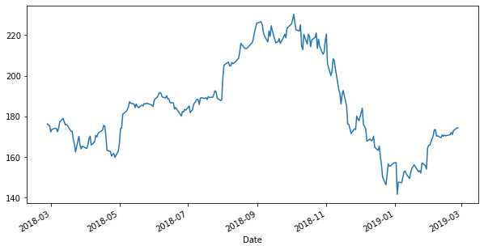

```python
close_price['AAPL'].plot(figsize=(10,5));
```

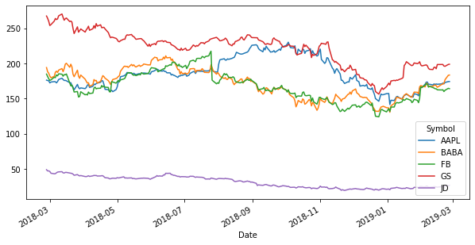

```python
close_price.plot(figsize=(10,5));
```

### 8.2 散点图

回到章首

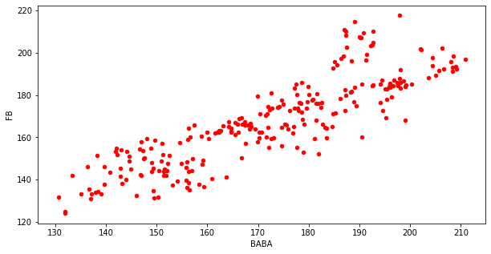

```python
close_price.plot(kind='scatter', x='BABA', y='FB', c='red', figsize=(10,5));
```

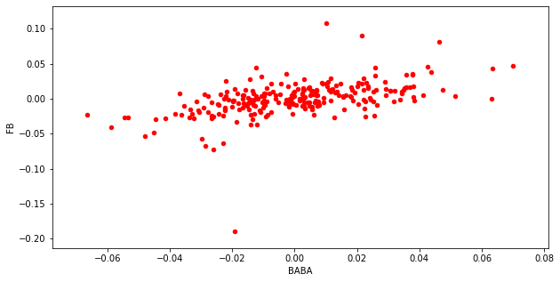

```python
close_price.pct_change().plot(kind='scatter', x='BABA', y='FB', c='red', figsize=(10,5));
```

### 8.3 柱状图

回到章首

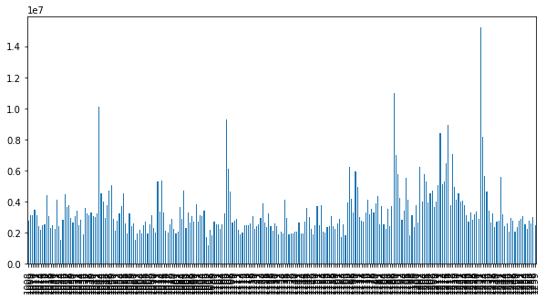

```python
idx = (data['Symbol'] == 'GS')
data.loc[idx,'Volume'].plot(kind='bar', figsize=(10,5), rot=90);
```

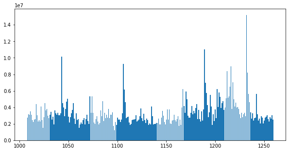

```python
import matplotlib.pyplot as plt
fig = plt.figure(figsize=(10,5))
plt.bar( data.loc[idx,'Volume'].index, data.loc[idx,'Volume'] );
```

### 8.4 箱形图

回到章首

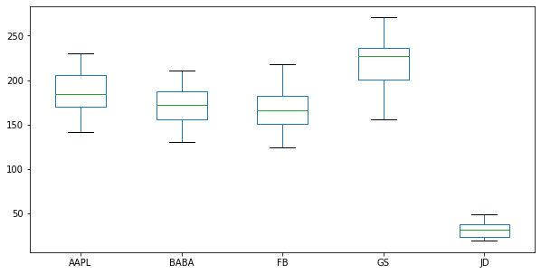

```python
close_price.plot(kind='box', figsize=(10,5));
```

### 8.5 直方图

回到章首

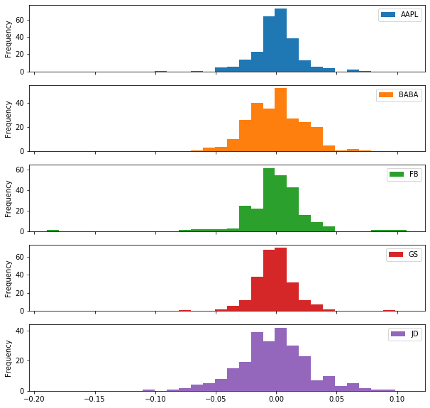

```python
close_price.pct_change().plot(kind='hist', bins=30, subplots=True, figsize=(10,10));
```

### 8.6 饼状图

回到章首

```python
volume = data.pivot( index='Date',
                     columns='Symbol',
                     values='Volume' )
volume.head(3).append(volume.tail(3))
```

| Symbol Date | AAPL | BABA | FB | GS | JD |
| --- | --- | --- | --- | --- | --- |
| 2018-02-26 | 38162200 | 19463100 | 17599700 | 2751400 | 9126900 |
| 2018-02-27 | 38928100 | 23218500 | 15849800 | 3140600 | 12688600 |
| 2018-02-28 | 37782100 | 19367600 | 18783000 | 3104300 | 12227800 |
| 2019-02-22 | 18913200 | 16175600 | 15858500 | 2626600 | 27113300 |
| 2019-02-25 | 21873400 | 22831800 | 18737100 | 3032200 | 29338500 |
| 2019-02-26 | 17006000 | 13857900 | 13645200 | 2498000 | 20264100 |

```python
market_cap = close_price * volume
market_cap.head(3).append(market_cap.tail(3))
```

| Symbol Date | AAPL | BABA | FB | GS | JD |
| --- | --- | --- | --- | --- | --- |
| 2018-02-26 | 6.727449e+09 | 3.779539e+09 | 3.254712e+09 | 7.362038e+08 | 4.453927e+08 |
| 2018-02-27 | 6.840227e+09 | 4.371115e+09 | 2.876105e+09 | 8.300275e+08 | 5.968718e+08 |
| 2018-02-28 | 6.628809e+09 | 3.605085e+09 | 3.349385e+09 | 8.073832e+08 | 5.765408e+08 |
| 2019-02-22 | 3.271416e+09 | 2.861787e+09 | 2.567333e+09 | 5.148136e+08 | 7.035902e+08 |
| 2019-02-25 | 3.811002e+09 | 4.183927e+09 | 3.084501e+09 | 6.023465e+08 | 7.683753e+08 |
| 2019-02-26 | 2.964656e+09 | 2.543479e+09 | 2.239587e+09 | 4.968522e+08 | 5.388224e+08 |

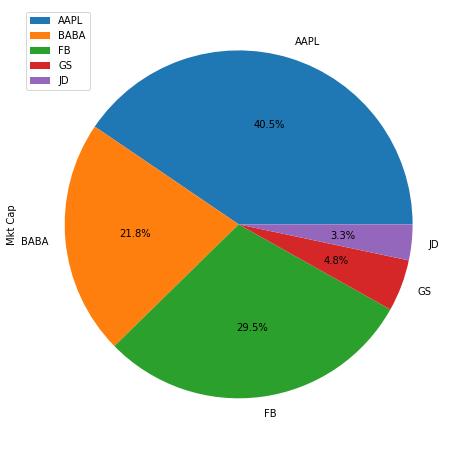

```python
market_cap.mean().to_frame(name='Mkt Cap').plot(kind='pie', y='Mkt Cap', autopct='%1.1f%%', figsize=(8,8))
```

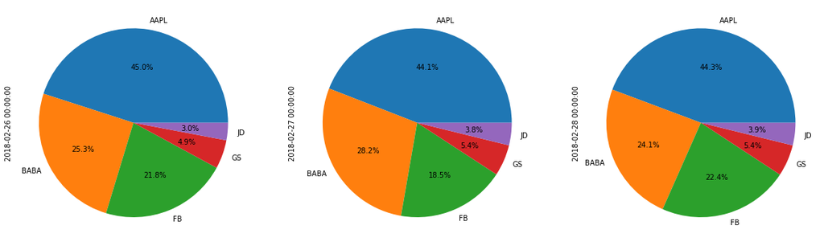

```python
df = market_cap.iloc[:3].stack('Symbol').unstack('Date')
df.plot(kind='pie', autopct='%1.1f%%', subplots=True, legend=False, figsize=(20,10));
```

# 9. 数据处理

回到目录

之前所有的数据都是经过预处理过而“干净”的，但在实际工作做数据一开始都是“杂乱”的。数据处理 (data munging) 包括两个大方面：

- 数据清洗 (data cleansing)：缺失值、离群值
- 数据转换 (data transforming)：编码、分组

数据清洗使用的是从 1993 年到 2018 年标普500 (SPY) 基金历史数据。

数据转换使用的是 `crosstab` 那节用的贷款数据。

首先读取两个数据起名为 SPY 和 loan。

```python
SPY = pd.read_csv('SPY.csv')
loan = pd.read_csv('Loan Data.csv')
```

### 9.1 数据清洗

回到章首

### 缺失值

```python
SPY.head(4).append(SPY.tail(4))
```

|  | Date | Adj_Close | Adj_Volume |
| --- | --- | --- | --- |
| 0 | 29/01/1993 | 28.223927 | 1003200 |
| 1 | 01/02/1993 | 28.424666 | 480500 |
| 2 | 02/02/1993 | NaN | 201300 |
| 3 | 03/02/1993 | 28.785997 | 529400 |
| 6345 | 11/04/2018 | 263.760000 | 91082611 |
| 6346 | 12/04/2018 | NaN | 68648611 |
| 6347 | 13/04/2018 | 2651.500000 | 85043940 |
| 6348 | 16/04/2018 | 267.330000 | 63354866 |

```python
SPY.describe()
```

|  | Adj_Close | Adj_Volume |
| --- | --- | --- |
| count | 6347.000000 | 6.349000e+03 |
| mean | 108.171940 | 8.439630e+07 |
| std | 64.541711 | 1.003193e+08 |
| min | 27.882638 | 5.200000e+03 |
| 25% | 73.212058 | 6.405600e+06 |
| 50% | 97.311651 | 5.469196e+07 |
| 75% | 124.149164 | 1.250593e+08 |
| max | 2651.500000 | 8.710263e+08 |

从上表 `count` 可看出 `Adj_Close` 列下的数据比 `Adj_Volume` 少两个。在 `SPY['Adj_close']` 用 `isnull()` 找出所有 NaN 的布尔值并加总，看是不是等于 2。

```python
SPY['Adj_Close'].isnull().sum()
```

```
2
```

```python
SPY['Adj_Volume'].isnull().sum()
```

```
0
```

对于缺失值，一般处理方式用两种，删除或填充，用以下对应的方法：

- `dropna()`：直接将 NaN 值对应的行或列删除，用 axis 参数来设置
- `fillna()`：填具体的值，或者插值

```python
SPY_dropna = SPY.dropna()
SPY_dropna.describe()
```

|  | Adj_Close | Adj_Volume |
| --- | --- | --- |
| count | 6347.000000 | 6.347000e+03 |
| mean | 108.171940 | 8.441205e+07 |
| std | 64.541711 | 1.003293e+08 |
| min | 27.882638 | 5.200000e+03 |
| 25% | 73.212058 | 6.405600e+06 |
| 50% | 97.311651 | 5.469196e+07 |
| 75% | 124.149164 | 1.250963e+08 |
| max | 2651.500000 | 8.710263e+08 |

```python
SPY_fill0 = SPY.fillna(0)
SPY_fill0.head(4).append(SPY_fill0.tail(4))
```

|  | Date | Adj_Close | Adj_Volume |
| --- | --- | --- | --- |
| 0 | 29/01/1993 | 28.223927 | 1003200 |
| 1 | 01/02/1993 | 28.424666 | 480500 |
| 2 | 02/02/1993 | 0.000000 | 201300 |
| 3 | 03/02/1993 | 28.785997 | 529400 |
| 6345 | 11/04/2018 | 263.760000 | 91082611 |
| 6346 | 12/04/2018 | 0.000000 | 68648611 |
| 6347 | 13/04/2018 | 2651.500000 | 85043940 |
| 6348 | 16/04/2018 | 267.330000 | 63354866 |

```python
SPY_bfill = SPY.fillna(method='bfill')
SPY_bfill.head(4).append(SPY_bfill.tail(4))
```

|  | Date | Adj_Close | Adj_Volume |
| --- | --- | --- | --- |
| 0 | 29/01/1993 | 28.223927 | 1003200 |
| 1 | 01/02/1993 | 28.424666 | 480500 |
| 2 | 02/02/1993 | 28.785997 | 201300 |
| 3 | 03/02/1993 | 28.785997 | 529400 |
| 6345 | 11/04/2018 | 263.760000 | 91082611 |
| 6346 | 12/04/2018 | 2651.500000 | 68648611 |
| 6347 | 13/04/2018 | 2651.500000 | 85043940 |
| 6348 | 16/04/2018 | 267.330000 | 63354866 |

```python
SPY_ffill = SPY.fillna(method='ffill')
SPY_ffill.head(4).append(SPY_ffill.tail(4))
```

|  | Date | Adj_Close | Adj_Volume |
| --- | --- | --- | --- |
| 0 | 29/01/1993 | 28.223927 | 1003200 |
| 1 | 01/02/1993 | 28.424666 | 480500 |
| 2 | 02/02/1993 | 28.424666 | 201300 |
| 3 | 03/02/1993 | 28.785997 | 529400 |
| 6345 | 11/04/2018 | 263.760000 | 91082611 |
| 6346 | 12/04/2018 | 263.760000 | 68648611 |
| 6347 | 13/04/2018 | 2651.500000 | 85043940 |
| 6348 | 16/04/2018 | 267.330000 | 63354866 |

### 离群值

检查 `SPY.describe()` 的结果，如果最大值和 75 分位数差个数量级，或者最小值和 25 分位数差个数量级，那么数据里极有可能有离群值 (outliers)。

```python
SPY.describe()
```

|  | Adj_Close | Adj_Volume |
| --- | --- | --- |
| count | 6347.000000 | 6.349000e+03 |
| mean | 108.171940 | 8.439630e+07 |
| std | 64.541711 | 1.003193e+08 |
| min | 27.882638 | 5.200000e+03 |
| 25% | 73.212058 | 6.405600e+06 |
| 50% | 97.311651 | 5.469196e+07 |
| 75% | 124.149164 | 1.250593e+08 |
| max | 2651.500000 | 8.710263e+08 |

在本例中，价格的最大值都比 75 分位数上的值大好多，那么至少最大值是一个离群值。

两个检测离群值更好的方法使用**箱形图**和**散点图**。

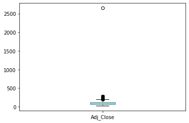

```python
SPY['Adj_Close'].plot(kind='box');
```

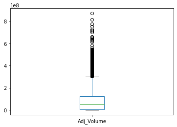

```python
SPY['Adj_Volume'].plot(kind='box');
```

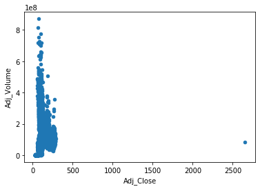

```python
SPY.plot(kind='scatter', x='Adj_Close', y='Adj_Volume');
```

对于离群值，只要数目占比很小，可以直接删除。

```python
mu = SPY['Adj_Close'].describe().loc['mean']
sigma = SPY['Adj_Close'].describe().loc['std']
lb = np.maximum(mu - 3*sigma, 0)
ub = mu + 3*sigma
(lb, ub)
```

```
(0.0, 301.79707288450953)
```

```python
bool_idx = ((SPY['Adj_Close'] <= lb) | (SPY['Adj_Close'] >= ub))
bool_idx.sum()
```

```
1
```

```python
SPY[bool_idx].index
```

```
Int64Index([6347], dtype='int64')
```

```python
SPY.drop( SPY[bool_idx].index, inplace=True )
SPY.describe()
```

|  | Adj_Close | Adj_Volume |
| --- | --- | --- |
| count | 6346.000000 | 6.348000e+03 |
| mean | 107.771164 | 8.439620e+07 |
| std | 56.095110 | 1.003272e+08 |
| min | 27.882638 | 5.200000e+03 |
| 25% | 73.195260 | 6.398825e+06 |
| 50% | 97.307411 | 5.459568e+07 |
| 75% | 124.144102 | 1.250778e+08 |
| max | 285.438268 | 8.710263e+08 |

### 9.2 数据转换

回到章首

### 字符型变量编码

计算机无法识别字符型变量，需要通过编码 (encoding) 转成数值型。拿下面贷款评级 `loan_grade` 来举例。

```python
loan.head(3).append(loan.tail(2))
```

|  | person_age | person_income | person_home_ownership | person_emp_length | loan_intent | loan_grade | loan_amnt | loan_int_rate | loan_status | loan_percent_income | cb_person_default_on_file | cb_person_cred_hist_length |
| --- | --- | --- | --- | --- | --- | --- | --- | --- | --- | --- | --- | --- |
| 0 | 22 | 59000 | RENT | 123.0 | PERSONAL | D | 35000 | 16.02 | 1 | 0.59 | Y | 3 |
| 1 | 21 | 9600 | OWN | 5.0 | EDUCATION | B | 1000 | 11.14 | 0 | 0.10 | N | 2 |
| 2 | 25 | 9600 | MORTGAGE | 1.0 | MEDICAL | C | 5500 | 12.87 | 1 | 0.57 | N | 3 |
| 32579 | 56 | 150000 | MORTGAGE | 5.0 | PERSONAL | B | 15000 | 11.48 | 0 | 0.10 | N | 26 |
| 32580 | 66 | 42000 | RENT | 2.0 | MEDICAL | B | 6475 | 9.99 | 0 | 0.15 | N | 30 |

```python
loan['loan_grade'].unique()
```

```
array(['D', 'B', 'C', 'A', 'E', 'F', 'G'], dtype=object)
```

```python
pd.get_dummies( loan['loan_grade'], prefix='loan_grade' )
```

|  | loan_grade_A | loan_grade_B | loan_grade_C | loan_grade_D | loan_grade_E | loan_grade_F | loan_grade_G |
| --- | --- | --- | --- | --- | --- | --- | --- |
| 0 | 0 | 0 | 0 | 1 | 0 | 0 | 0 |
| 1 | 0 | 1 | 0 | 0 | 0 | 0 | 0 |
| 2 | 0 | 0 | 1 | 0 | 0 | 0 | 0 |
| 3 | 0 | 0 | 1 | 0 | 0 | 0 | 0 |
| 4 | 0 | 0 | 1 | 0 | 0 | 0 | 0 |
| ... | ... | ... | ... | ... | ... | ... | ... |
| 32576 | 0 | 0 | 1 | 0 | 0 | 0 | 0 |
| 32577 | 1 | 0 | 0 | 0 | 0 | 0 | 0 |
| 32578 | 0 | 1 | 0 | 0 | 0 | 0 | 0 |
| 32579 | 0 | 1 | 0 | 0 | 0 | 0 | 0 |
| 32580 | 0 | 1 | 0 | 0 | 0 | 0 | 0 |

32581 rows × 7 columns

```python
pd.get_dummies( loan['loan_grade'], prefix='loan_grade', drop_first=True )
```

|  | loan_grade_B | loan_grade_C | loan_grade_D | loan_grade_E | loan_grade_F | loan_grade_G |
| --- | --- | --- | --- | --- | --- | --- |
| 0 | 0 | 0 | 1 | 0 | 0 | 0 |
| 1 | 1 | 0 | 0 | 0 | 0 | 0 |
| 2 | 0 | 1 | 0 | 0 | 0 | 0 |
| 3 | 0 | 1 | 0 | 0 | 0 | 0 |
| 4 | 0 | 1 | 0 | 0 | 0 | 0 |
| ... | ... | ... | ... | ... | ... | ... |
| 32576 | 0 | 1 | 0 | 0 | 0 | 0 |
| 32577 | 0 | 0 | 0 | 0 | 0 | 0 |
| 32578 | 1 | 0 | 0 | 0 | 0 | 0 |
| 32579 | 1 | 0 | 0 | 0 | 0 | 0 |
| 32580 | 1 | 0 | 0 | 0 | 0 | 0 |

32581 rows × 6 columns

### 数值型变量分组

拿工龄 `person_emp_length` 和贷款状态 `loan_status` 来做交叉表。

```python
pd.crosstab( index=loan['person_emp_length'],
             columns=loan['loan_status'],
             normalize=True ).style.format("{:.2%}")
```

| loan_status person_emp_length | 0 | 1 |
| --- | --- | --- |
| 0.0 | 9.34% | 3.62% |
| 1.0 | 6.66% | 2.54% |
| 2.0 | 9.03% | 3.11% |
| 3.0 | 8.71% | 2.20% |
| 4.0 | 7.15% | 1.93% |
| 5.0 | 7.57% | 1.73% |
| 6.0 | 6.84% | 1.58% |
| 7.0 | 5.63% | 1.30% |
| 8.0 | 4.44% | 0.89% |
| 9.0 | 3.54% | 0.77% |
| 10.0 | 1.82% | 0.38% |
| 11.0 | 1.91% | 0.43% |
| 12.0 | 1.53% | 0.28% |
| 13.0 | 1.18% | 0.16% |
| 14.0 | 0.88% | 0.18% |
| 15.0 | 0.62% | 0.14% |
| 16.0 | 0.46% | 0.06% |
| 17.0 | 0.34% | 0.07% |
| 18.0 | 0.29% | 0.03% |
| 19.0 | 0.17% | 0.03% |
| 20.0 | 0.09% | 0.04% |
| 21.0 | 0.09% | 0.03% |
| 22.0 | 0.05% | 0.01% |
| 23.0 | 0.02% | 0.01% |
| 24.0 | 0.02% | 0.01% |
| 25.0 | 0.03% | 0.00% |
| 26.0 | 0.02% | 0.00% |
| 27.0 | 0.01% | 0.00% |
| 28.0 | 0.01% | 0.00% |
| 29.0 | 0.00% | 0.00% |
| 30.0 | 0.00% | 0.00% |
| 31.0 | 0.01% | 0.00% |
| 34.0 | 0.00% | 0.00% |
| 38.0 | 0.00% | 0.00% |
| 41.0 | 0.00% | 0.00% |
| 123.0 | 0.00% | 0.00% |

由于工龄是连续数值，如果按每个唯一值来分类的话，产出的信息毫无价值。这时需要做分箱操作，用 `qcut()` 函数将工龄按差不多数目分成 n 份。

```python
bins = pd.qcut(loan['person_emp_length'], 4)
bins
```

```
0         (7.0, 123.0]
1           (4.0, 7.0]
2        (-0.001, 2.0]
3           (2.0, 4.0]
4         (7.0, 123.0]
             ...
32576    (-0.001, 2.0]
32577       (2.0, 4.0]
32578       (2.0, 4.0]
32579       (4.0, 7.0]
32580    (-0.001, 2.0]
Name: person_emp_length, Length: 32581, dtype: category
Categories (4, interval[float64]): [(-0.001, 2.0] < (2.0, 4.0] < (4.0, 7.0] < (7.0, 123.0]]
```

注意上面的分割点为 -0.001, 2, 4, 7, 123 就是下面用 `describe()` 函数产出的最小值、25-50-75 分位数和最大值。

```python
loan['person_emp_length'].describe()
```

```
count    31686.000000
mean         4.789686
std          4.142630
min          0.000000
25%          2.000000
50%          4.000000
75%          7.000000
max        123.000000
Name: person_emp_length, dtype: float64
```

```python
bins.value_counts()
```

```
(-0.001, 2.0]    10869
(4.0, 7.0]        7808
(7.0, 123.0]      6679
(2.0, 4.0]        6330
Name: person_emp_length, dtype: int64
```

```python
loan['person_emp_bin'] = bins
loan.head(3).append(loan.tail(2))
```

|  | person_age | person_income | person_home_ownership | person_emp_length | loan_intent | loan_grade | loan_amnt | loan_int_rate | loan_status | loan_percent_income | cb_person_default_on_file | cb_person_cred_hist_length | person_emp_bin |
| --- | --- | --- | --- | --- | --- | --- | --- | --- | --- | --- | --- | --- | --- |
| 0 | 22 | 59000 | RENT | 123.0 | PERSONAL | D | 35000 | 16.02 | 1 | 0.59 | Y | 3 | (7.0, 123.0] |
| 1 | 21 | 9600 | OWN | 5.0 | EDUCATION | B | 1000 | 11.14 | 0 | 0.10 | N | 2 | (4.0, 7.0] |
| 2 | 25 | 9600 | MORTGAGE | 1.0 | MEDICAL | C | 5500 | 12.87 | 1 | 0.57 | N | 3 | (-0.001, 2.0] |
| 32579 | 56 | 150000 | MORTGAGE | 5.0 | PERSONAL | B | 15000 | 11.48 | 0 | 0.10 | N | 26 | (4.0, 7.0] |
| 32580 | 66 | 42000 | RENT | 2.0 | MEDICAL | B | 6475 | 9.99 | 0 | 0.15 | N | 30 | (-0.001, 2.0] |

```python
pd.crosstab( index=loan['person_emp_bin'],
             columns=loan['loan_status'],
             normalize=True ).style.format("{:.2%}")
```

| loan_status person_emp_bin | 0 | 1 |
| --- | --- | --- |
| (-0.001, 2.0] | 25.02% | 9.28% |
| (2.0, 4.0] | 15.86% | 4.12% |
| (4.0, 7.0] | 20.03% | 4.61% |
| (7.0, 123.0] | 17.54% | 3.53% |

```python
pd.crosstab( index=loan['person_emp_bin'],
             columns=loan['loan_status'],
             normalize='columns' ).style.format("{:.2%}")
```

| loan_status person_emp_bin | 0 | 1 |
| --- | --- | --- |
| (-0.001, 2.0] | 31.89% | 43.07% |
| (2.0, 4.0] | 20.21% | 19.13% |
| (4.0, 7.0] | 25.53% | 21.39% |
| (7.0, 123.0] | 22.36% | 16.41% |

```python
pd.crosstab( index=loan['person_emp_bin'],
             columns=loan['loan_status'],
             normalize='index' ).style.format("{:.2%}")
```

| loan_status person_emp_bin | 0 | 1 |
| --- | --- | --- |
| (-0.001, 2.0] | 72.95% | 27.05% |
| (2.0, 4.0] | 79.37% | 20.63% |
| (4.0, 7.0] | 81.30% | 18.70% |
| (7.0, 123.0] | 83.23% | 16.77% |

深挖一下，`loan` 里面包含 32581 条数据，但是 `loan['person_emp_length'].describe()` 的 `count` 行中看到 31686 条数据，相差的 895 条数据应该都是 NaN 值。用 `isnull()` 加 `sum()` 检验一下。

```python
loan['person_emp_bin'].isnull().sum()
```

```
895
```

现在问题来了，这 895 个 NaN 该怎么办呢？全部删掉？用 0 替代？还是把 NaN 也当成一个类别？

## Cheatsheet

[figure not shown]